# Main Project: Robust Data Modeling with Ensembling and Tuning Techniques

### 3.2.2 Education of Employee vs Case Status

The education level of the employee is analyzed against visa case status because educational qualifications may be relevant to the applicant's employment profile.

```
Percentage Distribution: education_of_employee vs case_status
```

| case_status education_of_employee | Certified | Denied |
| --- | --- | --- |
| Bachelor's | 62.21 | 37.79 |
| Doctorate | 87.23 | 12.77 |
| High School | 34.04 | 65.96 |
| Master's | 78.63 | 21.37 |

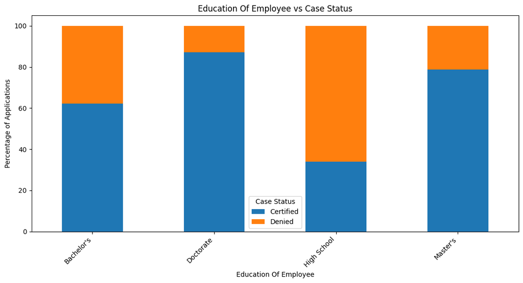

```python
education_status = categorical_target_analysis(
    df,
    'education_of_employee',
    'case_status'
)
```

**Observation:**

The distribution of Certified and Denied cases differs across education categories.

This relationship suggests that education level may be an important predictor of visa case status and should therefore be considered during model development.

### 3.2.3 Job Experience vs Case Status

The relationship between previous job experience and visa case status is analyzed to determine whether experienced applicants have a different distribution of certification outcomes.

```
Percentage Distribution: has_job_experience vs case_status
```

| case_status has_job_experience | Certified | Denied |
| --- | --- | --- |
| N | 56.13 | 43.87 |
| Y | 74.48 | 25.52 |

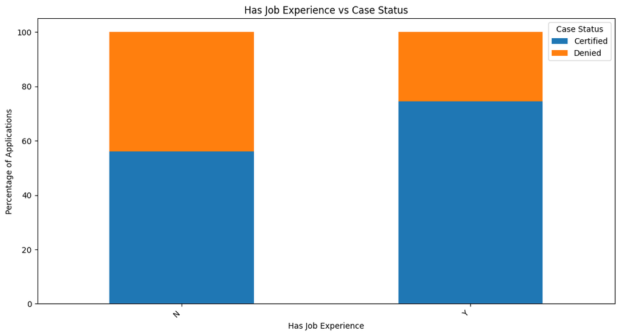

```python
experience_status = categorical_target_analysis(
    df,
    'has_job_experience',
    'case_status'
)
```

**Observation:**

The percentage distribution of Certified and Denied cases is compared between applicants with and without previous job experience.

This variable may therefore contribute useful information when predicting the visa case outcome.

### 3.2.4 Job Training Requirement vs Case Status

The requirement for job training is compared with visa case status to determine whether applicants requiring training exhibit a different certification pattern.

```
Percentage Distribution: requires_job_training vs case_status
```

| case_status requires_job_training | Certified | Denied |
| --- | --- | --- |
| N | 66.65 | 33.35 |
| Y | 67.88 | 32.12 |

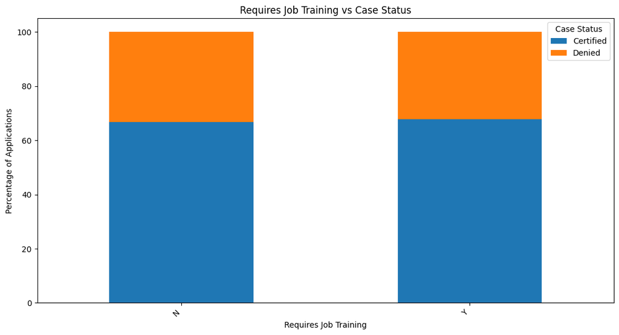

```python
training_status = categorical_target_analysis(
    df,
    'requires_job_training',
    'case_status'
)
```

### 3.2.5 Region of Employment vs Case Status

The intended region of employment is analyzed against visa case status to identify geographical differences in certification outcomes.

```
Percentage Distribution: region_of_employment vs case_status
```

| case_status region_of_employment | Certified | Denied |
| --- | --- | --- |
| Island | 60.27 | 39.73 |
| Midwest | 75.53 | 24.47 |
| Northeast | 62.90 | 37.10 |
| South | 70.02 | 29.98 |
| West | 62.25 | 37.75 |

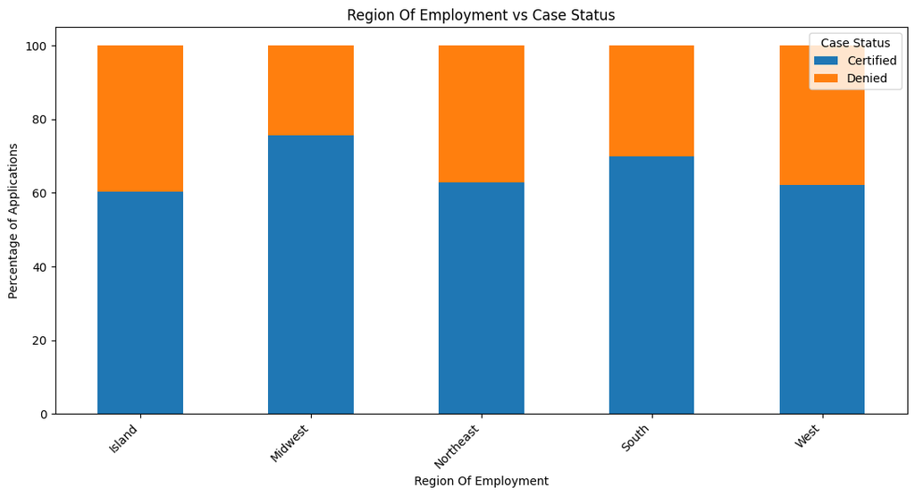

```python
region_status = categorical_target_analysis(
    df,
    'region_of_employment',
    'case_status'
)
```

| case_status region_of_employment | Certified | Denied |
| --- | --- | --- |
| Island | 60.27 | 39.73 |
| Midwest | 75.53 | 24.47 |
| Northeast | 62.90 | 37.10 |
| South | 70.02 | 29.98 |
| West | 62.25 | 37.75 |

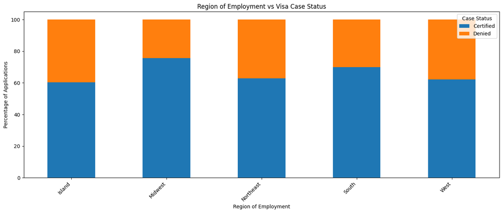

```python
region_status = pd.crosstab(
    df['region_of_employment'],
    df['case_status'],
    normalize='index'
) * 100

display(region_status.round(2))

region_status.plot(
    kind='bar',
    stacked=True,
    figsize=(14, 6)
)

plt.title('Region of Employment vs Visa Case Status')
plt.xlabel('Region of Employment')
plt.ylabel('Percentage of Applications')
plt.xticks(rotation=45, ha='right')
plt.legend(title='Case Status')

plt.tight_layout()
plt.show()
```

### 3.2.6 Unit of Wage vs Case Status

The unit in which prevailing wage is reported is analyzed against visa case status. This analysis is useful because wage values expressed in different units should not be directly compared without considering their measurement unit.

```
Percentage Distribution: unit_of_wage vs case_status
```

| case_status unit_of_wage | Certified | Denied |
| --- | --- | --- |
| Hour | 34.63 | 65.37 |
| Month | 61.80 | 38.20 |
| Week | 62.13 | 37.87 |
| Year | 69.89 | 30.11 |

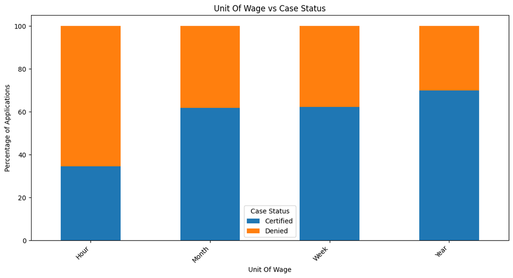

```python
wage_unit_status = categorical_target_analysis(
    df,
    'unit_of_wage',
    'case_status'
)
```

### 3.2.7 Full-Time Position vs Case Status

The relationship between the position being full-time and visa case status is examined to identify whether employment type is associated with certification outcomes.

```
Percentage Distribution: full_time_position vs case_status
```

| case_status full_time_position | Certified | Denied |
| --- | --- | --- |
| N | 68.53 | 31.47 |
| Y | 66.58 | 33.42 |

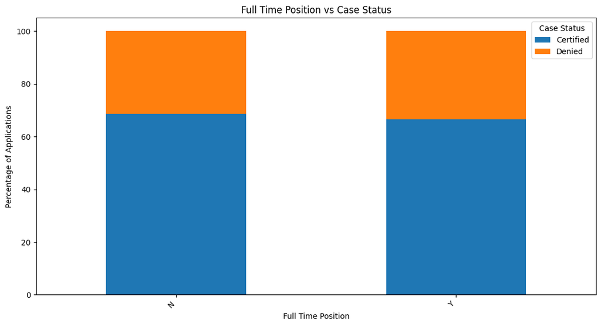

```python
fulltime_status = categorical_target_analysis(
    df,
    'full_time_position',
    'case_status'
)
```

## 3.3 Multivariate Business Relationships

## 3.3 Multivariate Business Relationships

### 3.3.1 Education, Job Experience and Case Status

Education and previous job experience are jointly analyzed to determine whether certification patterns differ across combinations of applicant qualifications.

```python
education_experience = pd.crosstab(
    [
        df['education_of_employee'],
        df['has_job_experience']
    ],
    df['case_status'],
    normalize='index'
) * 100

education_experience = education_experience.round(2)

display(education_experience)
```

| education_of_employee | case_status has_job_experience | Certified | Denied |
| --- | --- | --- | --- |
| Bachelor's | N | 51.31 | 48.69 |
|  | Y | 70.27 | 29.73 |
| Doctorate | N | 80.13 | 19.87 |
|  | Y | 92.57 | 7.43 |
| High School | N | 31.66 | 68.34 |
|  | Y | 35.67 | 64.33 |
| Master's | N | 64.29 | 35.71 |
|  | Y | 88.78 | 11.22 |

#### Visualization:

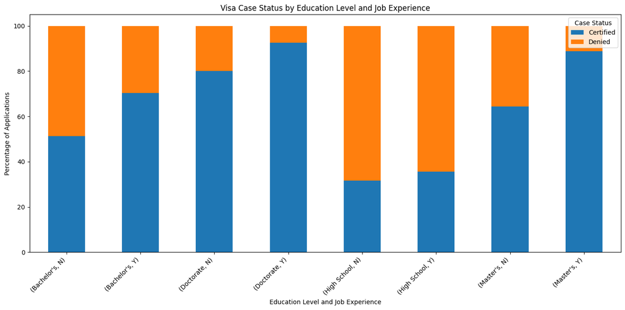

```python
education_experience.plot(
    kind='bar',
    stacked=True,
    figsize=(14, 7)
)

plt.title(
    'Visa Case Status by Education Level and Job Experience'
)
plt.xlabel('Education Level and Job Experience')
plt.ylabel('Percentage of Applications')
plt.xticks(rotation=45, ha='right')
plt.legend(title='Case Status')

plt.tight_layout()
plt.show()
```

### 3.3.2 Continent + Education + Case Status

```python
continent_education = pd.crosstab(
    [
        df['continent'],
        df['education_of_employee']
    ],
    df['case_status'],
    normalize='index'
) * 100

display(continent_education.round(2))
```

| continent | case_status education_of_employee | Certified | Denied |
| --- | --- | --- | --- |
| Africa | Bachelor's | 56.64 | 43.36 |
|  | Doctorate | 79.63 | 20.37 |
|  | High School | 34.85 | 65.15 |
|  | Master's | 86.81 | 13.19 |
| Asia | Bachelor's | 61.48 | 38.52 |
|  | Doctorate | 84.51 | 15.49 |
|  | High School | 29.52 | 70.48 |
|  | Master's | 79.46 | 20.54 |
| Europe | Bachelor's | 80.06 | 19.94 |
|  | Doctorate | 93.14 | 6.86 |
|  | High School | 33.06 | 66.94 |
|  | Master's | 88.15 | 11.85 |
| North America | Bachelor's | 52.33 | 47.67 |
|  | Doctorate | 80.23 | 19.77 |
|  | High School | 52.37 | 47.63 |
|  | Master's | 69.53 | 30.47 |
| Oceania | Bachelor's | 57.58 | 42.42 |
|  | Doctorate | 86.36 | 13.64 |
|  | High School | 52.78 | 47.22 |
|  | Master's | 67.65 | 32.35 |
| South America | Bachelor's | 48.05 | 51.95 |
|  | Doctorate | 84.27 | 15.73 |
|  | High School | 54.01 | 45.99 |
|  | Master's | 62.80 | 37.20 |

### 3.3.3 Job Experience + Training + Case Status

```python
experience_training = pd.crosstab(
    [
        df['has_job_experience'],
        df['requires_job_training']
    ],
    df['case_status'],
    normalize='index'
) * 100

display(experience_training.round(2))
```

| has_job_experience | case_status requires_job_training | Certified | Denied |
| --- | --- | --- | --- |
| N | N | 54.87 | 45.13 |
|  | Y | 62.84 | 37.16 |
| Y | N | 74.46 | 25.54 |
|  | Y | 74.62 | 25.38 |

#### Visualization:

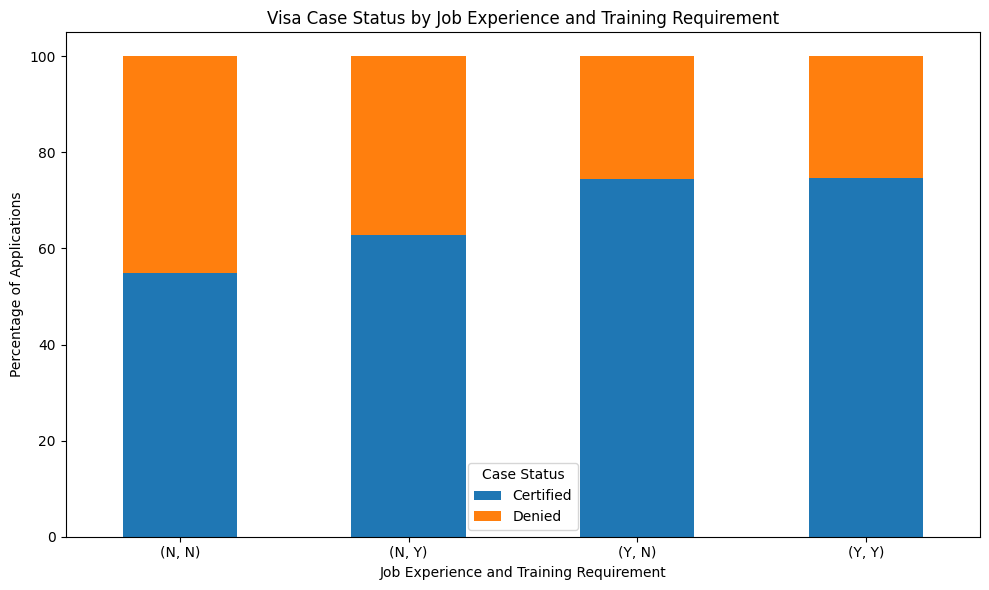

```python
experience_training.plot(
    kind='bar',
    stacked=True,
    figsize=(10, 6)
)

plt.title(
    'Visa Case Status by Job Experience and Training Requirement'
)
plt.xlabel('Job Experience and Training Requirement')
plt.ylabel('Percentage of Applications')
plt.xticks(rotation=0)
plt.legend(title='Case Status')

plt.tight_layout()
plt.show()
```

### 3.4 Correlation Analysis of Numerical Variables

Correlation analysis is used to understand the linear relationships among the numerical variables in the dataset.

```python
numeric_cols = [
    'no_of_employees',
    'yr_of_estab',
    'prevailing_wage'
]

correlation_matrix = df[numeric_cols].corr()

display(correlation_matrix.round(2))
```

|  | no_of_employees | yr_of_estab | prevailing_wage |
| --- | --- | --- | --- |
| no_of_employees | 1.00 | -0.02 | -0.01 |
| yr_of_estab | -0.02 | 1.00 | 0.01 |
| prevailing_wage | -0.01 | 0.01 | 1.00 |

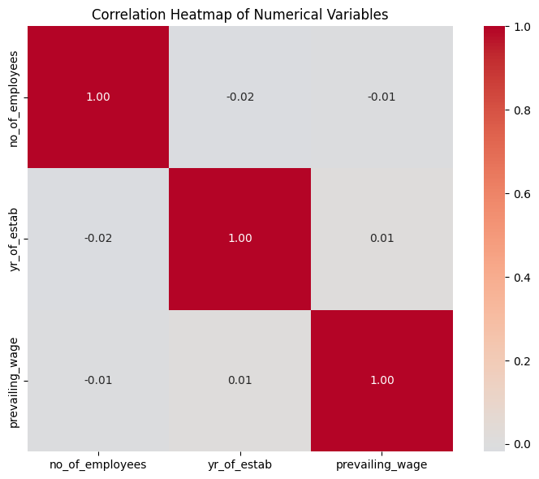

```python
plt.figure(figsize=(8, 6))

sns.heatmap(
    correlation_matrix,
    annot=True,
    fmt='.2f',
    cmap='coolwarm',
    center=0,
    square=True
)

plt.title('Correlation Heatmap of Numerical Variables')

plt.tight_layout()
plt.show()
```

## 3.5 Automated Comparison of Certification Rate

```python
def certification_rate(data, feature, target='case_status'):

    summary = (
        data.groupby(feature)[target]
        .value_counts(normalize=True)
        .unstack(fill_value=0)
        * 100
    )

    summary = summary.round(2)

    if 'Certified' in summary.columns:
        summary = summary.sort_values(
            by='Certified',
            ascending=False
        )

    return summary
```

```python
categorical_features_for_analysis = [
    'continent',
    'education_of_employee',
    'has_job_experience',
    'requires_job_training',
    'region_of_employment',
    'unit_of_wage',
    'full_time_position'
]

for feature in categorical_features_for_analysis:
    print(f"\n{'='*70}")
    print(f"Certification Rate by {feature}")
    display(certification_rate(df, feature))
```

```
======================================================================
Certification Rate by continent
```

| case_status continent | Certified | Denied |
| --- | --- | --- |
| Europe | 79.23 | 20.77 |
| Africa | 72.05 | 27.95 |
| Asia | 65.31 | 34.69 |
| Oceania | 63.54 | 36.46 |
| North America | 61.88 | 38.12 |
| South America | 57.86 | 42.14 |

```
======================================================================
Certification Rate by education_of_employee
```

| case_status education_of_employee | Certified | Denied |
| --- | --- | --- |
| Doctorate | 87.23 | 12.77 |
| Master's | 78.63 | 21.37 |
| Bachelor's | 62.21 | 37.79 |
| High School | 34.04 | 65.96 |

```
======================================================================
Certification Rate by has_job_experience
```

| case_status has_job_experience | Certified | Denied |
| --- | --- | --- |
| Y | 74.48 | 25.52 |
| N | 56.13 | 43.87 |

```
======================================================================
Certification Rate by requires_job_training
```

| case_status requires_job_training | Certified | Denied |
| --- | --- | --- |
| Y | 67.88 | 32.12 |
| N | 66.65 | 33.35 |

```
======================================================================
Certification Rate by region_of_employment
```

| case_status region_of_employment | Certified | Denied |
| --- | --- | --- |
| Midwest | 75.53 | 24.47 |
| South | 70.02 | 29.98 |
| Northeast | 62.90 | 37.10 |
| West | 62.25 | 37.75 |
| Island | 60.27 | 39.73 |

```
======================================================================
Certification Rate by unit_of_wage
```

| case_status unit_of_wage | Certified | Denied |
| --- | --- | --- |
| Year | 69.89 | 30.11 |
| Week | 62.13 | 37.87 |
| Month | 61.80 | 38.20 |
| Hour | 34.63 | 65.37 |

```
======================================================================
Certification Rate by full_time_position
```

| case_status full_time_position | Certified | Denied |
| --- | --- | --- |
| N | 68.53 | 31.47 |
| Y | 66.58 | 33.42 |

## 3.6 Key Bivariate Insights

### 7. Modeling Implication

The observed relationships suggest that employee characteristics, employer characteristics, wage information, and employment conditions may contain predictive information about visa case status. These variables will therefore be evaluated systematically using classification models in the subsequent modeling stages.

# 4. Multivariate / Relationship Analysis

## 4.1 Education, Job Experience and Case Status

Education level and previous job experience are jointly analyzed to determine whether visa certification patterns differ across combinations of applicant qualifications.

This analysis helps identify whether applicant characteristics provide stronger insights when considered together rather than independently.

```python
# Percentage distribution of case status
education_experience = pd.crosstab(
    [df['education_of_employee'], df['has_job_experience']],
    df['case_status'],
    normalize='index'
) * 100

education_experience = education_experience.round(2)

display(education_experience)
```

| education_of_employee | case_status has_job_experience | Certified | Denied |
| --- | --- | --- | --- |
| Bachelor's | N | 51.31 | 48.69 |
|  | Y | 70.27 | 29.73 |
| Doctorate | N | 80.13 | 19.87 |
|  | Y | 92.57 | 7.43 |
| High School | N | 31.66 | 68.34 |
|  | Y | 35.67 | 64.33 |
| Master's | N | 64.29 | 35.71 |
|  | Y | 88.78 | 11.22 |

#### Visualization

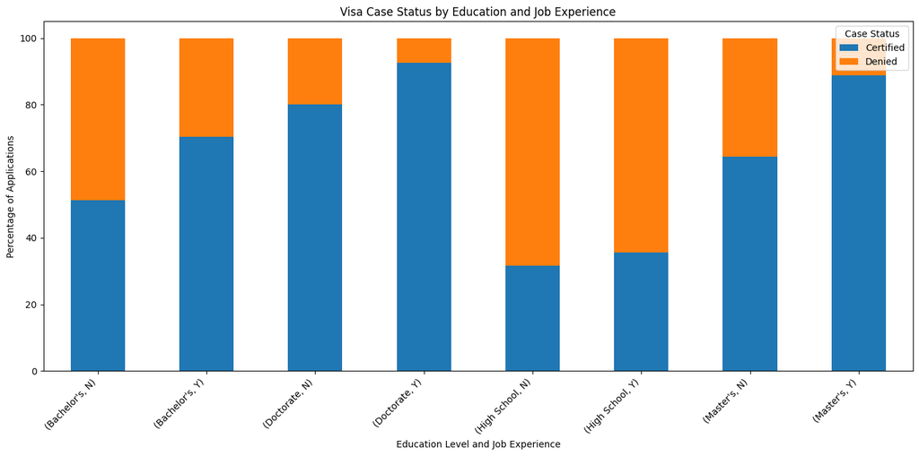

```python
education_experience.plot(
    kind='bar',
    stacked=True,
    figsize=(14, 7)
)

plt.title('Visa Case Status by Education and Job Experience')
plt.xlabel('Education Level and Job Experience')
plt.ylabel('Percentage of Applications')
plt.xticks(rotation=45, ha='right')
plt.legend(title='Case Status')

plt.tight_layout()
plt.show()
```

**Observation:**

The combined analysis of education level and job experience shows how certification and denial rates vary across different applicant profiles.

This suggests that education and prior job experience may jointly provide useful information for predicting visa case status.

## 4.2 Education, Job Training Requirement and Case Status

The relationship between employee education, job-training requirements, and visa case status is examined to understand whether certification patterns differ across combinations of educational qualifications and training requirements.

```python
education_training = pd.crosstab(
    [
        df['education_of_employee'],
        df['requires_job_training']
    ],
    df['case_status'],
    normalize='index'
) * 100

education_training = education_training.round(2)

display(education_training)
```

| education_of_employee | case_status requires_job_training | Certified | Denied |
| --- | --- | --- | --- |
| Bachelor's | N | 61.28 | 38.72 |
|  | Y | 68.88 | 31.12 |
| Doctorate | N | 88.36 | 11.64 |
|  | Y | 82.37 | 17.63 |
| High School | N | 33.98 | 66.02 |
|  | Y | 34.42 | 65.58 |
| Master's | N | 78.85 | 21.15 |
|  | Y | 76.30 | 23.70 |

#### Visualization

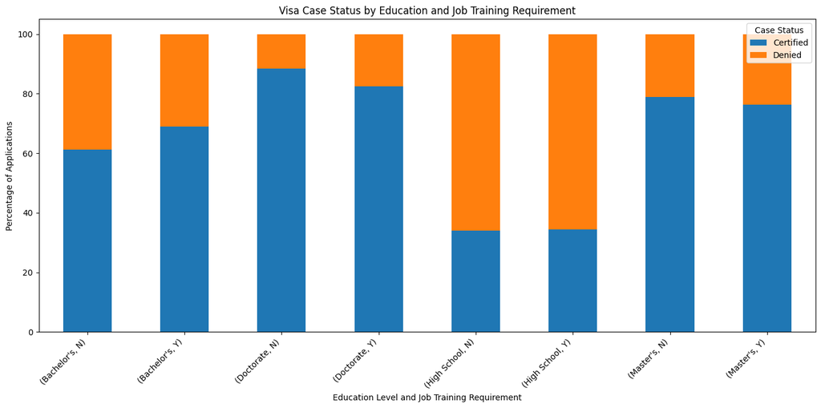

```python
education_training.plot(
    kind='bar',
    stacked=True,
    figsize=(14, 7)
)

plt.title('Visa Case Status by Education and Job Training Requirement')
plt.xlabel('Education Level and Job Training Requirement')
plt.ylabel('Percentage of Applications')
plt.xticks(rotation=45, ha='right')
plt.legend(title='Case Status')

plt.tight_layout()
plt.show()
```

**Observation:**

The results suggest that the requirement for job training may provide additional information when considered together with the employee's education level.

## 4.3 Continent, Education and Case Status

The continent of the employee and education level are analyzed jointly to identify differences in visa outcomes across geographical and educational profiles.

```python
continent_education = pd.crosstab(
    [
        df['continent'],
        df['education_of_employee']
    ],
    df['case_status'],
    normalize='index'
) * 100

continent_education = continent_education.round(2)

display(continent_education)
```

| continent | case_status education_of_employee | Certified | Denied |
| --- | --- | --- | --- |
| Africa | Bachelor's | 56.64 | 43.36 |
|  | Doctorate | 79.63 | 20.37 |
|  | High School | 34.85 | 65.15 |
|  | Master's | 86.81 | 13.19 |
| Asia | Bachelor's | 61.48 | 38.52 |
|  | Doctorate | 84.51 | 15.49 |
|  | High School | 29.52 | 70.48 |
|  | Master's | 79.46 | 20.54 |
| Europe | Bachelor's | 80.06 | 19.94 |
|  | Doctorate | 93.14 | 6.86 |
|  | High School | 33.06 | 66.94 |
|  | Master's | 88.15 | 11.85 |
| North America | Bachelor's | 52.33 | 47.67 |
|  | Doctorate | 80.23 | 19.77 |
|  | High School | 52.37 | 47.63 |
|  | Master's | 69.53 | 30.47 |
| Oceania | Bachelor's | 57.58 | 42.42 |
|  | Doctorate | 86.36 | 13.64 |
|  | High School | 52.78 | 47.22 |
|  | Master's | 67.65 | 32.35 |
| South America | Bachelor's | 48.05 | 51.95 |
|  | Doctorate | 84.27 | 15.73 |
|  | High School | 54.01 | 45.99 |
|  | Master's | 62.80 | 37.20 |

#### Heatmap

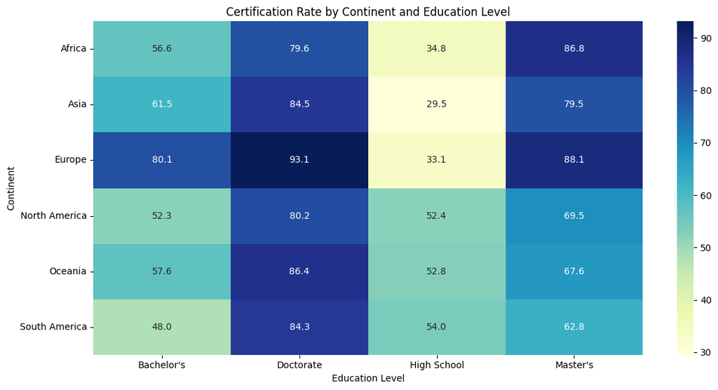

```python
# Certification percentage by continent and education
certified_rate = (
    df.assign(
        certified=(df['case_status'] == 'Certified').astype(int)
    )
    .pivot_table(
        index='continent',
        columns='education_of_employee',
        values='certified',
        aggfunc='mean'
    ) * 100
)

plt.figure(figsize=(12, 6))

sns.heatmap(
    certified_rate,
    annot=True,
    fmt='.1f',
    cmap='YlGnBu'
)

plt.title(
    'Certification Rate by Continent and Education Level'
)
plt.xlabel('Education Level')
plt.ylabel('Continent')

plt.tight_layout()
plt.show()
```

**Observation:**

The heatmap compares certification rates across combinations of continent and education level.

These patterns should be interpreted as associations rather than causal relationships.

## 4.4 Region of Employment, Education and Case Status

The intended region of employment and employee education level are analyzed jointly to determine whether certification patterns vary across employment regions and educational profiles.

```python
region_education = pd.crosstab(
    [
        df['region_of_employment'],
        df['education_of_employee']
    ],
    df['case_status'],
    normalize='index'
) * 100

display(region_education.round(2))
```

| region_of_employment | case_status education_of_employee | Certified | Denied |
| --- | --- | --- | --- |
| Island | Bachelor's | 59.69 | 40.31 |
|  | Doctorate | 88.00 | 12.00 |
|  | High School | 30.00 | 70.00 |
|  | Master's | 67.70 | 32.30 |
| Midwest | Bachelor's | 73.31 | 26.69 |
|  | Doctorate | 90.62 | 9.38 |
|  | High School | 40.49 | 59.51 |
|  | Master's | 87.95 | 12.05 |
| Northeast | Bachelor's | 56.75 | 43.25 |
|  | Doctorate | 86.43 | 13.57 |
|  | High School | 29.06 | 70.94 |
|  | Master's | 74.82 | 25.18 |
| South | Bachelor's | 66.27 | 33.73 |
|  | Doctorate | 90.02 | 9.98 |
|  | High School | 38.01 | 61.99 |
|  | Master's | 81.89 | 18.11 |
| West | Bachelor's | 58.56 | 41.44 |
|  | Doctorate | 84.59 | 15.41 |
|  | High School | 29.30 | 70.70 |
|  | Master's | 71.83 | 28.17 |

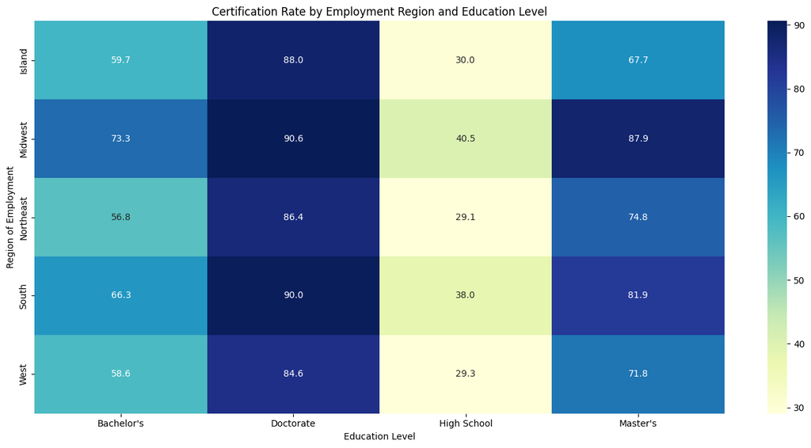

```python
region_education_certified = (
    df.assign(
        certified=(df['case_status'] == 'Certified').astype(int)
    )
    .pivot_table(
        index='region_of_employment',
        columns='education_of_employee',
        values='certified',
        aggfunc='mean'
    ) * 100
)

plt.figure(figsize=(14, 7))

sns.heatmap(
    region_education_certified,
    annot=True,
    fmt='.1f',
    cmap='YlGnBu'
)

plt.title(
    'Certification Rate by Employment Region and Education Level'
)
plt.xlabel('Education Level')
plt.ylabel('Region of Employment')

plt.tight_layout()
plt.show()
```

## 4.5 Job Experience, Full-Time Position and Case Status

Previous job experience and full-time employment status are analyzed jointly to determine whether different employment profiles exhibit different visa certification patterns.

```python
experience_fulltime = pd.crosstab(
    [
        df['has_job_experience'],
        df['full_time_position']
    ],
    df['case_status'],
    normalize='index'
) * 100

display(experience_fulltime.round(2))
```

| has_job_experience | case_status full_time_position | Certified | Denied |
| --- | --- | --- | --- |
| N | N | 59.14 | 40.86 |
|  | Y | 55.72 | 44.28 |
| Y | N | 77.16 | 22.84 |
|  | Y | 74.19 | 25.81 |

#### Visualization

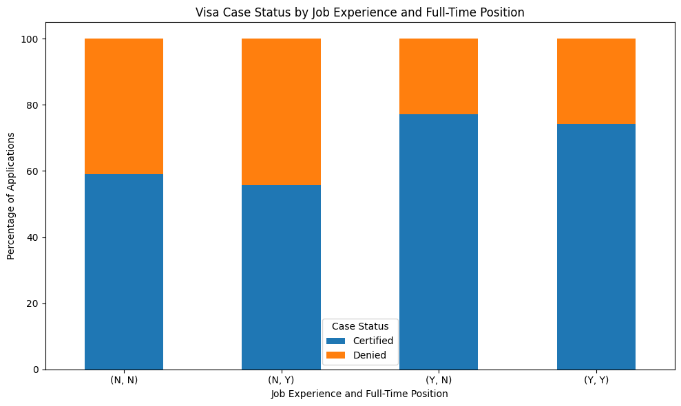

```python
experience_fulltime.plot(
    kind='bar',
    stacked=True,
    figsize=(10, 6)
)

plt.title(
    'Visa Case Status by Job Experience and Full-Time Position'
)
plt.xlabel('Job Experience and Full-Time Position')
plt.ylabel('Percentage of Applications')
plt.xticks(rotation=0)
plt.legend(title='Case Status')

plt.tight_layout()
plt.show()
```

**Observation:**

This provides additional context about whether employment characteristics jointly differentiate visa case outcomes.

## 4.6 Employer Size, Prevailing Wage and Case Status

Employer size and prevailing wage are analyzed jointly to understand whether visa outcomes vary across different combinations of employer scale and wage levels.

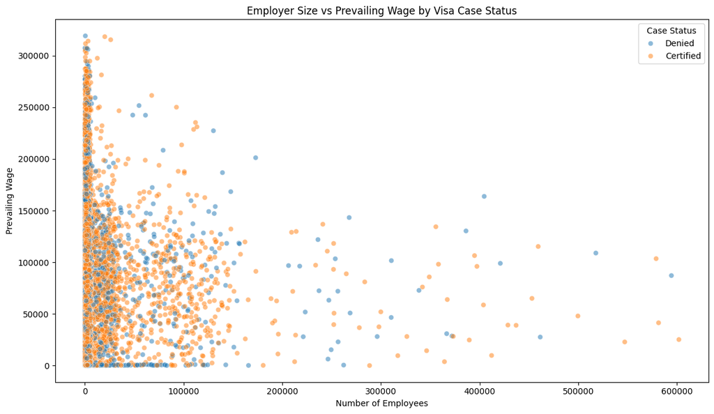

```python
plt.figure(figsize=(12, 7))

sns.scatterplot(
    data=df,
    x='no_of_employees',
    y='prevailing_wage',
    hue='case_status',
    alpha=0.5
)

plt.title(
    'Employer Size vs Prevailing Wage by Visa Case Status'
)
plt.xlabel('Number of Employees')
plt.ylabel('Prevailing Wage')
plt.legend(title='Case Status')

plt.tight_layout()
plt.show()
```

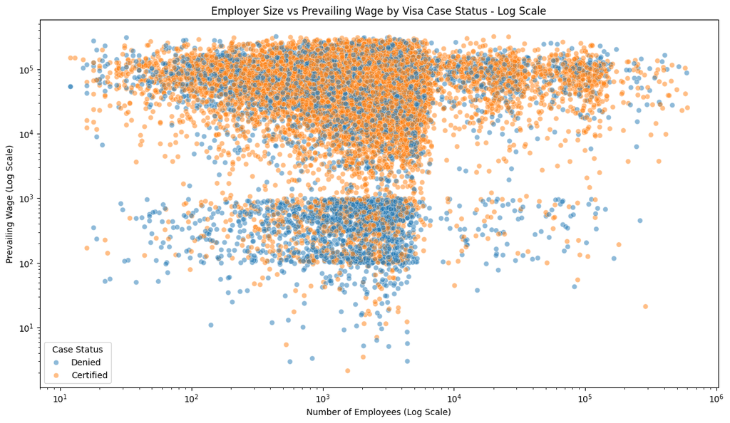

```python
plt.figure(figsize=(12, 7))

sns.scatterplot(
    data=df,
    x='no_of_employees',
    y='prevailing_wage',
    hue='case_status',
    alpha=0.5
)

plt.xscale('log')
plt.yscale('log')

plt.title(
    'Employer Size vs Prevailing Wage by Visa Case Status - Log Scale'
)
plt.xlabel('Number of Employees (Log Scale)')
plt.ylabel('Prevailing Wage (Log Scale)')
plt.legend(title='Case Status')

plt.tight_layout()
plt.show()
```

**Observation:**

The scatter plot examines the joint distribution of employer size and prevailing wage across Certified and Denied applications.

## 4.7 Correlation Analysis

Correlation analysis is performed on the numerical variables to identify the strength and direction of linear relationships between them.

```python
numeric_features = [
    'no_of_employees',
    'yr_of_estab',
    'prevailing_wage'
]

correlation_matrix = df[numeric_features].corr()

display(correlation_matrix.round(2))
```

|  | no_of_employees | yr_of_estab | prevailing_wage |
| --- | --- | --- | --- |
| no_of_employees | 1.00 | -0.02 | -0.01 |
| yr_of_estab | -0.02 | 1.00 | 0.01 |
| prevailing_wage | -0.01 | 0.01 | 1.00 |

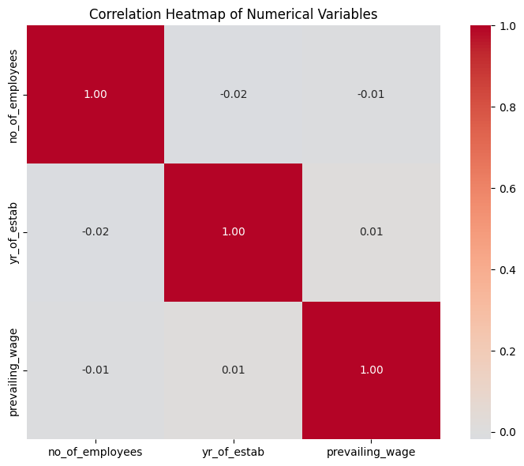

```python
plt.figure(figsize=(8, 6))

sns.heatmap(
    correlation_matrix,
    annot=True,
    fmt='.2f',
    cmap='coolwarm',
    center=0,
    square=True
)

plt.title('Correlation Heatmap of Numerical Variables')

plt.tight_layout()
plt.show()
```

**Observation:**

The correlation matrix shows the linear relationships among the numerical variables.

The correlations will also be considered during preprocessing and model development, particularly when assessing whether highly related variables could affect model interpretation.

## 4.8 Certification Rate by Multiple Applicant Characteristics

```python
profile_analysis = (
    df.assign(
        certified=(df['case_status'] == 'Certified').astype(int)
    )
    .groupby([
        'education_of_employee',
        'has_job_experience',
        'full_time_position'
    ])
    .agg(
        applications=('case_status', 'size'),
        certification_rate=('certified', 'mean')
    )
)

profile_analysis['certification_rate'] *= 100

profile_analysis = (
    profile_analysis
    .sort_values('certification_rate', ascending=False)
    .round(2)
)

profile_analysis.head(15)
```

| education_of_employee | has_job_experience | full_time_position | applications | certification_rate |
| --- | --- | --- | --- | --- |
| Doctorate | Y | Y | 1204 | 92.86 |
| Master's | Y | Y | 4757 | 89.93 |
| Doctorate | Y | N | 47 | 85.11 |
| Master's | Y | N | 884 | 82.58 |
| Doctorate | N | Y | 908 | 80.40 |
| Bachelor's | Y | N | 372 | 74.19 |
| Doctorate | N | N | 33 | 72.73 |
| Master's | N | N | 854 | 72.13 |
| Bachelor's | Y | Y | 5514 | 70.00 |
| Master's | N | Y | 3139 | 62.15 |
| Bachelor's | N | Y | 4037 | 52.59 |
| High School | Y | N | 107 | 39.25 |
|  |  | Y | 1917 | 35.47 |
| Bachelor's | N | N | 311 | 34.73 |
| High School | N | Y | 1297 | 32.61 |

```python
profile_analysis = (
    df.assign(
        certified=(df['case_status'] == 'Certified').astype(int)
    )
    .groupby([
        'education_of_employee',
        'has_job_experience',
        'full_time_position'
    ])
    .agg(
        applications=('case_status', 'size'),
        certification_rate=('certified', 'mean')
    )
)

profile_analysis['certification_rate'] *= 100

profile_analysis = (
    profile_analysis
    .sort_values('certification_rate', ascending=False)
    .round(2)
)

reliable_profiles = profile_analysis[
    profile_analysis['applications'] >= 50
]

reliable_profiles.head(15)
```

| education_of_employee | has_job_experience | full_time_position | applications | certification_rate |
| --- | --- | --- | --- | --- |
| Doctorate | Y | Y | 1204 | 92.86 |
| Master's | Y | Y | 4757 | 89.93 |
|  |  | N | 884 | 82.58 |
| Doctorate | N | Y | 908 | 80.40 |
| Bachelor's | Y | N | 372 | 74.19 |
| Master's | N | N | 854 | 72.13 |
| Bachelor's | Y | Y | 5514 | 70.00 |
| Master's | N | Y | 3139 | 62.15 |
| Bachelor's | N | Y | 4037 | 52.59 |
| High School | Y | N | 107 | 39.25 |
|  |  | Y | 1917 | 35.47 |
| Bachelor's | N | N | 311 | 34.73 |
| High School | N | Y | 1297 | 32.61 |
|  |  | N | 99 | 19.19 |

# 5. EDA — Consolidated Business Insights

The exploratory data analysis provides several important insights into the characteristics associated with visa case outcomes. The observations below are based on the univariate, bivariate, and multivariate analysis conducted on the EasyVisa dataset.

### 5.1 Applicant Education and Work Experience

Education level and previous job experience show a noticeable association with visa certification outcomes.

Applicants with higher educational qualifications and previous job experience have substantially higher observed certification rates. For example, applicants with a Doctorate and previous job experience have a certification rate of approximately 92.6%, while Master's applicants with previous job experience have a certification rate of approximately 88.8%.

In comparison, applicants with a High School education have lower certification rates, at approximately 35.7% for those with job experience and 31.7% for those without job experience.

**Business implication:** Education and prior work experience appear to be important applicant characteristics and should be considered when developing a data-driven visa case classification system.

### 5.2 Geographic and Educational Characteristics

Certification rates vary across combinations of employee continent and education level.

Doctorate applicants show relatively high certification rates across different continents. For example, the observed certification rate for Doctorate applicants in Europe is approximately 93.1%, while Master's applicants in Europe have a certification rate of approximately 88.1%.

The analysis therefore indicates that geographical characteristics and education level may jointly provide useful information for predicting visa case status.

**Business implication:** A classification model can consider geographical and educational characteristics together rather than evaluating them independently.

### 5.3 Employment Region and Education

The intended region of employment also shows differences in certification rates when analyzed together with education.

Doctorate applicants have high observed certification rates in several employment regions, including approximately 90.6% in the Midwest and 90.0% in the South. Master's applicants also show relatively high certification rates in regions such as the Midwest and South.

**Business implication:** The combination of employee qualifications and intended employment region may help identify cases that require different levels of review or prioritization.

### 5.4 Previous Job Experience and Employment Type

Previous job experience is associated with different certification patterns across full-time and non-full-time positions.

Applicants with previous job experience have certification rates of approximately 77.2% for non-full-time positions and 74.2% for full-time positions. Applicants without previous job experience have comparatively lower certification rates of approximately 59.1% and 55.7%, respectively.

**Business implication:** Previous job experience appears to provide useful information for distinguishing between visa case outcomes and should be evaluated during model development.

### 5.5 Prevailing Wage

Prevailing wage shows a noticeable difference between Certified and Denied applications.

Certified applications have an average prevailing wage of approximately $77,294 and a median of approximately $72,486, compared with an average of approximately $68,749 and a median of approximately $65,431 for Denied applications.

**Business implication:** Prevailing wage may be an important predictor when identifying patterns associated with visa certification.

However, this represents an observed association and should not be interpreted as evidence that wage level directly causes visa approval.

### 5.6 Employer Characteristics

Employer size shows a smaller difference between Certified and Denied applications than prevailing wage.

The median number of employees is approximately 2,147 for Certified cases compared with approximately 2,033 for Denied cases.

The relatively small difference suggests that employer size may provide some predictive information, but its importance should be determined through the subsequent machine learning models rather than from EDA alone.

### 5.7 Relationships Among Numerical Variables

The numerical variables show very weak linear relationships with one another.

The correlations between the numerical predictors are close to zero:

- Number of employees vs establishment year: approximately -0.018
- Number of employees vs prevailing wage: approximately -0.010
- Establishment year vs prevailing wage: approximately 0.012

**Business implication:** There is no strong linear relationship among these numerical variables based on Pearson correlation. Therefore, each variable may provide relatively independent information to the classification models.

### 5.8 Overall EDA Conclusion

Overall, the exploratory analysis indicates that visa case status is associated with a combination of applicant, employer, geographical, wage, and employment-related characteristics.

Education level and previous job experience show particularly noticeable differences in observed certification rates, while prevailing wage also demonstrates a meaningful difference between Certified and Denied cases.

These findings provide a basis for the subsequent machine learning analysis. However, EDA alone cannot determine which variables are the strongest predictors of visa case status. The classification models developed in the next stages will evaluate the combined predictive contribution of these variables.

The identified patterns will also be used later to develop evidence-based business insights and actionable recommendations.

# 6. Data Preprocessing

## 6.1 Data Quality Checks

Before preparing the data for machine learning, the dataset is examined for duplicate records, missing values, invalid values, inconsistent categories, and potential data-quality issues.

The purpose of this step is to ensure that the data supplied to the machine learning models is reliable and suitable for analysis.

```python
# Create a copy of the original dataset
visa_df = df.copy()

# Basic structure
print("Dataset Shape:", visa_df.shape)

# Missing values
print("\nMissing Values:")
display(visa_df.isnull().sum().to_frame('Missing Count'))

# Duplicate rows
print("\nDuplicate Rows:", visa_df.duplicated().sum())

# Unique values for categorical variables
categorical_cols = visa_df.select_dtypes(include='object').columns

for col in categorical_cols:
    print(f"\n{col}:")
    print(visa_df[col].unique())
```

```
Dataset Shape: (25480, 12)

Missing Values:
```

|  | Missing Count |
| --- | --- |
| case_id | 0 |
| continent | 0 |
| education_of_employee | 0 |
| has_job_experience | 0 |
| requires_job_training | 0 |
| no_of_employees | 0 |
| yr_of_estab | 0 |
| region_of_employment | 0 |
| prevailing_wage | 0 |
| unit_of_wage | 0 |
| full_time_position | 0 |
| case_status | 0 |

```
Duplicate Rows: 0

case_id:
['EZYV01' 'EZYV02' 'EZYV03' ... 'EZYV25478' 'EZYV25479' 'EZYV25480']

continent:
['Asia' 'Africa' 'North America' 'Europe' 'South America' 'Oceania']

education_of_employee:
['High School' "Master's" "Bachelor's" 'Doctorate']

has_job_experience:
['N' 'Y']

requires_job_training:
['N' 'Y']

region_of_employment:
['West' 'Northeast' 'South' 'Midwest' 'Island']

unit_of_wage:
['Hour' 'Year' 'Week' 'Month']

full_time_position:
['Y' 'N']

case_status:
['Denied' 'Certified']
```

## 6.2 Duplicate Treatment

Duplicate records can cause certain observations to receive disproportionate importance during model training. Therefore, duplicate records are checked before model development.

No duplicate records were identified in the dataset. Therefore, no rows were removed on the basis of duplication.

```python
duplicate_count = visa_df.duplicated().sum()

if duplicate_count > 0:
    visa_df = visa_df.drop_duplicates().reset_index(drop=True)

print("Duplicate rows after treatment:", visa_df.duplicated().sum())
print("Dataset shape after duplicate treatment:", visa_df.shape)
```

```
Duplicate rows after treatment: 0
Dataset shape after duplicate treatment: (25480, 12)
```

## 6.3 Invalid Value Treatment

The `no_of_employees` variable represents the number of employees in an employer's organization. Since the number of employees cannot logically be negative, negative observations are treated as invalid values.

These observations will be converted to missing values and subsequently imputed using information derived only from the training data. This avoids arbitrarily assigning a value and maintains the leakage-safe preprocessing workflow.

```python
# Identify invalid employee counts
invalid_employee_count = (visa_df['no_of_employees'] < 0).sum()

print("Number of negative employee-count records:",
      invalid_employee_count)

print("\nInvalid employee-count values:")
display(
    visa_df.loc[
        visa_df['no_of_employees'] < 0,
        ['case_id', 'no_of_employees']
    ].head(20)
)
```

```
Number of negative employee-count records: 33

Invalid employee-count values:
```

|  | case_id | no_of_employees |
| --- | --- | --- |
| 245 | EZYV246 | -25 |
| 378 | EZYV379 | -11 |
| 832 | EZYV833 | -17 |
| 2918 | EZYV2919 | -26 |
| 6439 | EZYV6440 | -14 |
| 6634 | EZYV6635 | -26 |
| 7224 | EZYV7225 | -25 |
| 7281 | EZYV7282 | -14 |
| 7318 | EZYV7319 | -26 |
| 7761 | EZYV7762 | -11 |
| 9872 | EZYV9873 | -26 |
| 11493 | EZYV11494 | -14 |
| 13471 | EZYV13472 | -17 |
| 14022 | EZYV14023 | -11 |
| 14146 | EZYV14147 | -26 |
| 14726 | EZYV14727 | -11 |
| 15600 | EZYV15601 | -14 |
| 15859 | EZYV15860 | -11 |
| 16157 | EZYV16158 | -11 |
| 16883 | EZYV16884 | -26 |

#### Convert invalid values to NaN

```python
# Replace logically invalid negative employee counts with NaN
visa_df.loc[
    visa_df['no_of_employees'] < 0,
    'no_of_employees'
] = np.nan

print(
    "Missing values in no_of_employees after invalid-value treatment:",
    visa_df['no_of_employees'].isna().sum()
)
```

```
Missing values in no_of_employees after invalid-value treatment: 33
```

## 6.4 Feature Engineering

### 6.4.1 Employer Age

The `yr_of_estab` variable represents the year in which the employer's company was established. To create a more interpretable business feature, employer age is derived using 2016 as the reference year because the EasyVisa case study is based on FY 2016.

**Employer Age = 2016 − Year of Establishment**

A higher value therefore represents an older employer organization.

```python
# Create employer age using FY 2016 as the reference year
REFERENCE_YEAR = 2016

visa_df['employer_age'] = (
    REFERENCE_YEAR - visa_df['yr_of_estab']
)

# Check the new feature
display(
    visa_df[
        ['yr_of_estab', 'employer_age']
    ].head()
)
```

|  | yr_of_estab | employer_age |
| --- | --- | --- |
| 0 | 2007 | 9 |
| 1 | 2002 | 14 |
| 2 | 2008 | 8 |
| 3 | 1897 | 119 |
| 4 | 2005 | 11 |

#### Validate

```python
print("Employer age statistics:")
display(visa_df['employer_age'].describe())
```

```
Employer age statistics:
```

|  | employer_age |
| --- | --- |
| count | 25480.000000 |
| mean | 36.590071 |
| std | 42.366929 |
| min | 0.000000 |
| 25% | 11.000000 |
| 50% | 19.000000 |
| 75% | 40.000000 |
| max | 216.000000 |

**dtype:** float64

### 6.4.2 Check Employer Age

```python
print("Minimum employer age:",
      visa_df['employer_age'].min())

print("Maximum employer age:",
      visa_df['employer_age'].max())
```

```
Minimum employer age: 0
Maximum employer age: 216
```

## 6.5 Separating Features and Target

The target variable `case_status` represents the visa application outcome and is separated from the predictor variables before model development.

The `case_id` variable is an application identifier and does not contain meaningful predictive information about the visa outcome. Therefore, it is excluded from the feature set.

```python
# Separate target
X = visa_df.drop(columns=['case_status', 'case_id'])

y = visa_df['case_status'].copy()

print("Feature shape:", X.shape)
print("Target shape :", y.shape)

print("\nFeatures:")
print(X.columns.tolist())

print("\nTarget:")
print(y.name)
```

```
Feature shape: (25480, 11)
Target shape : (25480,)

Features:
['continent', 'education_of_employee', 'has_job_experience', 'requires_job_training', 'no_of_employees', 'yr_of_estab', 'region_of_employment', 'prevailing_wage', 'unit_of_wage', 'full_time_position', 'employer_age']

Target:
case_status
```

## 6.6 Train-Test Split

The dataset is divided into training and test sets before applying any data-driven preprocessing operation.

This is necessary to prevent data leakage. Statistics such as imputation values, outlier-treatment thresholds, and encoding parameters will be learned from the training set only.

Stratification is used because the target variable contains two classes and their proportions should be maintained across the training and test sets.

The test set will remain untouched until final model evaluation.

```python
from sklearn.model_selection import train_test_split

X_train, X_test, y_train, y_test = train_test_split(
    X,
    y,
    test_size=0.20,
    random_state=42,
    stratify=y
)

print("Training set shape:", X_train.shape)
print("Test set shape    :", X_test.shape)
```

```
Training set shape: (20384, 11)
Test set shape    : (5096, 11)
```

```python
train_distribution = (
    y_train.value_counts(normalize=True) * 100
).round(2)

test_distribution = (
    y_test.value_counts(normalize=True) * 100
).round(2)

distribution_comparison = pd.DataFrame({
    'Training %': train_distribution,
    'Test %': test_distribution
})

display(distribution_comparison)
```

| case_status | Training % | Test % |
| --- | --- | --- |
| Certified | 66.79 | 66.8 |
| Denied | 33.21 | 33.2 |

## 6.7 Missing Value Treatment

The original dataset does not contain missing values. However, logically invalid negative values in `no_of_employees` were converted to missing values during data-quality treatment.

For numerical variables, missing values will be imputed using the median calculated from the training data.

The test-set values will be transformed using the training-set median. Therefore, information from the test set is not used to determine the imputation value.

```python
# Check missing values in training and test sets
print("Training missing values:")
display(X_train.isnull().sum())

print("\nTest missing values:")
display(X_test.isnull().sum())
```

```
Training missing values:
```

|  | 0 |
| --- | --- |
| continent | 0 |
| education_of_employee | 0 |
| has_job_experience | 0 |
| requires_job_training | 0 |
| no_of_employees | 29 |
| yr_of_estab | 0 |
| region_of_employment | 0 |
| prevailing_wage | 0 |
| unit_of_wage | 0 |
| full_time_position | 0 |
| employer_age | 0 |

**dtype:** int64

```
Test missing values:
```

|  | 0 |
| --- | --- |
| continent | 0 |
| education_of_employee | 0 |
| has_job_experience | 0 |
| requires_job_training | 0 |
| no_of_employees | 4 |
| yr_of_estab | 0 |
| region_of_employment | 0 |
| prevailing_wage | 0 |
| unit_of_wage | 0 |
| full_time_position | 0 |
| employer_age | 0 |

**dtype:** int64

## 6.8 Outlier Treatment

Potential outliers in the numerical variables are identified using the Interquartile Range (IQR) method.

For each numerical feature:

- Lower bound = Q1 − 1.5 × IQR
- Upper bound = Q3 + 1.5 × IQR

Instead of deleting observations, extreme values will be capped at the corresponding lower or upper IQR boundary.

The outlier thresholds will be calculated using the training data only and then applied to both training and test data. This prevents information from the test set from influencing preprocessing.

```python
numerical_features = [
    'no_of_employees',
    'yr_of_estab',
    'prevailing_wage',
    'employer_age'
]

print(numerical_features)
```

```
['no_of_employees', 'yr_of_estab', 'prevailing_wage', 'employer_age']
```

```python
outlier_bounds = {}

for col in numerical_features:
    q1 = X_train[col].quantile(0.25)
    q3 = X_train[col].quantile(0.75)

    iqr = q3 - q1

    lower_bound = q1 - 1.5 * iqr
    upper_bound = q3 + 1.5 * iqr

    outlier_bounds[col] = {
        'Q1': q1,
        'Q3': q3,
        'IQR': iqr,
        'Lower Bound': lower_bound,
        'Upper Bound': upper_bound
    }

outlier_bounds_df = pd.DataFrame(outlier_bounds).T

display(outlier_bounds_df.round(2))
```

|  | Q1 | Q3 | IQR | Lower Bound | Upper Bound |
| --- | --- | --- | --- | --- | --- |
| no_of_employees | 1023.00 | 3510.0 | 2487.00 | -2707.50 | 7240.50 |
| yr_of_estab | 1976.00 | 2005.0 | 29.00 | 1932.50 | 2048.50 |
| prevailing_wage | 34114.92 | 107692.9 | 73577.98 | -76252.04 | 218059.86 |
| employer_age | 11.00 | 40.0 | 29.00 | -32.50 | 83.50 |

```python
outlier_summary = []

for col in numerical_features:
    lower = outlier_bounds[col]['Lower Bound']
    upper = outlier_bounds[col]['Upper Bound']

    count = (
        (X_train[col] < lower) |
        (X_train[col] > upper)
    ).sum()

    percentage = count / len(X_train) * 100

    outlier_summary.append([
        col,
        count,
        percentage
    ])

outlier_summary_df = pd.DataFrame(
    outlier_summary,
    columns=[
        'Variable',
        'Outlier Count',
        'Outlier Percentage'
    ]
)

display(outlier_summary_df.round(2))
```

|  | Variable | Outlier Count | Outlier Percentage |
| --- | --- | --- | --- |
| 0 | no_of_employees | 1277 | 6.26 |
| 1 | yr_of_estab | 2575 | 12.63 |
| 2 | prevailing_wage | 349 | 1.71 |
| 3 | employer_age | 2575 | 12.63 |

### 6.8.1 Apply Outlier Capping

```python
def cap_outliers(data, bounds):
    data = data.copy()

    for col, values in bounds.items():
        lower = values['Lower Bound']
        upper = values['Upper Bound']

        data[col] = data[col].clip(
            lower=lower,
            upper=upper
        )

    return data
```

```python
X_train = cap_outliers(X_train, outlier_bounds)
X_test = cap_outliers(X_test, outlier_bounds)

print("Outlier capping completed.")
```

```
Outlier capping completed.
```

## 6.9 Categorical Encoding

```python
pd.get_dummies(X)
```

|  | no_of_employees | yr_of_estab | prevailing_wage | employer_age | continent_Africa | continent_Asia | continent_Europe | continent_North America | continent_Oceania | continent_South America | education_of_employee_Bachelor's | education_of_employee_Doctorate | education_of_employee_High School | education_of_employee_Master's | has_job_experience_N | has_job_experience_Y | requires_job_training_N | requires_job_training_Y | region_of_employment_Island | region_of_employment_Midwest | region_of_employment_Northeast | region_of_employment_South | region_of_employment_West | unit_of_wage_Hour | unit_of_wage_Month | unit_of_wage_Week | unit_of_wage_Year | full_time_position_N | full_time_position_Y |
| --- | --- | --- | --- | --- | --- | --- | --- | --- | --- | --- | --- | --- | --- | --- | --- | --- | --- | --- | --- | --- | --- | --- | --- | --- | --- | --- | --- | --- | --- |
| 0 | 14513.0 | 2007 | 592.2029 | 9 | False | True | False | False | False | False | False | False | True | False | True | False | True | False | False | False | False | False | True | True | False | False | False | False | True |
| 1 | 2412.0 | 2002 | 83425.6500 | 14 | False | True | False | False | False | False | False | False | False | True | False | True | True | False | False | False | True | False | False | False | False | False | True | False | True |
| 2 | 44444.0 | 2008 | 122996.8600 | 8 | False | True | False | False | False | False | True | False | False | False | True | False | False | True | False | False | False | False | True | False | False | False | True | False | True |
| 3 | 98.0 | 1897 | 83434.0300 | 119 | False | True | False | False | False | False | True | False | False | False | True | False | True | False | False | False | False | False | True | False | False | False | True | False | True |
| 4 | 1082.0 | 2005 | 149907.3900 | 11 | True | False | False | False | False | False | False | False | False | True | False | True | True | False | False | False | False | True | False | False | False | False | True | False | True |
| ... | ... | ... | ... | ... | ... | ... | ... | ... | ... | ... | ... | ... | ... | ... | ... | ... | ... | ... | ... | ... | ... | ... | ... | ... | ... | ... | ... | ... | ... |
| 25475 | 2601.0 | 2008 | 77092.5700 | 8 | False | True | False | False | False | False | True | False | False | False | False | True | False | True | False | False | False | True | False | False | False | False | True | False | True |
| 25476 | 3274.0 | 2006 | 279174.7900 | 10 | False | True | False | False | False | False | False | False | True | False | False | True | True | False | False | False | True | False | False | False | False | False | True | False | True |
| 25477 | 1121.0 | 1910 | 146298.8500 | 106 | False | True | False | False | False | False | False | False | False | True | False | True | True | False | False | False | False | True | False | False | False | False | True | True | False |
| 25478 | 1918.0 | 1887 | 86154.7700 | 129 | False | True | False | False | False | False | False | False | False | True | False | True | False | True | False | False | False | False | True | False | False | False | True | False | True |
| 25479 | 3195.0 | 1960 | 70876.9100 | 56 | False | True | False | False | False | False | True | False | False | False | False | True | True | False | False | True | False | False | False | False | False | False | True | False | True |

25480 rows × 29 columns

#### Identify categorical columns

```python
categorical_features = [
    col for col in X_train.columns
    if col not in numerical_features
]

print("Categorical features:")
print(categorical_features)
```

```
Categorical features:
['continent', 'education_of_employee', 'has_job_experience', 'requires_job_training', 'region_of_employment', 'unit_of_wage', 'full_time_position']
```

## 6.10 Build Leakage-Safe Preprocessing Pipeline

```python
from sklearn.compose import ColumnTransformer
from sklearn.pipeline import Pipeline
from sklearn.impute import SimpleImputer
from sklearn.preprocessing import OneHotEncoder

# Numerical preprocessing
numeric_transformer = Pipeline(
    steps=[
        (
            'imputer',
            SimpleImputer(strategy='median')
        )
    ]
)

# Categorical preprocessing
categorical_transformer = Pipeline(
    steps=[
        (
            'imputer',
            SimpleImputer(strategy='most_frequent')
        ),
        (
            'encoder',
            OneHotEncoder(
                handle_unknown='ignore',
                sparse_output=False
            )
        )
    ]
)

# Combined preprocessing
preprocessor = ColumnTransformer(
    transformers=[
        (
            'num',
            numeric_transformer,
            numerical_features
        ),
        (
            'cat',
            categorical_transformer,
            categorical_features
        )
    ],
    remainder='drop'
)

print("Preprocessor created successfully.")
```

```
Preprocessor created successfully.
```

## 6.11 Fit Preprocessor Only on Training Data

```python
# Fit only on training data
X_train_processed = preprocessor.fit_transform(X_train)

# Transform test data using the already-fitted preprocessor
X_test_processed = preprocessor.transform(X_test)

print("Processed training shape:", X_train_processed.shape)
print("Processed test shape    :", X_test_processed.shape)
```

```
Processed training shape: (20384, 29)
Processed test shape    : (5096, 29)
```

#### Verify dimensions

```python
print("Training observations:", X_train_processed.shape[0])
print("Test observations    :", X_test_processed.shape[0])
print("Number of processed features:", X_train_processed.shape[1])
```

```
Training observations: 20384
Test observations    : 5096
Number of processed features: 29
```

## 6.12 Get Processed Feature Names

```python
feature_names = preprocessor.get_feature_names_out()

print("Number of final features:", len(feature_names))

feature_names[:20]
```

```
Number of final features: 29
```

```
array(['num__no_of_employees', 'num__yr_of_estab', 'num__prevailing_wage',
       'num__employer_age', 'cat__continent_Africa',
       'cat__continent_Asia', 'cat__continent_Europe',
       'cat__continent_North America', 'cat__continent_Oceania',
       'cat__continent_South America',
       "cat__education_of_employee_Bachelor's",
       'cat__education_of_employee_Doctorate',
       'cat__education_of_employee_High School',
       "cat__education_of_employee_Master's", 'cat__has_job_experience_N',
       'cat__has_job_experience_Y', 'cat__requires_job_training_N',
       'cat__requires_job_training_Y', 'cat__region_of_employment_Island',
       'cat__region_of_employment_Midwest'], dtype=object)
```

#### Convert to DataFrame:

```python
X_train_processed_df = pd.DataFrame(
    X_train_processed,
    columns=feature_names,
    index=X_train.index
)

X_test_processed_df = pd.DataFrame(
    X_test_processed,
    columns=feature_names,
    index=X_test.index
)

display(X_train_processed_df.head())
```

|  | num__no_of_employees | num__yr_of_estab | num__prevailing_wage | num__employer_age | cat__continent_Africa | cat__continent_Asia | cat__continent_Europe | cat__continent_North America | cat__continent_Oceania | cat__continent_South America | cat__education_of_employee_Bachelor's | cat__education_of_employee_Doctorate | cat__education_of_employee_High School | cat__education_of_employee_Master's | cat__has_job_experience_N | cat__has_job_experience_Y | cat__requires_job_training_N | cat__requires_job_training_Y | cat__region_of_employment_Island | cat__region_of_employment_Midwest | cat__region_of_employment_Northeast | cat__region_of_employment_South | cat__region_of_employment_West | cat__unit_of_wage_Hour | cat__unit_of_wage_Month | cat__unit_of_wage_Week | cat__unit_of_wage_Year | cat__full_time_position_N | cat__full_time_position_Y |
| --- | --- | --- | --- | --- | --- | --- | --- | --- | --- | --- | --- | --- | --- | --- | --- | --- | --- | --- | --- | --- | --- | --- | --- | --- | --- | --- | --- | --- | --- |
| 15752 | 2516.0 | 1995.0 | 34293.61 | 21.0 | 0.0 | 0.0 | 0.0 | 0.0 | 0.0 | 1.0 | 0.0 | 0.0 | 1.0 | 0.0 | 0.0 | 1.0 | 1.0 | 0.0 | 0.0 | 0.0 | 0.0 | 0.0 | 1.0 | 0.0 | 0.0 | 0.0 | 1.0 | 0.0 | 1.0 |
| 17311 | 2868.0 | 2013.0 | 166380.37 | 3.0 | 0.0 | 1.0 | 0.0 | 0.0 | 0.0 | 0.0 | 0.0 | 1.0 | 0.0 | 0.0 | 1.0 | 0.0 | 1.0 | 0.0 | 0.0 | 1.0 | 0.0 | 0.0 | 0.0 | 0.0 | 0.0 | 0.0 | 1.0 | 0.0 | 1.0 |
| 9192 | 3273.0 | 1932.5 | 34431.42 | 83.5 | 0.0 | 1.0 | 0.0 | 0.0 | 0.0 | 0.0 | 0.0 | 0.0 | 1.0 | 0.0 | 0.0 | 1.0 | 1.0 | 0.0 | 0.0 | 0.0 | 0.0 | 0.0 | 1.0 | 0.0 | 0.0 | 0.0 | 1.0 | 0.0 | 1.0 |
| 23802 | 1892.0 | 2000.0 | 21367.96 | 16.0 | 0.0 | 1.0 | 0.0 | 0.0 | 0.0 | 0.0 | 0.0 | 0.0 | 0.0 | 1.0 | 0.0 | 1.0 | 1.0 | 0.0 | 0.0 | 0.0 | 0.0 | 0.0 | 1.0 | 0.0 | 0.0 | 0.0 | 1.0 | 0.0 | 1.0 |
| 7867 | 414.0 | 2004.0 | 149629.63 | 12.0 | 0.0 | 1.0 | 0.0 | 0.0 | 0.0 | 0.0 | 1.0 | 0.0 | 0.0 | 0.0 | 1.0 | 0.0 | 1.0 | 0.0 | 0.0 | 1.0 | 0.0 | 0.0 | 0.0 | 0.0 | 0.0 | 0.0 | 1.0 | 0.0 | 1.0 |

## 6.13 Encode Target Variable

```python
from sklearn.preprocessing import LabelEncoder

label_encoder = LabelEncoder()

y_train_encoded = label_encoder.fit_transform(y_train)
y_test_encoded = label_encoder.transform(y_test)

print("Target classes:")
print(label_encoder.classes_)
```

```
Target classes:
['Certified' 'Denied']
```

#### Verify:

```python
target_mapping = {
    class_name: index
    for index, class_name in enumerate(label_encoder.classes_)
}

print("Target mapping:")
print(target_mapping)
```

```
Target mapping:
{'Certified': 0, 'Denied': 1}
```

```python
target_mapping = {
    'Denied': 0,
    'Certified': 1
}

y_train_encoded = y_train.map(target_mapping).values
y_test_encoded = y_test.map(target_mapping).values

print(target_mapping)
print("Unique encoded training labels:", np.unique(y_train_encoded))
print("Unique encoded test labels:", np.unique(y_test_encoded))
```

```
{'Denied': 0, 'Certified': 1}
Unique encoded training labels: [0 1]
Unique encoded test labels: [0 1]
```

## 6.14 Final Preprocessed Data Check

The preprocessing stage is now complete. The data has been prepared for machine learning using the following steps:

- Duplicate records were checked and treated.
- Invalid negative employee counts were identified and converted to missing values.
- Employer age was engineered from the establishment year using FY 2016 as the reference year.
- The identifier `case_id` was excluded from the predictor variables.
- The dataset was split into training and test sets using stratification.
- Missing numerical values were handled using training-set-derived median imputation.
- Potential numerical outliers were capped using IQR boundaries calculated from the training data only.
- Categorical variables were one-hot encoded.
- The preprocessing transformer was fitted only on the training data and subsequently applied to the test data.
- The target variable was encoded with `Denied = 0` and `Certified = 1`.

The test set has not been used to estimate preprocessing parameters.

```python
print("DATA LEAKAGE CHECK")
print("=" * 50)

print("1. Train/Test split performed before preprocessing:      YES")
print("2. Outlier bounds calculated using training data only:   YES")
print("3. Numerical imputation fitted on training data only:    YES")
print("4. Categorical encoder fitted on training data only:     YES")
print("5. Test data used for fitting preprocessing:             NO")
print("6. Test data used for model training:                    NO")
print("7. Oversampling/undersampling applied to test data:      NO")
```

```
DATA LEAKAGE CHECK
==================================================
1. Train/Test split performed before preprocessing:      YES
2. Outlier bounds calculated using training data only:   YES
3. Numerical imputation fitted on training data only:    YES
4. Categorical encoder fitted on training data only:     YES
5. Test data used for fitting preprocessing:             NO
6. Test data used for model training:                    NO
7. Oversampling/undersampling applied to test data:      NO
```

```python
print("\nFINAL DATA SHAPES")
print("=" * 50)
print("X_train_processed :", X_train_processed.shape)
print("X_test_processed  :", X_test_processed.shape)
print("y_train            :", y_train_encoded.shape)
print("y_test             :", y_test_encoded.shape)
```

```
FINAL DATA SHAPES
==================================================
X_train_processed : (20384, 29)
X_test_processed  : (5096, 29)
y_train            : (20384,)
y_test             : (5096,)
```

## 6.16 Data Preprocessing Summary

The EasyVisa dataset was prepared for machine learning while maintaining a strict separation between training and test information.

The main preprocessing steps included data-quality validation, treatment of logically invalid employee-count values, feature engineering of employer age, removal of the application identifier, stratified train-test splitting, missing-value treatment, IQR-based outlier capping, categorical encoding, and target encoding.

A leakage-safe preprocessing approach was followed throughout the process. Data-dependent preprocessing parameters were learned exclusively from the training data and subsequently applied to the test data.

The test dataset remains untouched for model development and will be used only for evaluating the final selected model.

The resulting processed training and test datasets are now ready for the three required modelling scenarios:

1. **Original Training Data**
2. **Oversampled Training Data**
3. **Undersampled Training Data**

# 7. Train-Test Split — BEFORE Leakage-Prone Operations

The target variable `case_status` is separated from the predictor variables before splitting the dataset.

The `case_id` variable is excluded because it is an application identifier and does not provide meaningful predictive information.

The resulting dataset is divided into training and test sets before any data-dependent preprocessing or class-imbalance treatment is performed.

## 7.1 Separate Predictors and Target

```python
# X contains predictor variables
# y contains the target variable

X = visa_df.drop(columns=['case_status', 'case_id'])
y = visa_df['case_status']

print("Feature shape:", X.shape)
print("Target shape :", y.shape)
```

```
Feature shape: (25480, 11)
Target shape : (25480,)
```

### 7.2 Stratified Train-Test Split

The dataset is divided into training and test sets using an 80:20 split.

Stratification is applied to preserve the proportion of Certified and Denied cases in both datasets. This is particularly important because the target variable is imbalanced.

A fixed random state is used to ensure reproducibility.

The test set will remain completely separate from model training, resampling, hyperparameter tuning, and preprocessing parameter estimation.

```python
from sklearn.model_selection import train_test_split

X_train, X_test, y_train, y_test = train_test_split(
    X,
    y,
    test_size=0.20,
    random_state=42,
    stratify=y
)

print("Training data shape:", X_train.shape)
print("Test data shape    :", X_test.shape)
```

```
Training data shape: (20384, 11)
Test data shape    : (5096, 11)
```

## 7.3 Verify Target Distribution

```python
# Overall target distribution
overall_distribution = (
    y.value_counts(normalize=True) * 100
).round(2)

# Training target distribution
train_distribution = (
    y_train.value_counts(normalize=True) * 100
).round(2)

# Test target distribution
test_distribution = (
    y_test.value_counts(normalize=True) * 100
).round(2)

distribution_check = pd.DataFrame({
    'Overall (%)': overall_distribution,
    'Training (%)': train_distribution,
    'Test (%)': test_distribution
})

display(distribution_check)
```

| case_status | Overall (%) | Training (%) | Test (%) |
| --- | --- | --- | --- |
| Certified | 66.79 | 66.79 | 66.8 |
| Denied | 33.21 | 33.21 | 33.2 |

## 7.4 Verify Dataset Sizes

```python
print("Total observations :", len(X))
print("Training observations:", len(X_train))
print("Test observations    :", len(X_test))

print("\nTraining percentage:",
      round(len(X_train) / len(X) * 100, 2), "%")

print("Test percentage    :",
      round(len(X_test) / len(X) * 100, 2), "%")
```

```
Total observations : 25480
Training observations: 20384
Test observations    : 5096

Training percentage: 80.0 %
Test percentage    : 20.0 %
```

## 7.5 Verify No Row Overlap

```python
train_indices = set(X_train.index)
test_indices = set(X_test.index)

overlap = train_indices.intersection(test_indices)

print("Number of overlapping observations:", len(overlap))
```

```
Number of overlapping observations: 0
```

```python
assert len(overlap) == 0, "Data leakage detected: train/test overlap exists!"

print("✓ No observation appears in both training and test sets.")
```

```
✓ No observation appears in both training and test sets.
```

## 7.6 Verify Target Leakage

```python
print("Target column:", y.name)

print("\nIs target present in X?",
      'case_status' in X.columns)

print("Is case_id present in X?",
      'case_id' in X.columns)
```

```
Target column: case_status

Is target present in X? False
Is case_id present in X? False
```

#### Add assertions:

```python
assert 'case_status' not in X.columns
assert 'case_id' not in X.columns

print("✓ Target and identifier are excluded from predictor variables.")
```

```
✓ Target and identifier are excluded from predictor variables.
```

## 7.7 Leakage-Safe Processing Rules

After the train-test split, the following rules will be followed throughout the project:

1. Imputation parameters will be calculated using the training data only.
2. Outlier-treatment thresholds will be calculated using the training data only.
3. Encoding transformations will be fitted using the training data only.
4. Oversampling will be applied only to the training data.
5. Undersampling will be applied only to the training data.
6. Hyperparameter tuning and cross-validation will use training data only.
7. The test dataset will not be used for model selection.
8. The test dataset will not be used to determine preprocessing parameters.
9. The test dataset will not be resampled.
10. The untouched test dataset will be used only for evaluating the final selected model.

## 7.8 Leakage-Safe Modeling Workflow

The modeling workflow will follow the sequence below:

**Original Dataset**

↓

**Separate Features and Target**

↓

**Stratified Train-Test Split**

↓

### Training Data

→ Missing-value treatment  
→ Outlier treatment  
→ Feature encoding  
→ Original-data modeling  
→ Oversampling + modeling  
→ Undersampling + modeling  
→ Hyperparameter tuning  
→ Model comparison  
→ Final model selection

### Test Data

→ Remains untouched during model development  
→ Used only for final evaluation of the selected model

This workflow ensures that information from the test dataset does not influence preprocessing, resampling, model selection, or hyperparameter tuning.

## 7.9 Final Verification Cell

```python
print("=" * 65)
print("FINAL TRAIN-TEST LEAKAGE CHECK")
print("=" * 65)

print(f"Total observations       : {len(X)}")
print(f"Training observations   : {len(X_train)}")
print(f"Test observations       : {len(X_test)}")

print(f"\nTrain/Test overlap      : {len(overlap)}")
print(f"Target in X             : {'case_status' in X.columns}")
print(f"Identifier in X         : {'case_id' in X.columns}")

print("\nTarget distribution:")
display(distribution_check)

print("\n" + "=" * 65)

if (
    len(overlap) == 0
    and 'case_status' not in X.columns
    and 'case_id' not in X.columns
):
    print("✓ DATA SPLIT PASSED LEAKAGE CHECK")
else:
    print("✗ DATA SPLIT REQUIRES REVIEW")
```

```
=================================================================
FINAL TRAIN-TEST LEAKAGE CHECK
=================================================================
Total observations       : 25480
Training observations   : 20384
Test observations       : 5096

Train/Test overlap      : 0
Target in X             : False
Identifier in X         : False

Target distribution:
```

| case_status | Overall (%) | Training (%) | Test (%) |
| --- | --- | --- | --- |
| Certified | 66.79 | 66.79 | 66.8 |
| Denied | 33.21 | 33.21 | 33.2 |

```
=================================================================
✓ DATA SPLIT PASSED LEAKAGE CHECK
```

### Conclusion

The EasyVisa dataset has been divided into training and test sets using a stratified 80:20 split. The target-class proportions are maintained across the two sets, and no observations overlap between the training and test datasets.

The training data will be used for preprocessing, resampling, model development, cross-validation, and hyperparameter tuning. The test data will remain untouched until the final model evaluation.

This separation prevents information from the test dataset from influencing model development and helps provide an unbiased estimate of the final model's performance.

# 8. Encoding

For EasyVisa, encoding is required because the dataset contains several categorical variables, while the Decision Tree, Bagging, Random Forest, AdaBoost, Gradient Boosting, and XGBoost models require numerical inputs.

## 8.1 Identification of Categorical and Numerical Features

The EasyVisa dataset contains both numerical and categorical predictor variables.

The numerical variables will retain their numerical representation, while categorical variables will be converted into numerical indicator variables using One-Hot Encoding.

The encoding transformation will be fitted only on the training data and then applied to the test data.

```python
# Numerical features
numerical_features = [
    'no_of_employees',
    'yr_of_estab',
    'prevailing_wage',
    'employer_age'
]

# Categorical features
categorical_features = [
    col for col in X_train.columns
    if col not in numerical_features
]

print("Numerical Features:")
print(numerical_features)

print("\nCategorical Features:")
print(categorical_features)
```

```
Numerical Features:
['no_of_employees', 'yr_of_estab', 'prevailing_wage', 'employer_age']

Categorical Features:
['continent', 'education_of_employee', 'has_job_experience', 'requires_job_training', 'region_of_employment', 'unit_of_wage', 'full_time_position']
```

### 8.2 Check Categories Before Encoding

```python
for col in categorical_features:
    print(f"\n{'=' * 60}")
    print(f"Feature: {col}")
    print("Number of categories:", X_train[col].nunique())
    print("Categories:")
    print(sorted(X_train[col].dropna().unique()))
```

```
============================================================
Feature: continent
Number of categories: 6
Categories:
['Africa', 'Asia', 'Europe', 'North America', 'Oceania', 'South America']

============================================================
Feature: education_of_employee
Number of categories: 4
Categories:
["Bachelor's", 'Doctorate', 'High School', "Master's"]

============================================================
Feature: has_job_experience
Number of categories: 2
Categories:
['N', 'Y']

============================================================
Feature: requires_job_training
Number of categories: 2
Categories:
['N', 'Y']

============================================================
Feature: region_of_employment
Number of categories: 5
Categories:
['Island', 'Midwest', 'Northeast', 'South', 'West']

============================================================
Feature: unit_of_wage
Number of categories: 4
Categories:
['Hour', 'Month', 'Week', 'Year']

============================================================
Feature: full_time_position
Number of categories: 2
Categories:
['N', 'Y']
```

### 8.3 Create One-Hot Encoding Pipeline

```python
from sklearn.compose import ColumnTransformer
from sklearn.pipeline import Pipeline
from sklearn.impute import SimpleImputer
from sklearn.preprocessing import OneHotEncoder

# Numerical preprocessing
numeric_transformer = Pipeline(
    steps=[
        (
            'imputer',
            SimpleImputer(strategy='median')
        )
    ]
)

# Categorical preprocessing
categorical_transformer = Pipeline(
    steps=[
        (
            'imputer',
            SimpleImputer(strategy='most_frequent')
        ),
        (
            'onehot',
            OneHotEncoder(
                handle_unknown='ignore',
                sparse_output=False
            )
        )
    ]
)

# Combine numerical and categorical preprocessing
preprocessor = ColumnTransformer(
    transformers=[
        (
            'num',
            numeric_transformer,
            numerical_features
        ),
        (
            'cat',
            categorical_transformer,
            categorical_features
        )
    ],
    remainder='drop'
)

print("Leakage-safe preprocessing pipeline created successfully.")
```

```
Leakage-safe preprocessing pipeline created successfully.
```

### 8.4 Fit Encoder on Training Data Only

```python
# Fit the preprocessing pipeline ONLY on training data
X_train_processed = preprocessor.fit_transform(X_train)

# Transform test data using the already-fitted pipeline
X_test_processed = preprocessor.transform(X_test)

print("Processed training shape:", X_train_processed.shape)
print("Processed test shape    :", X_test_processed.shape)
```

```
Processed training shape: (20384, 29)
Processed test shape    : (5096, 29)
```

### 8.5 Check the Number of Generated Features

```python
print("Original number of predictor columns:",
      X_train.shape[1])

print("Number of encoded/processed features:",
      X_train_processed.shape[1])
```

```
Original number of predictor columns: 11
Number of encoded/processed features: 29
```

### 8.6 Retrieve Encoded Feature Names

```python
feature_names = preprocessor.get_feature_names_out()

print("Number of processed features:", len(feature_names))

display(
    pd.DataFrame({
        'Feature': feature_names
    }).head(30)
)
```

```
Number of processed features: 29
```

|  | Feature |
| --- | --- |
| 0 | num__no_of_employees |
| 1 | num__yr_of_estab |
| 2 | num__prevailing_wage |
| 3 | num__employer_age |
| 4 | cat__continent_Africa |
| 5 | cat__continent_Asia |
| 6 | cat__continent_Europe |
| 7 | cat__continent_North America |
| 8 | cat__continent_Oceania |
| 9 | cat__continent_South America |
| 10 | cat__education_of_employee_Bachelor's |
| 11 | cat__education_of_employee_Doctorate |
| 12 | cat__education_of_employee_High School |
| 13 | cat__education_of_employee_Master's |
| 14 | cat__has_job_experience_N |
| 15 | cat__has_job_experience_Y |
| 16 | cat__requires_job_training_N |
| 17 | cat__requires_job_training_Y |
| 18 | cat__region_of_employment_Island |
| 19 | cat__region_of_employment_Midwest |
| 20 | cat__region_of_employment_Northeast |
| 21 | cat__region_of_employment_South |
| 22 | cat__region_of_employment_West |
| 23 | cat__unit_of_wage_Hour |
| 24 | cat__unit_of_wage_Month |
| 25 | cat__unit_of_wage_Week |
| 26 | cat__unit_of_wage_Year |
| 27 | cat__full_time_position_N |
| 28 | cat__full_time_position_Y |

### 8.7 Convert Processed Data to DataFrames

```python
X_train_processed_df = pd.DataFrame(
    X_train_processed,
    columns=feature_names,
    index=X_train.index
)

X_test_processed_df = pd.DataFrame(
    X_test_processed,
    columns=feature_names,
    index=X_test.index
)

print("Processed Training Data:")
display(X_train_processed_df.head())

print("\nProcessed Test Data:")
display(X_test_processed_df.head())
```

```
Processed Training Data:
```

|  | num__no_of_employees | num__yr_of_estab | num__prevailing_wage | num__employer_age | cat__continent_Africa | cat__continent_Asia | cat__continent_Europe | cat__continent_North America | cat__continent_Oceania | cat__continent_South America | cat__education_of_employee_Bachelor's | cat__education_of_employee_Doctorate | cat__education_of_employee_High School | cat__education_of_employee_Master's | cat__has_job_experience_N | cat__has_job_experience_Y | cat__requires_job_training_N | cat__requires_job_training_Y | cat__region_of_employment_Island | cat__region_of_employment_Midwest | cat__region_of_employment_Northeast | cat__region_of_employment_South | cat__region_of_employment_West | cat__unit_of_wage_Hour | cat__unit_of_wage_Month | cat__unit_of_wage_Week | cat__unit_of_wage_Year | cat__full_time_position_N | cat__full_time_position_Y |
| --- | --- | --- | --- | --- | --- | --- | --- | --- | --- | --- | --- | --- | --- | --- | --- | --- | --- | --- | --- | --- | --- | --- | --- | --- | --- | --- | --- | --- | --- |
| 15752 | 2516.0 | 1995.0 | 34293.61 | 21.0 | 0.0 | 0.0 | 0.0 | 0.0 | 0.0 | 1.0 | 0.0 | 0.0 | 1.0 | 0.0 | 0.0 | 1.0 | 1.0 | 0.0 | 0.0 | 0.0 | 0.0 | 0.0 | 1.0 | 0.0 | 0.0 | 0.0 | 1.0 | 0.0 | 1.0 |
| 17311 | 2868.0 | 2013.0 | 166380.37 | 3.0 | 0.0 | 1.0 | 0.0 | 0.0 | 0.0 | 0.0 | 0.0 | 1.0 | 0.0 | 0.0 | 1.0 | 0.0 | 1.0 | 0.0 | 0.0 | 1.0 | 0.0 | 0.0 | 0.0 | 0.0 | 0.0 | 0.0 | 1.0 | 0.0 | 1.0 |
| 9192 | 3273.0 | 1892.0 | 34431.42 | 124.0 | 0.0 | 1.0 | 0.0 | 0.0 | 0.0 | 0.0 | 0.0 | 0.0 | 1.0 | 0.0 | 0.0 | 1.0 | 1.0 | 0.0 | 0.0 | 0.0 | 0.0 | 0.0 | 1.0 | 0.0 | 0.0 | 0.0 | 1.0 | 0.0 | 1.0 |
| 23802 | 1892.0 | 2000.0 | 21367.96 | 16.0 | 0.0 | 1.0 | 0.0 | 0.0 | 0.0 | 0.0 | 0.0 | 0.0 | 0.0 | 1.0 | 0.0 | 1.0 | 1.0 | 0.0 | 0.0 | 0.0 | 0.0 | 0.0 | 1.0 | 0.0 | 0.0 | 0.0 | 1.0 | 0.0 | 1.0 |
| 7867 | 414.0 | 2004.0 | 149629.63 | 12.0 | 0.0 | 1.0 | 0.0 | 0.0 | 0.0 | 0.0 | 1.0 | 0.0 | 0.0 | 0.0 | 1.0 | 0.0 | 1.0 | 0.0 | 0.0 | 1.0 | 0.0 | 0.0 | 0.0 | 0.0 | 0.0 | 0.0 | 1.0 | 0.0 | 1.0 |

```
Processed Test Data:
```

|  | num__no_of_employees | num__yr_of_estab | num__prevailing_wage | num__employer_age | cat__continent_Africa | cat__continent_Asia | cat__continent_Europe | cat__continent_North America | cat__continent_Oceania | cat__continent_South America | cat__education_of_employee_Bachelor's | cat__education_of_employee_Doctorate | cat__education_of_employee_High School | cat__education_of_employee_Master's | cat__has_job_experience_N | cat__has_job_experience_Y | cat__requires_job_training_N | cat__requires_job_training_Y | cat__region_of_employment_Island | cat__region_of_employment_Midwest | cat__region_of_employment_Northeast | cat__region_of_employment_South | cat__region_of_employment_West | cat__unit_of_wage_Hour | cat__unit_of_wage_Month | cat__unit_of_wage_Week | cat__unit_of_wage_Year | cat__full_time_position_N | cat__full_time_position_Y |
| --- | --- | --- | --- | --- | --- | --- | --- | --- | --- | --- | --- | --- | --- | --- | --- | --- | --- | --- | --- | --- | --- | --- | --- | --- | --- | --- | --- | --- | --- |
| 4863 | 3614.0 | 1998.0 | 74251.8500 | 18.0 | 0.0 | 0.0 | 0.0 | 0.0 | 0.0 | 1.0 | 0.0 | 0.0 | 1.0 | 0.0 | 0.0 | 1.0 | 1.0 | 0.0 | 0.0 | 0.0 | 0.0 | 0.0 | 1.0 | 0.0 | 0.0 | 0.0 | 1.0 | 0.0 | 1.0 |
| 1734 | 1250.0 | 1919.0 | 74515.6600 | 97.0 | 0.0 | 1.0 | 0.0 | 0.0 | 0.0 | 0.0 | 0.0 | 0.0 | 1.0 | 0.0 | 1.0 | 0.0 | 1.0 | 0.0 | 0.0 | 0.0 | 0.0 | 1.0 | 0.0 | 0.0 | 0.0 | 0.0 | 1.0 | 1.0 | 0.0 |
| 3600 | 6082.0 | 1998.0 | 33143.8100 | 18.0 | 0.0 | 0.0 | 0.0 | 1.0 | 0.0 | 0.0 | 0.0 | 0.0 | 0.0 | 1.0 | 0.0 | 1.0 | 1.0 | 0.0 | 0.0 | 0.0 | 0.0 | 0.0 | 1.0 | 0.0 | 0.0 | 0.0 | 1.0 | 0.0 | 1.0 |
| 6819 | 2277.0 | 1956.0 | 61816.8500 | 60.0 | 0.0 | 1.0 | 0.0 | 0.0 | 0.0 | 0.0 | 1.0 | 0.0 | 0.0 | 0.0 | 0.0 | 1.0 | 1.0 | 0.0 | 0.0 | 0.0 | 0.0 | 1.0 | 0.0 | 0.0 | 0.0 | 0.0 | 1.0 | 0.0 | 1.0 |
| 23846 | 540.0 | 2007.0 | 853.9335 | 9.0 | 0.0 | 0.0 | 1.0 | 0.0 | 0.0 | 0.0 | 1.0 | 0.0 | 0.0 | 0.0 | 1.0 | 0.0 | 1.0 | 0.0 | 0.0 | 0.0 | 0.0 | 1.0 | 0.0 | 1.0 | 0.0 | 0.0 | 0.0 | 0.0 | 1.0 |

### 8.8 Verify No Missing Values After Encoding

```python
print(
    "Missing values in processed training data:",
    X_train_processed_df.isnull().sum().sum()
)

print(
    "Missing values in processed test data:",
    X_test_processed_df.isnull().sum().sum()
)
```

```
Missing values in processed training data: 0
Missing values in processed test data: 0
```

### 8.9 Verify Encoded Data is Numeric

```python
print(
    "All training features numeric:",
    np.issubdtype(X_train_processed_df.dtypes.iloc[0], np.number)
)

print(
    "Data types present:",
    X_train_processed_df.dtypes.unique()
)
```

```
All training features numeric: True
Data types present: [dtype('float64')]
```

#### A stronger check:

```python
non_numeric_columns = X_train_processed_df.select_dtypes(
    exclude=np.number
).columns

print("Number of non-numeric columns:",
      len(non_numeric_columns))

if len(non_numeric_columns) == 0:
    print("✓ All processed predictor variables are numeric.")
else:
    print("Non-numeric columns found:")
    print(non_numeric_columns)
```

```
Number of non-numeric columns: 0
✓ All processed predictor variables are numeric.
```

### 8.10 Verify Train/Test Feature Alignment

```python
print(
    "Training feature columns:",
    X_train_processed_df.shape[1]
)

print(
    "Test feature columns:",
    X_test_processed_df.shape[1]
)

print(
    "Feature columns aligned:",
    list(X_train_processed_df.columns)
    == list(X_test_processed_df.columns)
)
```

```
Training feature columns: 29
Test feature columns: 29
Feature columns aligned: True
```

#### assertion:

```python
assert list(X_train_processed_df.columns) == list(
    X_test_processed_df.columns
)

print("✓ Training and test feature representations are aligned.")
```

```
✓ Training and test feature representations are aligned.
```

### 8.11 Target Encoding

The target variable `case_status` contains two classes: Certified and Denied.

For model development, the target is explicitly encoded as:

- Denied = 0
- Certified = 1

Certified is treated as the positive class because the business objective is to identify applications that are likely to be certified.

```python
target_mapping = {
    'Denied': 0,
    'Certified': 1
}

y_train_encoded = y_train.map(target_mapping).values
y_test_encoded = y_test.map(target_mapping).values

print("Target mapping:")
print(target_mapping)

print("\nUnique training labels:",
      np.unique(y_train_encoded))

print("Unique test labels:",
      np.unique(y_test_encoded))
```

```
Target mapping:
{'Denied': 0, 'Certified': 1}

Unique training labels: [0 1]
Unique test labels: [0 1]
```

### 8.12 Final Encoding Validation

```python
print("=" * 60)
print("ENCODING VALIDATION")
print("=" * 60)

print("Original training columns :", X_train.shape[1])
print("Processed training columns:", X_train_processed_df.shape[1])

print("\nOriginal test columns     :", X_test.shape[1])
print("Processed test columns    :", X_test_processed_df.shape[1])

print(
    "\nMissing values - Train:",
    X_train_processed_df.isnull().sum().sum()
)

print(
    "Missing values - Test :",
    X_test_processed_df.isnull().sum().sum()
)

print(
    "\nTrain/Test feature alignment:",
    list(X_train_processed_df.columns)
    == list(X_test_processed_df.columns)
)

print(
    "All features numeric:",
    len(
        X_train_processed_df.select_dtypes(
            exclude=np.number
        ).columns
    ) == 0
)
```

```
============================================================
ENCODING VALIDATION
============================================================
Original training columns : 11
Processed training columns: 29

Original test columns     : 11
Processed test columns    : 29

Missing values - Train: 0
Missing values - Test : 0

Train/Test feature alignment: True
All features numeric: True
```

## 8.13 Encoding Summary

The categorical predictor variables were converted into numerical representations using One-Hot Encoding.

The preprocessing pipeline was fitted exclusively on the training dataset and subsequently applied to both the training and test datasets. The `handle_unknown='ignore'` option ensures that previously unseen categorical values in the test data can be handled without generating encoding errors.

Numerical variables were retained in numerical form, while missing numerical and categorical values were handled within the preprocessing pipeline.

The target variable `case_status` was explicitly encoded as:

- `Denied = 0`
- `Certified = 1`

The processed training and test datasets contain the same feature representation, contain no missing values after preprocessing, and are ready for the subsequent classification experiments.

# 9. Scaling

## 9.1 Need for Feature Scaling

Feature scaling is commonly required for algorithms whose performance depends on the magnitude or distance between features, such as K-Nearest Neighbors, Support Vector Machines, and many gradient-based algorithms.

The primary models required for this project are Decision Tree, Bagging, Random Forest, AdaBoost, Gradient Boosting, and potentially XGBoost. These are tree-based ensemble methods and are generally not sensitive to the scale of numerical predictors.

Therefore, standardization of numerical variables is not required for the core modeling experiments in this project.

The numerical variables will retain their processed numerical representation, while categorical variables have already been converted using One-Hot Encoding.

This decision avoids introducing an unnecessary transformation while maintaining a model-appropriate preprocessing pipeline.

## 9.2 Numerical Feature Scale Comparison

```python
# Display descriptive statistics of numerical features
X_train[numerical_features].describe().T
```

|  | count | mean | std | min | 25% | 50% | 75% | max |
| --- | --- | --- | --- | --- | --- | --- | --- | --- |
| no_of_employees | 20355.0 | 5695.993712 | 23030.484995 | 12.0000 | 1023.00 | 2108.000 | 3510.000 | 602069.0 |
| yr_of_estab | 20384.0 | 1979.536107 | 42.217372 | 1800.0000 | 1976.00 | 1997.000 | 2005.000 | 2016.0 |
| prevailing_wage | 20384.0 | 74495.204542 | 52883.285956 | 2.1367 | 34114.92 | 70378.525 | 107692.895 | 315497.6 |
| employer_age | 20384.0 | 36.463893 | 42.217372 | 0.0000 | 11.00 | 19.000 | 40.000 | 216.0 |

## 9.3 Visualize Numerical Feature Distributions

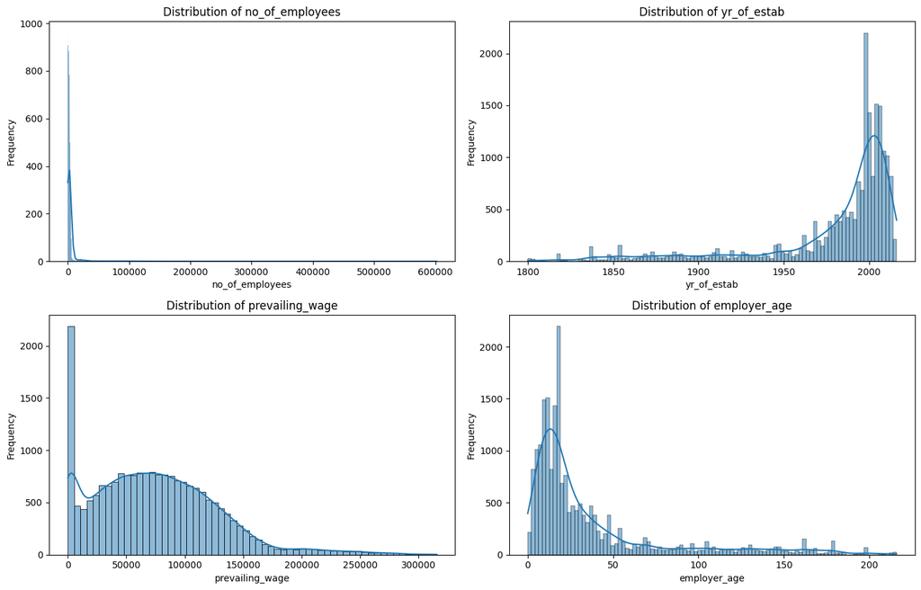

```python
fig, axes = plt.subplots(
    2, 2,
    figsize=(14, 9)
)

for ax, col in zip(
    axes.flatten(),
    numerical_features
):
    sns.histplot(
        X_train[col],
        kde=True,
        ax=ax
    )

    ax.set_title(
        f'Distribution of {col}'
    )
    ax.set_xlabel(col)
    ax.set_ylabel('Frequency')

plt.tight_layout()
plt.show()
```

## 9.4 Optional Standardization Demonstration

```python
from sklearn.preprocessing import StandardScaler

scaler_demo = StandardScaler()

X_train_numeric_scaled = scaler_demo.fit_transform(
    X_train[numerical_features]
)

scaled_numeric_df = pd.DataFrame(
    X_train_numeric_scaled,
    columns=numerical_features,
    index=X_train.index
)

display(scaled_numeric_df.head())
```

|  | no_of_employees | yr_of_estab | prevailing_wage | employer_age |
| --- | --- | --- | --- | --- |
| 15752 | -0.138081 | 0.366301 | -0.760213 | -0.366301 |
| 17311 | -0.122797 | 0.792676 | 1.737551 | -0.792676 |
| 9192 | -0.105211 | -2.073513 | -0.757607 | 2.073513 |
| 23802 | -0.165176 | 0.484739 | -1.004638 | -0.484739 |
| 7867 | -0.229354 | 0.579489 | 1.420794 | -0.579489 |

#### Compare the statistics:

```python
scaled_numeric_df.describe().T
```

|  | count | mean | std | min | 25% | 50% | 75% | max |
| --- | --- | --- | --- | --- | --- | --- | --- | --- |
| no_of_employees | 20355.0 | 1.151948e-17 | 1.000025 | -0.246809 | -0.202910 | -0.155797 | -0.094920 | 25.895575 |
| yr_of_estab | 20384.0 | -6.344132e-16 | 1.000025 | -4.252764 | -0.083762 | 0.413676 | 0.603176 | 0.863739 |
| prevailing_wage | 20384.0 | -7.215578e-17 | 1.000025 | -1.408666 | -0.763592 | -0.077847 | 0.627769 | 4.557363 |
| employer_age | 20384.0 | -4.252660e-17 | 1.000025 | -0.863739 | -0.603176 | -0.413676 | 0.083762 | 4.252764 |

## 9.5 Scaling Decision

Although the numerical variables have different ranges, scaling is not necessary for the primary classification algorithms selected for this project.

Decision Tree and tree-based ensemble methods make decisions using feature thresholds rather than Euclidean distances or gradient magnitudes. Consequently, transforming a feature from its original scale to a standardized scale generally does not change the ordering of observations or the threshold-based splitting logic.

Therefore:

- Numerical variables will remain in their processed numerical form.
- Categorical variables will remain One-Hot encoded.
- No StandardScaler transformation will be applied to the primary modeling datasets.
- The same preprocessing logic will be maintained consistently across the original, oversampled, and undersampled experiments.

This approach avoids unnecessary preprocessing while remaining appropriate for the selected model families.

## 9.6 Final Scaling Validation

```python
print("=" * 65)
print("SCALING DECISION")
print("=" * 65)

print("Required model families:")
print("1. Decision Tree")
print("2. Bagging")
print("3. Random Forest")
print("4. AdaBoost")
print("5. Gradient Boosting / XGBoost")

print("\nScaling required for these models: NO")

print("\nReason:")
print(
    "The selected models are tree-based algorithms and "
    "are generally insensitive to feature scale."
)

print("\n✓ Numerical features will remain unscaled.")
print("✓ Categorical variables are One-Hot encoded.")
print("✓ Preprocessing remains leakage-safe.")
```

```
=================================================================
SCALING DECISION
=================================================================
Required model families:
1. Decision Tree
2. Bagging
3. Random Forest
4. AdaBoost
5. Gradient Boosting / XGBoost

Scaling required for these models: NO

Reason:
The selected models are tree-based algorithms and are generally insensitive to feature scale.

✓ Numerical features will remain unscaled.
✓ Categorical variables are One-Hot encoded.
✓ Preprocessing remains leakage-safe.
```

## 9.8 Scaling Conclusion

Feature scaling was evaluated as part of the preprocessing workflow. Although the numerical predictors have different ranges, scaling is not required for the tree-based classification algorithms selected for this project.

Therefore, the numerical variables will remain in their processed form without standardization. This decision is based on the characteristics of the selected algorithms rather than an assumption that scaling is unnecessary for all machine learning models.

The processed dataset is now ready for the three required modeling scenarios:

1. Original Training Data
2. Oversampled Training Data
3. Undersampled Training Data

The test dataset remains untouched and will be used only for final model evaluation.

# 10. Original Data — Model Building

## 10.1 Modeling Strategy

We'll use these five models:

- Decision Tree
- Bagging Classifier
- Random Forest
- AdaBoost
- Gradient Boosting

## 10.2 Model Evaluation Metric

The EasyVisa dataset contains an imbalanced target variable, so accuracy alone may not provide a reliable assessment of model performance.

The primary metric considered in this project is **Recall for the Certified class**, because the business objective is to identify visa applications that have a higher likelihood of certification.

However, model selection will not be based on recall alone. Precision, F1-score, ROC-AUC, accuracy, and the confusion matrix will also be examined to understand the trade-off between correctly identifying Certified applications and generating false positives.

The positive class is defined as:

**Certified = 1**

and:

**Denied = 0**

## 10.3 Prepare Original Training Data

```python
# Original training data
X_train_original = X_train_processed.copy()
y_train_original = y_train_encoded.copy()

print("Original training data shape:")
print("X:", X_train_original.shape)
print("y:", y_train_original.shape)

print("\nClass distribution:")
print(
    pd.Series(y_train_original)
    .value_counts()
    .sort_index()
)
```

```
Original training data shape:
X: (20384, 29)
y: (20384,)

Class distribution:
0     6770
1    13614
Name: count, dtype: int64
```

#### Percentage distribution:

```python
original_class_distribution = (
    pd.Series(y_train_original)
    .value_counts(normalize=True)
    .sort_index() * 100
)

original_class_distribution.index = [
    'Denied (0)',
    'Certified (1)'
]

display(
    original_class_distribution
    .to_frame('Percentage')
    .round(2)
)
```

|  | Percentage |
| --- | --- |
| Denied (0) | 33.21 |
| Certified (1) | 66.79 |

## 10.4 Import Required Models

```python
from sklearn.tree import DecisionTreeClassifier
from sklearn.ensemble import (
    BaggingClassifier,
    RandomForestClassifier,
    AdaBoostClassifier,
    GradientBoostingClassifier
)

from sklearn.metrics import (
    accuracy_score,
    precision_score,
    recall_score,
    f1_score,
    roc_auc_score,
    confusion_matrix,
    classification_report
)
```

## 10.5 Define the Five Models

```python
models_original = {

    'Decision Tree': DecisionTreeClassifier(
        random_state=42
    ),

    'Bagging': BaggingClassifier(
        random_state=42,
        n_estimators=100
    ),

    'Random Forest': RandomForestClassifier(
        random_state=42,
        n_estimators=100,
        n_jobs=-1
    ),

    'AdaBoost': AdaBoostClassifier(
        random_state=42,
        n_estimators=100
    ),

    'Gradient Boosting': GradientBoostingClassifier(
        random_state=42,
        n_estimators=100
    )
}

print("Models to be evaluated:")
for model_name in models_original:
    print("-", model_name)
```

```
Models to be evaluated:
- Decision Tree
- Bagging
- Random Forest
- AdaBoost
- Gradient Boosting
```

## 10.6 Create a Model Evaluation Function

```python
def evaluate_model(model, X_train, y_train, X_test, y_test):

    # Train model
    model.fit(X_train, y_train)

    # Predictions
    y_pred = model.predict(X_test)

    # Probability predictions
    if hasattr(model, "predict_proba"):
        y_prob = model.predict_proba(X_test)[:, 1]
    else:
        y_prob = None

    # Metrics
    accuracy = accuracy_score(y_test, y_pred)
    precision = precision_score(
        y_test,
        y_pred,
        pos_label=1,
        zero_division=0
    )
    recall = recall_score(
        y_test,
        y_pred,
        pos_label=1,
        zero_division=0
    )
    f1 = f1_score(
        y_test,
        y_pred,
        pos_label=1,
        zero_division=0
    )

    roc_auc = (
        roc_auc_score(y_test, y_prob)
        if y_prob is not None
        else np.nan
    )

    return {
        'Model': model.__class__.__name__,
        'Accuracy': accuracy,
        'Precision': precision,
        'Recall': recall,
        'F1-Score': f1,
        'ROC-AUC': roc_auc,
        'Predictions': y_pred,
        'Model Object': model
    }
```

## 10.7 Train and Evaluate All Five Models

```python
original_results = []

for model_name, model in models_original.items():

    print(f"Training {model_name}...")

    result = evaluate_model(
        model,
        X_train_original,
        y_train_original,
        X_test_processed,
        y_test_encoded
    )

    result['Model'] = model_name

    original_results.append(result)

print("\nAll five models have been trained and evaluated.")
```

```
Training Decision Tree...
Training Bagging...
Training Random Forest...
Training AdaBoost...
Training Gradient Boosting...

All five models have been trained and evaluated.
```

## 10.8 Create Model Comparison Table

```python
original_results_df = pd.DataFrame(original_results)

original_comparison = (
    original_results_df[
        [
            'Model',
            'Accuracy',
            'Precision',
            'Recall',
            'F1-Score',
            'ROC-AUC'
        ]
    ]
    .sort_values(
        by='Recall',
        ascending=False
    )
    .reset_index(drop=True)
)

display(
    original_comparison.style.format({
        'Accuracy': '{:.4f}',
        'Precision': '{:.4f}',
        'Recall': '{:.4f}',
        'F1-Score': '{:.4f}',
        'ROC-AUC': '{:.4f}'
    })
)
```

|  | Model | Accuracy | Precision | Recall | F1-Score | ROC-AUC |
| --- | --- | --- | --- | --- | --- | --- |
| 0 | AdaBoost | 0.7329 | 0.7576 | 0.8825 | 0.8153 | 0.7672 |
| 1 | Gradient Boosting | 0.7473 | 0.7774 | 0.8710 | 0.8216 | 0.7776 |
| 2 | Random Forest | 0.7194 | 0.7681 | 0.8308 | 0.7982 | 0.7502 |
| 3 | Bagging | 0.7137 | 0.7623 | 0.8302 | 0.7948 | 0.7445 |
| 4 | Decision Tree | 0.6464 | 0.7388 | 0.7280 | 0.7334 | 0.6051 |

## 10.9 Visual Model Comparison

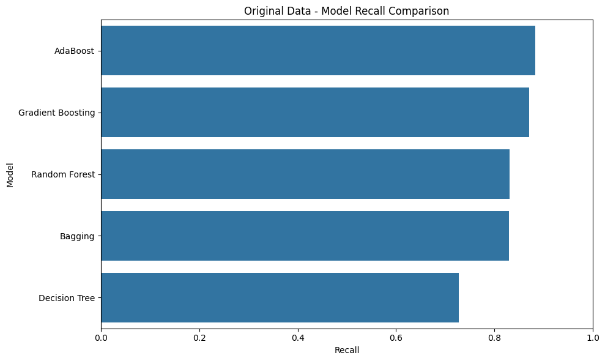

```python
plt.figure(figsize=(10, 6))

sns.barplot(
    data=original_comparison,
    x='Recall',
    y='Model'
)

plt.title('Original Data - Model Recall Comparison')
plt.xlabel('Recall')
plt.ylabel('Model')

plt.xlim(0, 1)

plt.tight_layout()
plt.show()
```

#### F1-Score

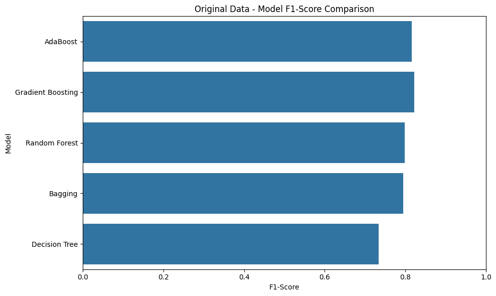

```python
plt.figure(figsize=(10, 6))

sns.barplot(
    data=original_comparison,
    x='F1-Score',
    y='Model'
)

plt.title('Original Data - Model F1-Score Comparison')
plt.xlabel('F1-Score')
plt.ylabel('Model')

plt.xlim(0, 1)

plt.tight_layout()
plt.show()
```

#### ROC-AUC

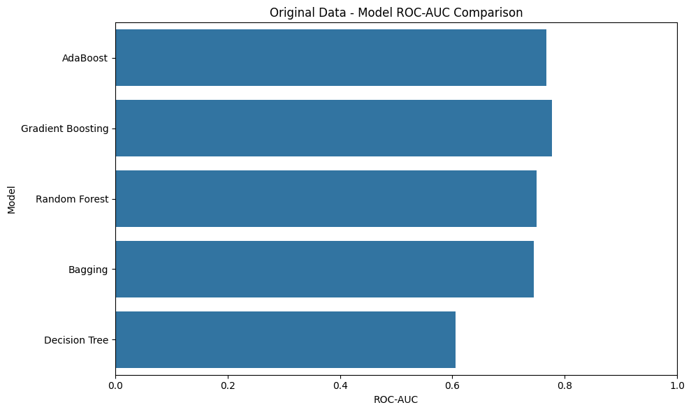

```python
plt.figure(figsize=(10, 6))

sns.barplot(
    data=original_comparison,
    x='ROC-AUC',
    y='Model'
)

plt.title('Original Data - Model ROC-AUC Comparison')
plt.xlabel('ROC-AUC')
plt.ylabel('Model')

plt.xlim(0, 1)

plt.tight_layout()
plt.show()
```

## 10.10 Confusion Matrix for Each Model

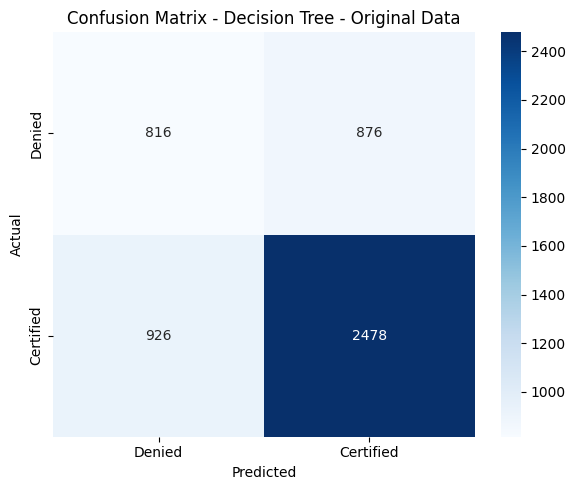

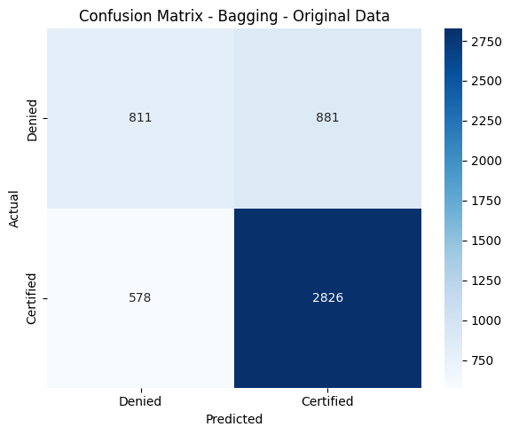

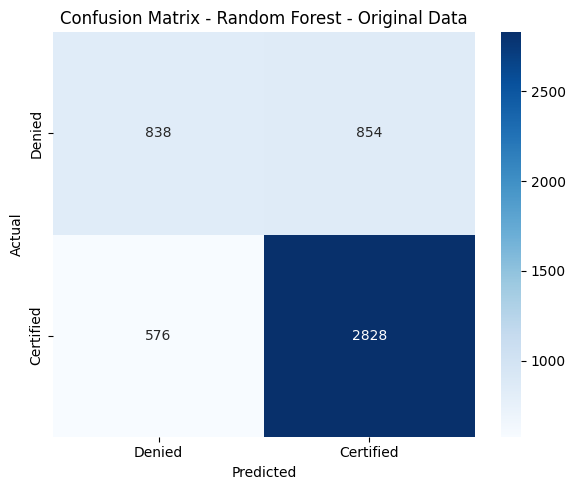

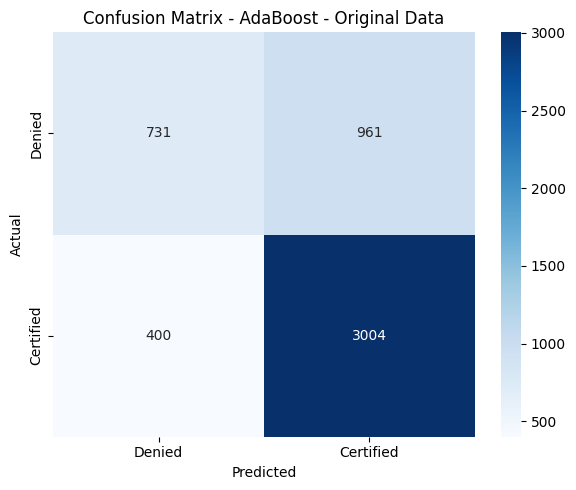

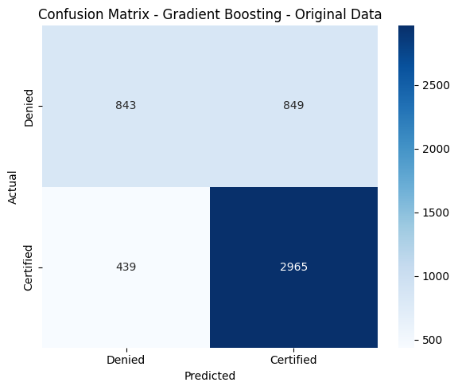

```python
for result in original_results:

    model_name = result['Model']
    y_pred = result['Predictions']

    cm = confusion_matrix(
        y_test_encoded,
        y_pred
    )

    plt.figure(figsize=(6, 5))

    sns.heatmap(
        cm,
        annot=True,
        fmt='d',
        cmap='Blues',
        xticklabels=['Denied', 'Certified'],
        yticklabels=['Denied', 'Certified']
    )

    plt.title(
        f'Confusion Matrix - {model_name} - Original Data'
    )

    plt.xlabel('Predicted')
    plt.ylabel('Actual')

    plt.tight_layout()
    plt.show()
```

## 10.11 Classification Report for Each Model

```python
for result in original_results:

    model_name = result['Model']

    print("=" * 70)
    print(f"Classification Report - {model_name}")
    print("=" * 70)

    print(
        classification_report(
            y_test_encoded,
            result['Predictions'],
            target_names=['Denied', 'Certified'],
            digits=4,
            zero_division=0
        )
    )
```

```
======================================================================
Classification Report - Decision Tree
======================================================================
              precision    recall  f1-score   support

      Denied     0.4684    0.4823    0.4752      1692
   Certified     0.7388    0.7280    0.7334      3404

    accuracy                         0.6464      5096
   macro avg     0.6036    0.6051    0.6043      5096
weighted avg     0.6490    0.6464    0.6477      5096

======================================================================
Classification Report - Bagging
======================================================================
              precision    recall  f1-score   support

      Denied     0.5839    0.4793    0.5265      1692
   Certified     0.7623    0.8302    0.7948      3404

    accuracy                         0.7137      5096
   macro avg     0.6731    0.6548    0.6606      5096
weighted avg     0.7031    0.7137    0.7057      5096

======================================================================
Classification Report - Random Forest
======================================================================
              precision    recall  f1-score   support

      Denied     0.5926    0.4953    0.5396      1692
   Certified     0.7681    0.8308    0.7982      3404

    accuracy                         0.7194      5096
   macro avg     0.6804    0.6630    0.6689      5096
weighted avg     0.7098    0.7194    0.7123      5096

======================================================================
Classification Report - AdaBoost
======================================================================
              precision    recall  f1-score   support

      Denied     0.6463    0.4320    0.5179      1692
   Certified     0.7576    0.8825    0.8153      3404

    accuracy                         0.7329      5096
   macro avg     0.7020    0.6573    0.6666      5096
weighted avg     0.7207    0.7329    0.7166      5096

======================================================================
Classification Report - Gradient Boosting
======================================================================
              precision    recall  f1-score   support

      Denied     0.6576    0.4982    0.5669      1692
   Certified     0.7774    0.8710    0.8216      3404

    accuracy                         0.7473      5096
   macro avg     0.7175    0.6846    0.6942      5096
weighted avg     0.7376    0.7473    0.7370      5096
```

## 10.12 Identify Best Original Model by Recall

```python
best_original_recall = original_comparison.iloc[
    original_comparison['Recall'].idxmax()
]

print("Best model based on Recall:")
print(best_original_recall)
```

```
Best model based on Recall:
Model        AdaBoost
Accuracy     0.732928
Precision    0.757629
Recall       0.882491
F1-Score     0.815307
ROC-AUC      0.767246
Name: 0, dtype: object
```

## 10.13 Identify Best Original Model by F1-Score

```python
best_original_f1 = original_comparison.iloc[
    original_comparison['F1-Score'].idxmax()
]

print("Best model based on F1-Score:")
print(best_original_f1)
```

```
Best model based on F1-Score:
Model        Gradient Boosting
Accuracy              0.747253
Precision             0.777399
Recall                0.871034
F1-Score              0.821557
ROC-AUC               0.777587
Name: 1, dtype: object
```

## 10.14 Identify Best Original Model by ROC-AUC

```python
best_original_auc = original_comparison.iloc[
    original_comparison['ROC-AUC'].idxmax()
]

print("Best model based on ROC-AUC:")
print(best_original_auc)
```

```
Best model based on ROC-AUC:
Model        Gradient Boosting
Accuracy              0.747253
Precision             0.777399
Recall                0.871034
F1-Score              0.821557
ROC-AUC               0.777587
Name: 1, dtype: object
```

## 10.15 Model Performance Analysis

### Decision Tree

The Decision Tree model achieved an accuracy of **0.6464**, precision of **0.7388**, recall of **0.7280**, F1-score of **0.7334**, and ROC-AUC of **0.6051**.

The model provides a relatively interpretable baseline because its decision-making structure can be represented through a sequence of feature-based splits. However, its performance should be compared with the ensemble models to determine whether combining multiple trees improves generalization.

### Bagging

The Bagging model achieved an accuracy of **0.7137**, precision of **0.7623**, recall of **0.8302**, F1-score of **0.7948**, and ROC-AUC of **0.7445**.

Bagging combines multiple base estimators trained on different bootstrap samples. Its performance indicates whether ensemble averaging provides an improvement over a single Decision Tree.

### Random Forest

The Random Forest model achieved an accuracy of **0.7194**, precision of **0.7681**, recall of **0.8308**, F1-score of **0.7982**, and ROC-AUC of **0.7502**.

Random Forest introduces additional randomness through feature selection at each split and combines multiple decision trees. Its performance is therefore compared with both the single Decision Tree and Bagging model.

### AdaBoost

The AdaBoost model achieved an accuracy of **0.7329**, precision of **0.7576**, recall of **0.8825**, F1-score of **0.8153**, and ROC-AUC of **0.7672**.

AdaBoost sequentially focuses on observations that are difficult to classify. Its results indicate whether this boosting strategy improves identification of the Certified class.

### Gradient Boosting

The Gradient Boosting model achieved an accuracy of **0.7473**, precision of **0.7774**, recall of **0.8710**, F1-score of **0.8216**, and ROC-AUC of **0.7776**.

Gradient Boosting builds trees sequentially, with each subsequent tree attempting to correct errors made by previous trees. Its performance is compared against the other ensemble approaches.

## 10.16 Original Data — Overall Findings

The five required classification models were trained and evaluated using the original training data without any class-balancing technique.

The differences indicate that no single metric should be considered in isolation. Recall is particularly relevant to the business objective, but precision, F1-score, ROC-AUC, and the confusion matrix are also considered when assessing model quality.

The original-data results will serve as the baseline against which the oversampled and undersampled experiments will be compared.

# 11. Original Data — Model Comparison

The five classification models were trained using the original training dataset without applying any oversampling or undersampling technique.

The models are compared using Accuracy, Precision, Recall, F1-Score, and ROC-AUC.

Since the target variable is imbalanced, accuracy alone is not considered sufficient for model selection. Recall for the Certified class is given particular importance because incorrectly classifying a potentially certifiable application as Denied represents an important business risk.

F1-Score and ROC-AUC are also considered to provide a balanced assessment of model performance.

## 11.2 Generate the Comparison Table

```python
# Original Data - Model Comparison

original_comparison = (
    original_results_df[
        [
            'Model',
            'Accuracy',
            'Precision',
            'Recall',
            'F1-Score',
            'ROC-AUC'
        ]
    ]
    .sort_values(
        by='Recall',
        ascending=False
    )
    .reset_index(drop=True)
)

display(
    original_comparison.style.format({
        'Accuracy': '{:.4f}',
        'Precision': '{:.4f}',
        'Recall': '{:.4f}',
        'F1-Score': '{:.4f}',
        'ROC-AUC': '{:.4f}'
    })
)
```

|  | Model | Accuracy | Precision | Recall | F1-Score | ROC-AUC |
| --- | --- | --- | --- | --- | --- | --- |
| 0 | AdaBoost | 0.7329 | 0.7576 | 0.8825 | 0.8153 | 0.7672 |
| 1 | Gradient Boosting | 0.7473 | 0.7774 | 0.8710 | 0.8216 | 0.7776 |
| 2 | Random Forest | 0.7194 | 0.7681 | 0.8308 | 0.7982 | 0.7502 |
| 3 | Bagging | 0.7137 | 0.7623 | 0.8302 | 0.7948 | 0.7445 |
| 4 | Decision Tree | 0.6464 | 0.7388 | 0.7280 | 0.7334 | 0.6051 |

## 11.3 Identify Best Model for Each Metric

```python
metrics = [
    'Accuracy',
    'Precision',
    'Recall',
    'F1-Score',
    'ROC-AUC'
]

best_models_by_metric = []

for metric in metrics:
    idx = original_comparison[metric].idxmax()

    best_models_by_metric.append({
        'Metric': metric,
        'Best Model': original_comparison.loc[idx, 'Model'],
        'Score': original_comparison.loc[idx, metric]
    })

best_models_by_metric_df = pd.DataFrame(
    best_models_by_metric
)

display(
    best_models_by_metric_df.style.format({
        'Score': '{:.4f}'
    })
)
```

|  | Metric | Best Model | Score |
| --- | --- | --- | --- |
| 0 | Accuracy | Gradient Boosting | 0.7473 |
| 1 | Precision | Gradient Boosting | 0.7774 |
| 2 | Recall | AdaBoost | 0.8825 |
| 3 | F1-Score | Gradient Boosting | 0.8216 |
| 4 | ROC-AUC | Gradient Boosting | 0.7776 |

## 11.4 Rank the Models

```python
ranking_df = original_comparison.copy()

for metric in metrics:
    ranking_df[f'{metric} Rank'] = (
        ranking_df[metric]
        .rank(
            ascending=False,
            method='min'
        )
        .astype(int)
    )

display(ranking_df)
```

|  | Model | Accuracy | Precision | Recall | F1-Score | ROC-AUC | Accuracy Rank | Precision Rank | Recall Rank | F1-Score Rank | ROC-AUC Rank |
| --- | --- | --- | --- | --- | --- | --- | --- | --- | --- | --- | --- |
| 0 | AdaBoost | 0.732928 | 0.757629 | 0.882491 | 0.815307 | 0.767246 | 2 | 4 | 1 | 2 | 2 |
| 1 | Gradient Boosting | 0.747253 | 0.777399 | 0.871034 | 0.821557 | 0.777587 | 1 | 1 | 2 | 1 | 1 |
| 2 | Random Forest | 0.719388 | 0.768061 | 0.830787 | 0.798194 | 0.750215 | 3 | 2 | 3 | 3 | 3 |
| 3 | Bagging | 0.713697 | 0.762342 | 0.830200 | 0.794825 | 0.744463 | 4 | 3 | 4 | 4 | 4 |
| 4 | Decision Tree | 0.646389 | 0.738819 | 0.727967 | 0.733353 | 0.605118 | 5 | 5 | 5 | 5 | 5 |

## 11.5 Visual Comparison

### Accuracy

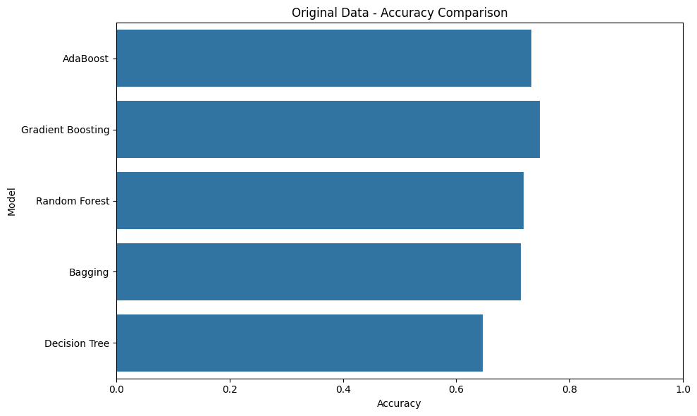

```python
plt.figure(figsize=(10, 6))

sns.barplot(
    data=original_comparison,
    x='Accuracy',
    y='Model'
)

plt.title('Original Data - Accuracy Comparison')
plt.xlabel('Accuracy')
plt.ylabel('Model')
plt.xlim(0, 1)

plt.tight_layout()
plt.show()
```

### Precision

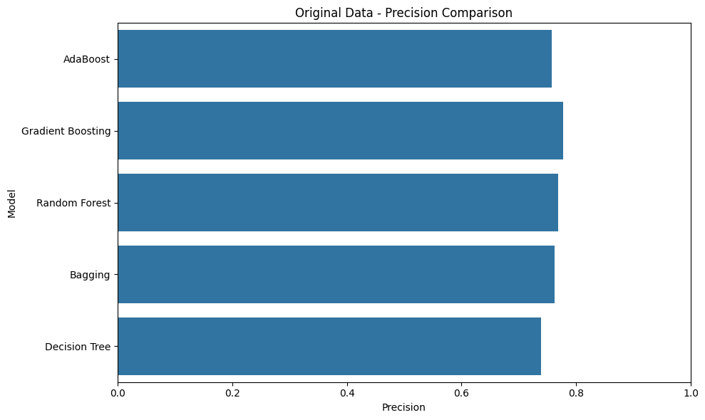

```python
plt.figure(figsize=(10, 6))

sns.barplot(
    data=original_comparison,
    x='Precision',
    y='Model'
)

plt.title('Original Data - Precision Comparison')
plt.xlabel('Precision')
plt.ylabel('Model')
plt.xlim(0, 1)

plt.tight_layout()
plt.show()
```

### Recall

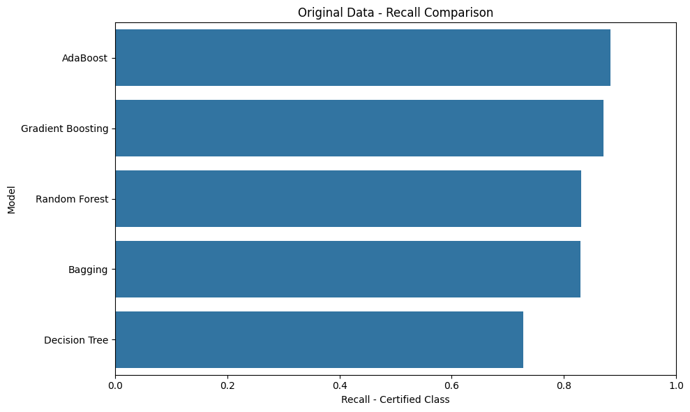

```python
plt.figure(figsize=(10, 6))

sns.barplot(
    data=original_comparison,
    x='Recall',
    y='Model'
)

plt.title('Original Data - Recall Comparison')
plt.xlabel('Recall - Certified Class')
plt.ylabel('Model')
plt.xlim(0, 1)

plt.tight_layout()
plt.show()
```

### F1-Score

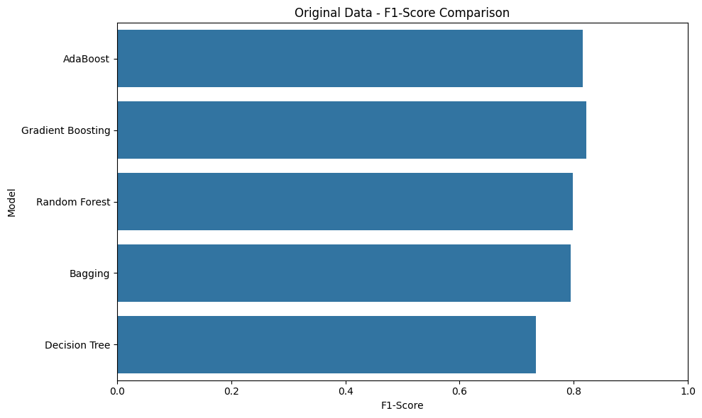

```python
plt.figure(figsize=(10, 6))

sns.barplot(
    data=original_comparison,
    x='F1-Score',
    y='Model'
)

plt.title('Original Data - F1-Score Comparison')
plt.xlabel('F1-Score')
plt.ylabel('Model')
plt.xlim(0, 1)

plt.tight_layout()
plt.show()
```

### ROC-AUC

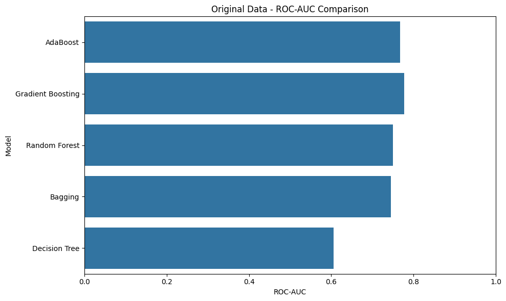

```python
plt.figure(figsize=(10, 6))

sns.barplot(
    data=original_comparison,
    x='ROC-AUC',
    y='Model'
)

plt.title('Original Data - ROC-AUC Comparison')
plt.xlabel('ROC-AUC')
plt.ylabel('Model')
plt.xlim(0, 1)

plt.tight_layout()
plt.show()
```

## 11.6 Overall Model Comparison Visualization

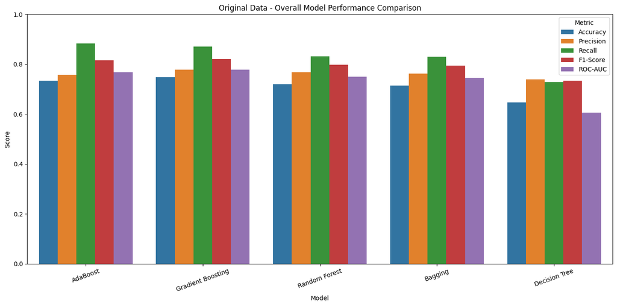

```python
comparison_melted = original_comparison.melt(
    id_vars='Model',
    value_vars=[
        'Accuracy',
        'Precision',
        'Recall',
        'F1-Score',
        'ROC-AUC'
    ],
    var_name='Metric',
    value_name='Score'
)

plt.figure(figsize=(14, 7))

sns.barplot(
    data=comparison_melted,
    x='Model',
    y='Score',
    hue='Metric'
)

plt.title('Original Data - Overall Model Performance Comparison')
plt.xlabel('Model')
plt.ylabel('Score')
plt.ylim(0, 1)

plt.xticks(rotation=20)
plt.legend(title='Metric')

plt.tight_layout()
plt.show()
```

## 11.7 Best Model Based on Recall

```python
best_recall_row = original_comparison.loc[
    original_comparison['Recall'].idxmax()
]

print(
    f"Best model based on Recall: "
    f"{best_recall_row['Model']}"
)

print(
    f"Recall: "
    f"{best_recall_row['Recall']:.4f}"
)
```

```
Best model based on Recall: AdaBoost
Recall: 0.8825
```

## 11.8 Best Model Based on F1-Score

```python
best_f1_row = original_comparison.loc[
    original_comparison['F1-Score'].idxmax()
]

print(
    f"Best model based on F1-Score: "
    f"{best_f1_row['Model']}"
)

print(
    f"F1-Score: "
    f"{best_f1_row['F1-Score']:.4f}"
)
```

```
Best model based on F1-Score: Gradient Boosting
F1-Score: 0.8216
```

## 11.9 Best Model Based on ROC-AUC

```python
best_auc_row = original_comparison.loc[
    original_comparison['ROC-AUC'].idxmax()
]

print(
    f"Best model based on ROC-AUC: "
    f"{best_auc_row['Model']}"
)

print(
    f"ROC-AUC: "
    f"{best_auc_row['ROC-AUC']:.4f}"
)
```

```
Best model based on ROC-AUC: Gradient Boosting
ROC-AUC: 0.7776
```

## 11.10 Model-by-Model Comparison

```python
for _, row in original_comparison.iterrows():

    print(f"\n{row['Model']}")
    print("-" * 50)
    print(f"Accuracy : {row['Accuracy']:.4f}")
    print(f"Precision: {row['Precision']:.4f}")
    print(f"Recall   : {row['Recall']:.4f}")
    print(f"F1-Score : {row['F1-Score']:.4f}")
    print(f"ROC-AUC  : {row['ROC-AUC']:.4f}")
```

```
AdaBoost
--------------------------------------------------
Accuracy : 0.7329
Precision: 0.7576
Recall   : 0.8825
F1-Score : 0.8153
ROC-AUC  : 0.7672

Gradient Boosting
--------------------------------------------------
Accuracy : 0.7473
Precision: 0.7774
Recall   : 0.8710
F1-Score : 0.8216
ROC-AUC  : 0.7776

Random Forest
--------------------------------------------------
Accuracy : 0.7194
Precision: 0.7681
Recall   : 0.8308
F1-Score : 0.7982
ROC-AUC  : 0.7502

Bagging
--------------------------------------------------
Accuracy : 0.7137
Precision: 0.7623
Recall   : 0.8302
F1-Score : 0.7948
ROC-AUC  : 0.7445

Decision Tree
--------------------------------------------------
Accuracy : 0.6464
Precision: 0.7388
Recall   : 0.7280
F1-Score : 0.7334
ROC-AUC  : 0.6051
```

## 11.11 Model Comparison — Interpretation

### Decision Tree

The Decision Tree model achieved an accuracy of **0.6464**, precision of **0.7388**, recall of **0.7280**, F1-score of **0.7334**, and ROC-AUC of **0.6051**.

The Decision Tree provides an interpretable baseline model and establishes the performance level of a single-tree approach. Among the five models, it recorded the lowest accuracy, recall, F1-score, and ROC-AUC, indicating comparatively weaker predictive performance on the original dataset.

### Bagging

The Bagging model achieved an accuracy of **0.7137**, precision of **0.7623**, recall of **0.8302**, F1-score of **0.7948**, and ROC-AUC of **0.7445**.

Compared with the single Decision Tree, Bagging substantially improved recall, F1-score, and ROC-AUC. This indicates that aggregating multiple decision trees provided better generalization than using a single Decision Tree on the original dataset.

### Random Forest

The Random Forest model achieved an accuracy of **0.7194**, precision of **0.7681**, recall of **0.8308**, F1-score of **0.7982**, and ROC-AUC of **0.7502**.

Random Forest performed slightly better than Bagging across all reported metrics. Its ensemble structure and randomized feature selection allowed it to capture nonlinear relationships while reducing the instability associated with an individual decision tree.

### AdaBoost

The AdaBoost model achieved an accuracy of **0.7329**, precision of **0.7576**, recall of **0.8825**, F1-score of **0.8153**, and ROC-AUC of **0.7672**.

However, its precision is slightly lower than that of Gradient Boosting, indicating a trade-off between identifying more Certified applications and avoiding false-positive Certified predictions.

### Gradient Boosting

The Gradient Boosting model achieved an accuracy of **0.7473**, precision of **0.7774**, recall of **0.8710**, F1-score of **0.8216**, and ROC-AUC of **0.7776**.

Gradient Boosting achieved the **highest accuracy, precision, F1-score, and ROC-AUC** among the five models. Although its recall of 0.8710 was slightly lower than AdaBoost's 0.8825, it provided a better overall balance between precision and recall.

Its F1-score of 0.8216 was the highest among the evaluated models, indicating the strongest balance between correctly identifying Certified applications and maintaining precision on the original dataset.

## 11.12 Original Data — Key Findings

The five classification models demonstrate different performance characteristics across accuracy, precision, recall, F1-score, and ROC-AUC.

- **Highest Recall:** AdaBoost, with a recall of **0.8825**.
- **Highest F1-score:** Gradient Boosting, with an F1-score of **0.8216**.
- **Highest ROC-AUC:** Gradient Boosting, with a ROC-AUC of **0.7776**.
- **Highest Precision:** Gradient Boosting, with a precision of **0.7774**.
- **Highest Accuracy:** Gradient Boosting, with an accuracy of **0.7473**.

AdaBoost provides the highest recall, meaning it identifies the largest proportion of Certified applications among the five models. This is valuable from the perspective of minimizing potentially certifiable applications being classified as Denied.

However, Gradient Boosting provides the strongest overall performance across the other major metrics. It achieves the highest accuracy, precision, F1-score, and ROC-AUC while maintaining a high recall of **0.8710**.

Therefore, based on the original-data experiment, **Gradient Boosting demonstrates the strongest overall performance**, while **AdaBoost demonstrates the strongest recall for the Certified class**.

However, this does not represent the final model selection. The original-data results are treated as the baseline and will be compared against the results obtained using oversampling and undersampling. The strongest models from these experiments will subsequently be considered for hyperparameter tuning.

The final model will only be selected after comparing the tuned models and evaluating the selected model on the untouched test set.

# 12. Oversampling

## 12.1 Why Oversampling?

The EasyVisa dataset contains an imbalanced target variable, where the number of Certified and Denied cases is not equal.

When a classification model is trained on an imbalanced dataset, it may become biased toward the majority class. This can result in poor identification of the minority class.

To address this issue, oversampling is applied to the training data.

Random oversampling increases the representation of the minority class by randomly replicating minority-class observations until the desired class distribution is achieved.

Oversampling is performed only on the training dataset. The test dataset remains completely untouched and retains its original class distribution.

This ensures that model evaluation represents performance on the naturally occurring test population.

## 12.2 Check Original Training Class Distribution

```python
from collections import Counter

print("Original training class distribution:")
print(
    Counter(y_train_original)
)
```

```
Original training class distribution:
Counter({np.int64(1): 13614, np.int64(0): 6770})
```

#### Percentage:

```python
original_counts = pd.Series(
    y_train_original
).value_counts().sort_index()

original_percentages = (
    original_counts /
    len(y_train_original) *
    100
).round(2)

original_distribution = pd.DataFrame({
    'Class': ['Denied', 'Certified'],
    'Count': original_counts.values,
    'Percentage': original_percentages.values
})

display(original_distribution)
```

|  | Class | Count | Percentage |
| --- | --- | --- | --- |
| 0 | Denied | 6770 | 33.21 |
| 1 | Certified | 13614 | 66.79 |

## 12.3 Apply Random Oversampling

```python
!pip install -q imbalanced-learn
```

```python
from imblearn.over_sampling import RandomOverSampler
```

```python
oversampler = RandomOverSampler(
    random_state=42
)

X_train_oversampled, y_train_oversampled = oversampler.fit_resample(
    X_train_original,
    y_train_original
)

print("Original training shape:")
print("X:", X_train_original.shape)
print("y:", y_train_original.shape)

print("\nOversampled training shape:")
print("X:", X_train_oversampled.shape)
print("y:", y_train_oversampled.shape)
```

```
Original training shape:
X: (20384, 29)
y: (20384,)

Oversampled training shape:
X: (27228, 29)
y: (27228,)
```

## 12.4 Verify Oversampling

```python
oversampled_counts = pd.Series(
    y_train_oversampled
).value_counts().sort_index()

oversampled_percentages = (
    oversampled_counts /
    len(y_train_oversampled) *
    100
).round(2)

oversampled_distribution = pd.DataFrame({
    'Class': ['Denied', 'Certified'],
    'Count': oversampled_counts.values,
    'Percentage': oversampled_percentages.values
})

display(oversampled_distribution)
```

|  | Class | Count | Percentage |
| --- | --- | --- | --- |
| 0 | Denied | 13614 | 50.0 |
| 1 | Certified | 13614 | 50.0 |

## 12.5 Visualize Before vs After Oversampling

```python
comparison_counts = pd.DataFrame({
    'Original Training':
        pd.Series(y_train_original).value_counts(),
    'Oversampled Training':
        pd.Series(y_train_oversampled).value_counts()
})

comparison_counts.index = [
    'Denied',
    'Certified'
]

display(comparison_counts)
```

|  | Original Training | Oversampled Training |
| --- | --- | --- |
| Denied | 6770 | 13614 |
| Certified | 13614 | 13614 |

#### Visualization

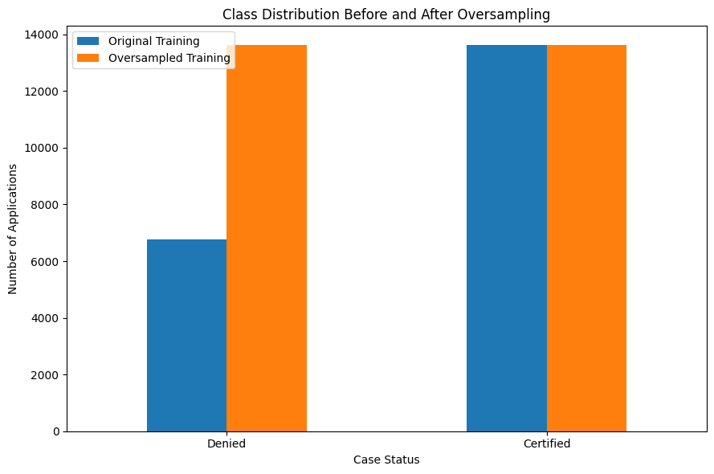

```python
comparison_counts.plot(
    kind='bar',
    figsize=(9, 6)
)

plt.title(
    'Class Distribution Before and After Oversampling'
)
plt.xlabel('Case Status')
plt.ylabel('Number of Applications')
plt.xticks(rotation=0)

plt.tight_layout()
plt.show()
```

## 12.6 Verify Test Data Was Not Modified

```python
print("Test data shape:")
print("X_test:", X_test_processed.shape)
print("y_test:", y_test_encoded.shape)

print("\nTest class distribution:")
print(
    pd.Series(y_test_encoded)
    .value_counts()
    .sort_index()
)
```

```
Test data shape:
X_test: (5096, 29)
y_test: (5096,)

Test class distribution:
0    1692
1    3404
Name: count, dtype: int64
```

## 12.7 Define the Five Models

```python
models_oversampled = {

    'Decision Tree': DecisionTreeClassifier(
        random_state=42
    ),

    'Bagging': BaggingClassifier(
        random_state=42,
        n_estimators=100
    ),

    'Random Forest': RandomForestClassifier(
        random_state=42,
        n_estimators=100,
        n_jobs=-1
    ),

    'AdaBoost': AdaBoostClassifier(
        random_state=42,
        n_estimators=100
    ),

    'Gradient Boosting': GradientBoostingClassifier(
        random_state=42,
        n_estimators=100
    )
}

print("Oversampled-data models:")
for model_name in models_oversampled:
    print("-", model_name)
```

```
Oversampled-data models:
- Decision Tree
- Bagging
- Random Forest
- AdaBoost
- Gradient Boosting
```

## 12.8 Train and Evaluate the Five Models

```python
oversampled_results = []

for model_name, model in models_oversampled.items():

    print(f"Training {model_name}...")

    result = evaluate_model(
        model,
        X_train_oversampled,
        y_train_oversampled,
        X_test_processed,
        y_test_encoded
    )

    result['Model'] = model_name

    oversampled_results.append(result)

print("\nAll five oversampled models have been trained and evaluated.")
```

```
Training Decision Tree...
Training Bagging...
Training Random Forest...
Training AdaBoost...
Training Gradient Boosting...

All five oversampled models have been trained and evaluated.
```

## 12.9 Oversampled Model Comparison

```python
oversampled_results_df = pd.DataFrame(
    oversampled_results
)

oversampled_comparison = (
    oversampled_results_df[
        [
            'Model',
            'Accuracy',
            'Precision',
            'Recall',
            'F1-Score',
            'ROC-AUC'
        ]
    ]
    .sort_values(
        by='Recall',
        ascending=False
    )
    .reset_index(drop=True)
)

display(
    oversampled_comparison.style.format({
        'Accuracy': '{:.4f}',
        'Precision': '{:.4f}',
        'Recall': '{:.4f}',
        'F1-Score': '{:.4f}',
        'ROC-AUC': '{:.4f}'
    })
)
```

|  | Model | Accuracy | Precision | Recall | F1-Score | ROC-AUC |
| --- | --- | --- | --- | --- | --- | --- |
| 0 | Bagging | 0.7041 | 0.7775 | 0.7803 | 0.7789 | 0.7421 |
| 1 | Random Forest | 0.7029 | 0.7781 | 0.7767 | 0.7774 | 0.7461 |
| 2 | Decision Tree | 0.6509 | 0.7416 | 0.7327 | 0.7371 | 0.6095 |
| 3 | Gradient Boosting | 0.7115 | 0.8228 | 0.7241 | 0.7703 | 0.7783 |
| 4 | AdaBoost | 0.6984 | 0.8115 | 0.7145 | 0.7599 | 0.7667 |

## 12.10 Oversampled Model Performance Visualization

#### Recall

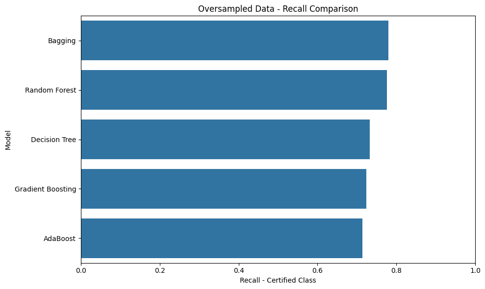

```python
plt.figure(figsize=(10, 6))

sns.barplot(
    data=oversampled_comparison,
    x='Recall',
    y='Model'
)

plt.title(
    'Oversampled Data - Recall Comparison'
)
plt.xlabel('Recall - Certified Class')
plt.ylabel('Model')
plt.xlim(0, 1)

plt.tight_layout()
plt.show()
```

#### F1-Score

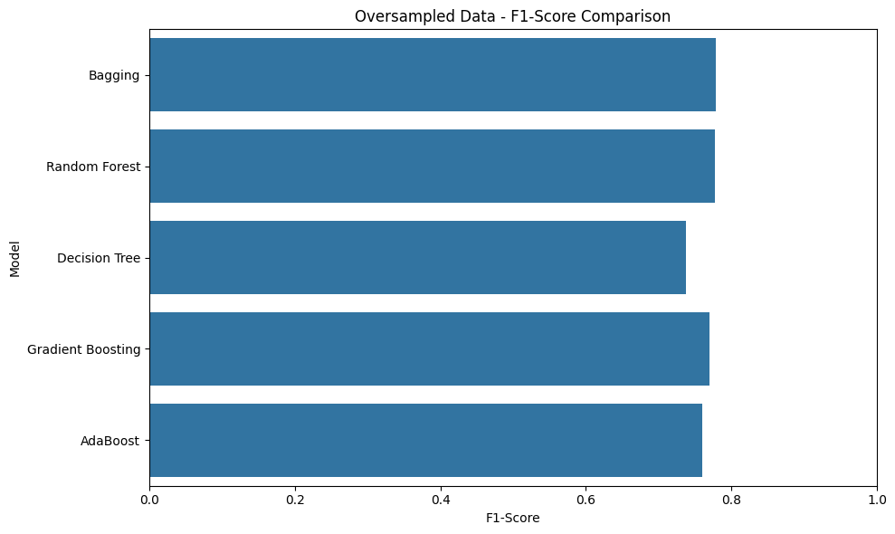

```python
plt.figure(figsize=(10, 6))

sns.barplot(
    data=oversampled_comparison,
    x='F1-Score',
    y='Model'
)

plt.title(
    'Oversampled Data - F1-Score Comparison'
)
plt.xlabel('F1-Score')
plt.ylabel('Model')
plt.xlim(0, 1)

plt.tight_layout()
plt.show()
```

#### ROC-AUC

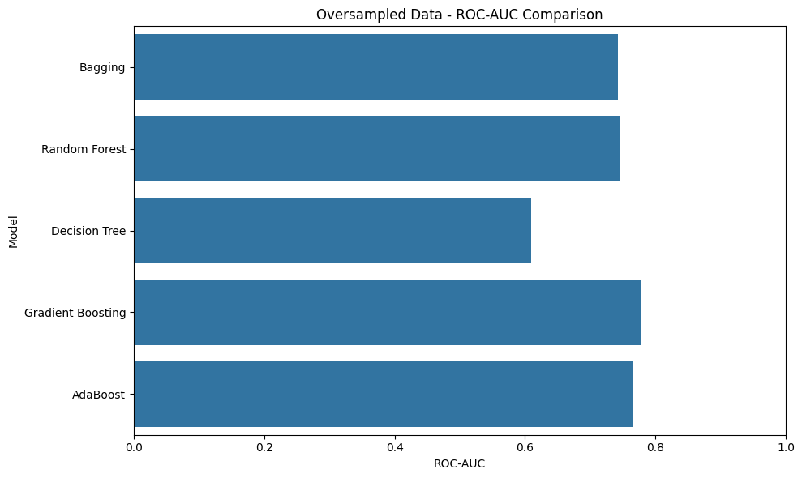

```python
plt.figure(figsize=(10, 6))

sns.barplot(
    data=oversampled_comparison,
    x='ROC-AUC',
    y='Model'
)

plt.title(
    'Oversampled Data - ROC-AUC Comparison'
)
plt.xlabel('ROC-AUC')
plt.ylabel('Model')
plt.xlim(0, 1)

plt.tight_layout()
plt.show()
```

## 12.11 Confusion Matrices

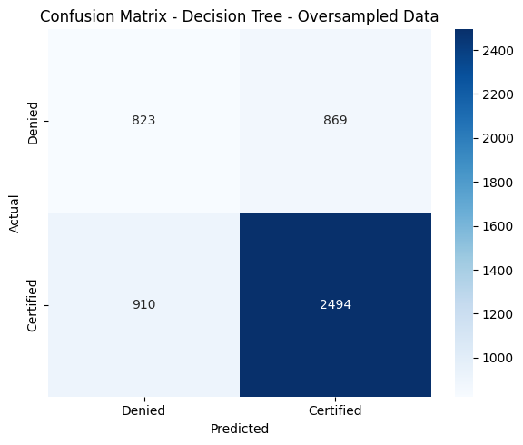

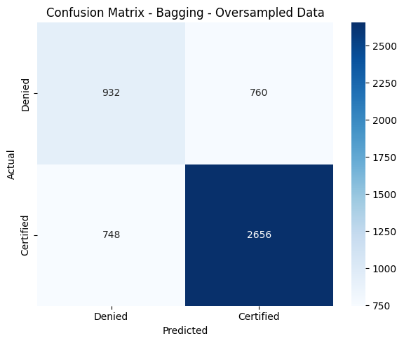

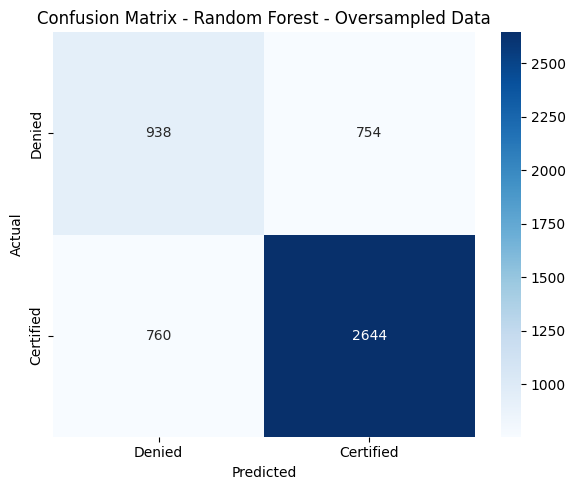

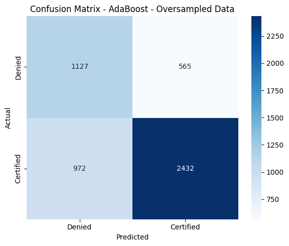

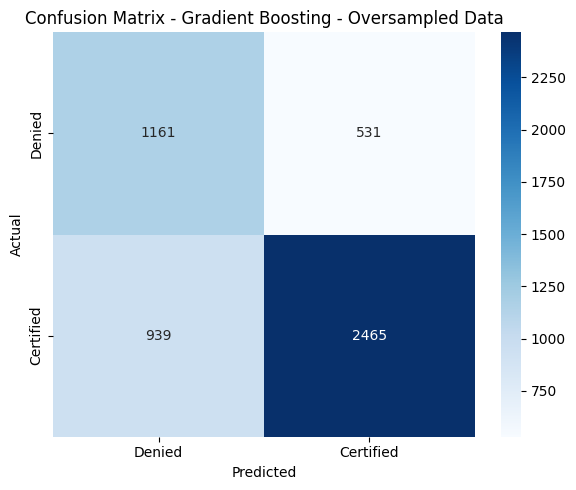

```python
for result in oversampled_results:

    model_name = result['Model']
    y_pred = result['Predictions']

    cm = confusion_matrix(
        y_test_encoded,
        y_pred
    )

    plt.figure(figsize=(6, 5))

    sns.heatmap(
        cm,
        annot=True,
        fmt='d',
        cmap='Blues',
        xticklabels=['Denied', 'Certified'],
        yticklabels=['Denied', 'Certified']
    )

    plt.title(
        f'Confusion Matrix - {model_name} - Oversampled Data'
    )

    plt.xlabel('Predicted')
    plt.ylabel('Actual')

    plt.tight_layout()
    plt.show()
```

## 12.12 Classification Reports

```python
for result in oversampled_results:

    model_name = result['Model']

    print("=" * 70)
    print(
        f"Classification Report - "
        f"{model_name} - Oversampled Data"
    )
    print("=" * 70)

    print(
        classification_report(
            y_test_encoded,
            result['Predictions'],
            target_names=['Denied', 'Certified'],
            digits=4,
            zero_division=0
        )
    )
```

```
======================================================================
Classification Report - Decision Tree - Oversampled Data
======================================================================
              precision    recall  f1-score   support

      Denied     0.4749    0.4864    0.4806      1692
   Certified     0.7416    0.7327    0.7371      3404

    accuracy                         0.6509      5096
   macro avg     0.6082    0.6095    0.6088      5096
weighted avg     0.6530    0.6509    0.6519      5096

======================================================================
Classification Report - Bagging - Oversampled Data
======================================================================
              precision    recall  f1-score   support

      Denied     0.5548    0.5508    0.5528      1692
   Certified     0.7775    0.7803    0.7789      3404

    accuracy                         0.7041      5096
   macro avg     0.6661    0.6655    0.6658      5096
weighted avg     0.7036    0.7041    0.7038      5096

======================================================================
Classification Report - Random Forest - Oversampled Data
======================================================================
              precision    recall  f1-score   support

      Denied     0.5524    0.5544    0.5534      1692
   Certified     0.7781    0.7767    0.7774      3404

    accuracy                         0.7029      5096
   macro avg     0.6653    0.6656    0.6654      5096
weighted avg     0.7032    0.7029    0.7030      5096

======================================================================
Classification Report - AdaBoost - Oversampled Data
======================================================================
              precision    recall  f1-score   support

      Denied     0.5369    0.6661    0.5946      1692
   Certified     0.8115    0.7145    0.7599      3404

    accuracy                         0.6984      5096
   macro avg     0.6742    0.6903    0.6772      5096
weighted avg     0.7203    0.6984    0.7050      5096

======================================================================
Classification Report - Gradient Boosting - Oversampled Data
======================================================================
              precision    recall  f1-score   support

      Denied     0.5529    0.6862    0.6123      1692
   Certified     0.8228    0.7241    0.7703      3404

    accuracy                         0.7115      5096
   macro avg     0.6878    0.7052    0.6913      5096
weighted avg     0.7331    0.7115    0.7179      5096
```

## 12.13 Best Oversampled Model by Recall

```python
best_oversampled_recall = oversampled_comparison.loc[
    oversampled_comparison['Recall'].idxmax()
]

print("Best oversampled model based on Recall:")
display(best_oversampled_recall)
```

```
Best oversampled model based on Recall:
```

|  | 0 |
| --- | --- |
| Model | Bagging |
| Accuracy | 0.704082 |
| Precision | 0.777518 |
| Recall | 0.780259 |
| F1-Score | 0.778886 |
| ROC-AUC | 0.742149 |

**dtype:** object

## 12.14 Best Oversampled Model by F1-Score

```python
best_oversampled_f1 = oversampled_comparison.loc[
    oversampled_comparison['F1-Score'].idxmax()
]

print("Best oversampled model based on F1-Score:")
display(best_oversampled_f1)
```

```
Best oversampled model based on F1-Score:
```

|  | 0 |
| --- | --- |
| Model | Bagging |
| Accuracy | 0.704082 |
| Precision | 0.777518 |
| Recall | 0.780259 |
| F1-Score | 0.778886 |
| ROC-AUC | 0.742149 |

**dtype:** object

## 12.15 Best Oversampled Model by ROC-AUC

```python
best_oversampled_auc = oversampled_comparison.loc[
    oversampled_comparison['ROC-AUC'].idxmax()
]

print("Best oversampled model based on ROC-AUC:")
display(best_oversampled_auc)
```

```
Best oversampled model based on ROC-AUC:
```

|  | 3 |
| --- | --- |
| Model | Gradient Boosting |
| Accuracy | 0.711538 |
| Precision | 0.822764 |
| Recall | 0.724148 |
| F1-Score | 0.770312 |
| ROC-AUC | 0.778252 |

**dtype:** object

## 12.16 Compare Original vs Oversampled

```python
original_for_comparison = original_comparison.copy()
original_for_comparison['Dataset'] = 'Original'

oversampled_for_comparison = oversampled_comparison.copy()
oversampled_for_comparison['Dataset'] = 'Oversampled'

original_vs_oversampled = pd.concat(
    [
        original_for_comparison,
        oversampled_for_comparison
    ],
    ignore_index=True
)

display(
    original_vs_oversampled.style.format({
        'Accuracy': '{:.4f}',
        'Precision': '{:.4f}',
        'Recall': '{:.4f}',
        'F1-Score': '{:.4f}',
        'ROC-AUC': '{:.4f}'
    })
)
```

|  | Model | Accuracy | Precision | Recall | F1-Score | ROC-AUC | Dataset |
| --- | --- | --- | --- | --- | --- | --- | --- |
| 0 | AdaBoost | 0.7329 | 0.7576 | 0.8825 | 0.8153 | 0.7672 | Original |
| 1 | Gradient Boosting | 0.7473 | 0.7774 | 0.8710 | 0.8216 | 0.7776 | Original |
| 2 | Random Forest | 0.7194 | 0.7681 | 0.8308 | 0.7982 | 0.7502 | Original |
| 3 | Bagging | 0.7137 | 0.7623 | 0.8302 | 0.7948 | 0.7445 | Original |
| 4 | Decision Tree | 0.6464 | 0.7388 | 0.7280 | 0.7334 | 0.6051 | Original |
| 5 | Bagging | 0.7041 | 0.7775 | 0.7803 | 0.7789 | 0.7421 | Oversampled |
| 6 | Random Forest | 0.7029 | 0.7781 | 0.7767 | 0.7774 | 0.7461 | Oversampled |
| 7 | Decision Tree | 0.6509 | 0.7416 | 0.7327 | 0.7371 | 0.6095 | Oversampled |
| 8 | Gradient Boosting | 0.7115 | 0.8228 | 0.7241 | 0.7703 | 0.7783 | Oversampled |
| 9 | AdaBoost | 0.6984 | 0.8115 | 0.7145 | 0.7599 | 0.7667 | Oversampled |

## 12.17 Calculate Improvement from Oversampling

```python
metrics_to_compare = [
    'Accuracy',
    'Precision',
    'Recall',
    'F1-Score',
    'ROC-AUC'
]

original_metrics = (
    original_comparison
    .set_index('Model')[metrics_to_compare]
)

oversampled_metrics = (
    oversampled_comparison
    .set_index('Model')[metrics_to_compare]
)

oversampling_change = (
    oversampled_metrics -
    original_metrics
)

display(
    oversampling_change.style.format(
        '{:+.4f}'
    )
)
```

| Model | Accuracy | Precision | Recall | F1-Score | ROC-AUC |
| --- | --- | --- | --- | --- | --- |
| AdaBoost | -0.0345 | +0.0538 | -0.1680 | -0.0554 | -0.0006 |
| Bagging | -0.0096 | +0.0152 | -0.0499 | -0.0159 | -0.0023 |
| Decision Tree | +0.0045 | +0.0028 | +0.0047 | +0.0038 | +0.0044 |
| Gradient Boosting | -0.0357 | +0.0454 | -0.1469 | -0.0512 | +0.0007 |
| Random Forest | -0.0165 | +0.0100 | -0.0541 | -0.0208 | -0.0041 |

## 12.18 Visualize Oversampling Impact on Recall

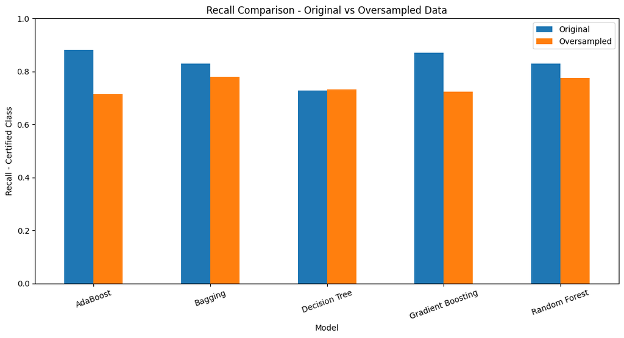

```python
recall_comparison = pd.DataFrame({
    'Original': original_metrics['Recall'],
    'Oversampled': oversampled_metrics['Recall']
})

recall_comparison.plot(
    kind='bar',
    figsize=(11, 6)
)

plt.title(
    'Recall Comparison - Original vs Oversampled Data'
)
plt.xlabel('Model')
plt.ylabel('Recall - Certified Class')
plt.xticks(rotation=20)
plt.ylim(0, 1)

plt.tight_layout()
plt.show()
```

## 12.19 Oversampling — Model Performance Analysis

### Decision Tree

The Decision Tree model trained on the oversampled dataset achieved an accuracy of **0.6509**, precision of **0.7416**, recall of **0.7327**, F1-score of **0.7371**, and ROC-AUC of **0.6095**.

Compared with the original Decision Tree, oversampling resulted in a slight improvement in accuracy from **0.6464 to 0.6509**, precision from **0.7388 to 0.7416**, recall from **0.7280 to 0.7327**, F1-score from **0.7334 to 0.7371**, and ROC-AUC from **0.6051 to 0.6095**.

Although the improvements are small, the oversampled Decision Tree performed slightly better than its original-data counterpart across all five evaluation metrics.

### Bagging

The Bagging model trained on the oversampled data achieved an accuracy of **0.7041**, precision of **0.7775**, recall of **0.7803**, F1-score of **0.7789**, and ROC-AUC of **0.7421**.

Compared with the original Bagging model, oversampling increased precision from **0.7623 to 0.7775**, but reduced accuracy from **0.7137 to 0.7041**, recall from **0.8302 to 0.7803**, F1-score from **0.7948 to 0.7789**, and ROC-AUC from **0.7445 to 0.7421**.

Therefore, oversampling improved precision but resulted in weaker overall predictive performance for Bagging, particularly in terms of recall.

### Random Forest

The Random Forest model trained on the oversampled data achieved an accuracy of **0.7029**, precision of **0.7781**, recall of **0.7767**, F1-score of **0.7774**, and ROC-AUC of **0.7461**.

Compared with the original Random Forest, oversampling increased precision from **0.7681 to 0.7781**. However, accuracy decreased from **0.7194 to 0.7029**, recall decreased from **0.8308 to 0.7767**, and F1-score decreased from **0.7982 to 0.7774**. ROC-AUC decreased slightly from **0.7502 to 0.7461**.

Thus, oversampling produced a precision improvement but reduced the model's ability to correctly identify Certified applications.

### AdaBoost

The AdaBoost model trained on the oversampled data achieved an accuracy of **0.6984**, precision of **0.8115**, recall of **0.7145**, F1-score of **0.7599**, and ROC-AUC of **0.7667**.

Compared with the original AdaBoost model, oversampling substantially increased precision from **0.7576 to 0.8115**. However, recall decreased from **0.8825 to 0.7145**, resulting in a reduction in F1-score from **0.8153 to 0.7599**.

Accuracy also decreased from **0.7329 to 0.6984**, while ROC-AUC remained almost unchanged, decreasing slightly from **0.7672 to 0.7667**.

This indicates a strong trade-off: oversampling made AdaBoost more precise when predicting the Certified class, but it substantially reduced its ability to identify Certified applications.

### Gradient Boosting

The Gradient Boosting model trained on the oversampled data achieved an accuracy of **0.7115**, precision of **0.8228**, recall of **0.7241**, F1-score of **0.7703**, and ROC-AUC of **0.7783**.

Compared with the original Gradient Boosting model, oversampling increased precision from **0.7774 to 0.8228** and ROC-AUC from **0.7776 to 0.7783**.

However, accuracy decreased from **0.7473 to 0.7115**, recall decreased from **0.8710 to 0.7241**, and F1-score decreased from **0.8216 to 0.7703**.

Therefore, oversampling improved precision and produced a very small improvement in ROC-AUC, but resulted in a substantial reduction in recall and F1-score.

## 12.20 Oversampling — Key Findings

Random oversampling was applied exclusively to the training dataset to address class imbalance. The test dataset was kept unchanged and was used only for evaluating the resulting models.

The five classification models were retrained using the oversampled training data and evaluated using the same metrics as the original-data experiment.

The oversampling experiment shows that:

Compared with the original-data experiment, oversampling did not result in an overall improvement in model performance. Although precision increased for all five models, the improvement was accompanied by reductions in recall for Bagging, Random Forest, AdaBoost, and Gradient Boosting. The F1-score also decreased for these four models.

The Decision Tree was the only model that showed a small improvement across all five metrics after oversampling, although its overall performance remained substantially lower than that of the ensemble models.

The most significant change was observed for AdaBoost. Its precision increased from **0.7576 to 0.8115**, but its recall decreased substantially from **0.8825 to 0.7145**. Since recall is important for identifying potentially certifiable applications, this represents an unfavorable trade-off for the current business objective.

Gradient Boosting achieved the highest precision (**0.8228**) and ROC-AUC (**0.7783**) among the oversampled models. However, its recall decreased considerably from **0.8710 to 0.7241**, and its F1-score decreased from **0.8216 to 0.7703**.

Therefore, based on the current evaluation results, oversampling does not provide a clear overall advantage over the original training-data approach. The original-data and oversampled results will be compared with the upcoming undersampled experiment before selecting candidate models for hyperparameter tuning.

No final model is selected at this stage.

## 12.21 Save Oversampling Results

```python
oversampled_comparison_export = oversampled_comparison.copy()

oversampled_comparison_export['Dataset'] = 'Oversampled'

display(oversampled_comparison_export)
```

|  | Model | Accuracy | Precision | Recall | F1-Score | ROC-AUC | Dataset |
| --- | --- | --- | --- | --- | --- | --- | --- |
| 0 | Bagging | 0.704082 | 0.777518 | 0.780259 | 0.778886 | 0.742149 | Oversampled |
| 1 | Random Forest | 0.702904 | 0.778105 | 0.776733 | 0.777418 | 0.746096 | Oversampled |
| 2 | Decision Tree | 0.650903 | 0.741600 | 0.732667 | 0.737107 | 0.609537 | Oversampled |
| 3 | Gradient Boosting | 0.711538 | 0.822764 | 0.724148 | 0.770312 | 0.778252 | Oversampled |
| 4 | AdaBoost | 0.698391 | 0.811478 | 0.714454 | 0.759881 | 0.766673 | Oversampled |

#### Critical leakage checkpoint

```python
print("=" * 65)
print("OVERSAMPLING LEAKAGE CHECK")
print("=" * 65)

print("Oversampling applied to training data only: YES")

print(
    "Test data class distribution unchanged:",
    Counter(y_test_encoded)
)

print(
    "\nOversampled training distribution:",
    Counter(y_train_oversampled)
)

print(
    "\nOriginal training distribution:",
    Counter(y_train_original)
)
```

```
=================================================================
OVERSAMPLING LEAKAGE CHECK
=================================================================
Oversampling applied to training data only: YES
Test data class distribution unchanged: Counter({np.int64(1): 3404, np.int64(0): 1692})

Oversampled training distribution: Counter({np.int64(0): 13614, np.int64(1): 13614})

Original training distribution: Counter({np.int64(1): 13614, np.int64(0): 6770})
```

# 13. Undersampling

## 13.1 Why Undersampling?

The EasyVisa dataset contains an imbalanced target variable. In the previous experiment, Random Oversampling was used to increase the representation of the minority class.

In this experiment, Random Undersampling is used as an alternative class-balancing technique. Undersampling reduces the number of observations from the majority class so that the training data contains a more balanced representation of the target classes.

Undersampling is applied only to the training dataset. The test dataset is kept completely untouched and retains its original class distribution.

This allows us to evaluate whether reducing the majority-class observations improves the model's ability to identify Certified applications.

## 13.2 Check Original Training Distribution

```python
from collections import Counter

print("Original training class distribution:")
print(Counter(y_train_original))
```

```
Original training class distribution:
Counter({np.int64(1): 13614, np.int64(0): 6770})
```

```python
original_counts = pd.Series(
    y_train_original
).value_counts().sort_index()

original_percentages = (
    original_counts /
    len(y_train_original) * 100
).round(2)

original_distribution = pd.DataFrame({
    'Class': ['Denied', 'Certified'],
    'Count': original_counts.values,
    'Percentage': original_percentages.values
})

display(original_distribution)
```

|  | Class | Count | Percentage |
| --- | --- | --- | --- |
| 0 | Denied | 6770 | 33.21 |
| 1 | Certified | 13614 | 66.79 |

## 13.3 Apply Random Undersampling

```python
from imblearn.under_sampling import RandomUnderSampler
undersampler = RandomUnderSampler(
    random_state=42
)
X_train_undersampled, y_train_undersampled = (
    undersampler.fit_resample(
        X_train_original,
        y_train_original
    )
)

print("Original training shape:")
print("X:", X_train_original.shape)
print("y:", y_train_original.shape)

print("\nUndersampled training shape:")
print("X:", X_train_undersampled.shape)
print("y:", y_train_undersampled.shape)
```

```
Original training shape:
X: (20384, 29)
y: (20384,)

Undersampled training shape:
X: (13540, 29)
y: (13540,)
```

## 13.4 Verify Undersampling

```python
undersampled_counts = pd.Series(
    y_train_undersampled
).value_counts().sort_index()

undersampled_percentages = (
    undersampled_counts /
    len(y_train_undersampled) * 100
).round(2)

undersampled_distribution = pd.DataFrame({
    'Class': ['Denied', 'Certified'],
    'Count': undersampled_counts.values,
    'Percentage': undersampled_percentages.values
})

display(undersampled_distribution)
```

|  | Class | Count | Percentage |
| --- | --- | --- | --- |
| 0 | Denied | 6770 | 50.0 |
| 1 | Certified | 6770 | 50.0 |

## 13.5 Before vs After Undersampling

```python
undersampling_distribution = pd.DataFrame({
    'Original Training':
        pd.Series(y_train_original).value_counts(),
    'Undersampled Training':
        pd.Series(y_train_undersampled).value_counts()
})

undersampling_distribution.index = [
    'Denied',
    'Certified'
]

display(undersampling_distribution)
```

|  | Original Training | Undersampled Training |
| --- | --- | --- |
| Denied | 6770 | 6770 |
| Certified | 13614 | 6770 |

#### Visualization

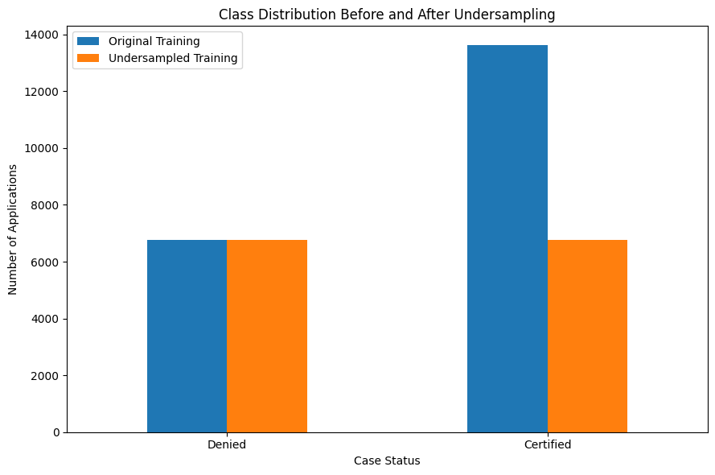

```python
undersampling_distribution.plot(
    kind='bar',
    figsize=(9, 6)
)

plt.title(
    'Class Distribution Before and After Undersampling'
)
plt.xlabel('Case Status')
plt.ylabel('Number of Applications')
plt.xticks(rotation=0)

plt.tight_layout()
plt.show()
```

## 13.6 Verify Test Data Remains Untouched

```python
print("Test data shape:")
print("X_test:", X_test_processed.shape)
print("y_test:", y_test_encoded.shape)

print("\nTest class distribution:")
print(Counter(y_test_encoded))
```

```
Test data shape:
X_test: (5096, 29)
y_test: (5096,)

Test class distribution:
Counter({np.int64(1): 3404, np.int64(0): 1692})
```

## 13.7 Define the Five Models

```python
models_undersampled = {

    'Decision Tree': DecisionTreeClassifier(
        random_state=42
    ),

    'Bagging': BaggingClassifier(
        random_state=42,
        n_estimators=100
    ),

    'Random Forest': RandomForestClassifier(
        random_state=42,
        n_estimators=100,
        n_jobs=-1
    ),

    'AdaBoost': AdaBoostClassifier(
        random_state=42,
        n_estimators=100
    ),

    'Gradient Boosting': GradientBoostingClassifier(
        random_state=42,
        n_estimators=100
    )
}

print("Undersampled-data models:")

for model_name in models_undersampled:
    print("-", model_name)
```

```
Undersampled-data models:
- Decision Tree
- Bagging
- Random Forest
- AdaBoost
- Gradient Boosting
```

## 13.8 Train and Evaluate All Five Models

```python
undersampled_results = []

for model_name, model in models_undersampled.items():

    print(f"Training {model_name}...")

    result = evaluate_model(
        model,
        X_train_undersampled,
        y_train_undersampled,
        X_test_processed,
        y_test_encoded
    )

    result['Model'] = model_name

    undersampled_results.append(result)

print("\nAll five undersampled models have been trained and evaluated.")
```

```
Training Decision Tree...
Training Bagging...
Training Random Forest...
Training AdaBoost...
Training Gradient Boosting...

All five undersampled models have been trained and evaluated.
```

## 13.9 Undersampled Model Comparison

```python
undersampled_results_df = pd.DataFrame(
    undersampled_results
)

undersampled_comparison = (
    undersampled_results_df[
        [
            'Model',
            'Accuracy',
            'Precision',
            'Recall',
            'F1-Score',
            'ROC-AUC'
        ]
    ]
    .sort_values(
        by='Recall',
        ascending=False
    )
    .reset_index(drop=True)
)

display(
    undersampled_comparison.style.format({
        'Accuracy': '{:.4f}',
        'Precision': '{:.4f}',
        'Recall': '{:.4f}',
        'F1-Score': '{:.4f}',
        'ROC-AUC': '{:.4f}'
    })
)
```

|  | Model | Accuracy | Precision | Recall | F1-Score | ROC-AUC |
| --- | --- | --- | --- | --- | --- | --- |
| 0 | Gradient Boosting | 0.7111 | 0.8253 | 0.7200 | 0.7691 | 0.7752 |
| 1 | AdaBoost | 0.6953 | 0.8119 | 0.7077 | 0.7562 | 0.7656 |
| 2 | Random Forest | 0.6762 | 0.8114 | 0.6713 | 0.7347 | 0.7464 |
| 3 | Bagging | 0.6701 | 0.8129 | 0.6575 | 0.7270 | 0.7440 |
| 4 | Decision Tree | 0.6128 | 0.7578 | 0.6178 | 0.6807 | 0.6103 |

## 13.10 Recall Comparison

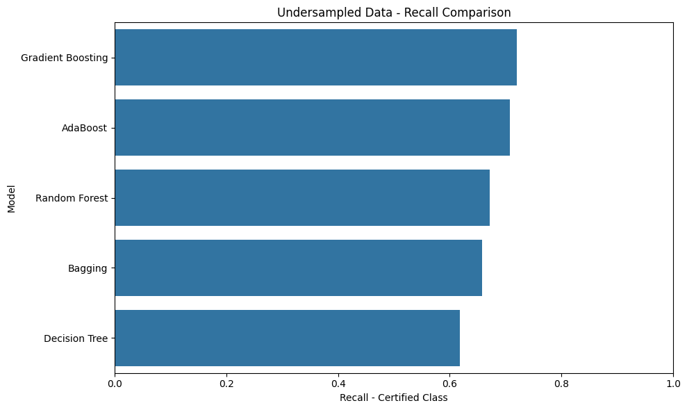

```python
plt.figure(figsize=(10, 6))

sns.barplot(
    data=undersampled_comparison,
    x='Recall',
    y='Model'
)

plt.title(
    'Undersampled Data - Recall Comparison'
)
plt.xlabel('Recall - Certified Class')
plt.ylabel('Model')
plt.xlim(0, 1)

plt.tight_layout()
plt.show()
```

## 13.11 F1-Score Comparison

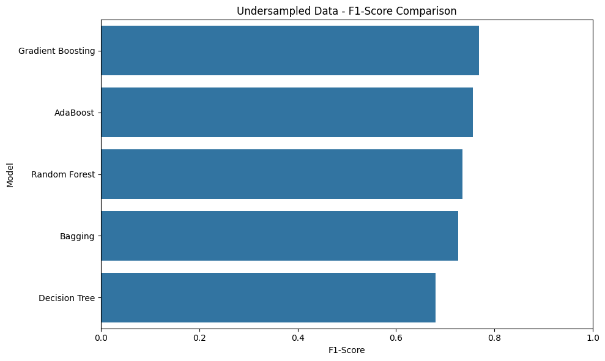

```python
plt.figure(figsize=(10, 6))

sns.barplot(
    data=undersampled_comparison,
    x='F1-Score',
    y='Model'
)

plt.title(
    'Undersampled Data - F1-Score Comparison'
)
plt.xlabel('F1-Score')
plt.ylabel('Model')
plt.xlim(0, 1)

plt.tight_layout()
plt.show()
```

## 13.12 ROC-AUC Comparison

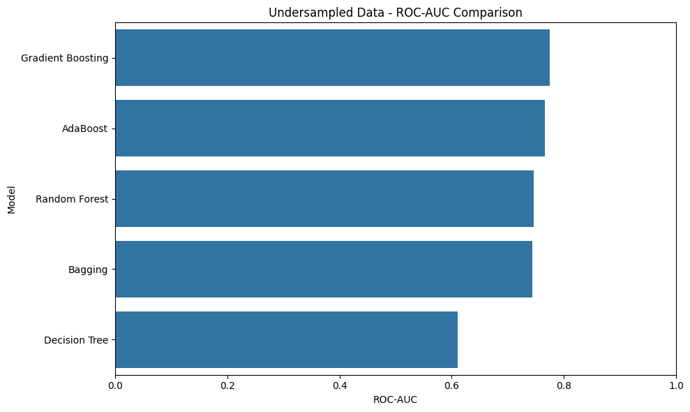

```python
plt.figure(figsize=(10, 6))

sns.barplot(
    data=undersampled_comparison,
    x='ROC-AUC',
    y='Model'
)

plt.title(
    'Undersampled Data - ROC-AUC Comparison'
)
plt.xlabel('ROC-AUC')
plt.ylabel('Model')
plt.xlim(0, 1)

plt.tight_layout()
plt.show()
```

## 13.13 Confusion Matrices

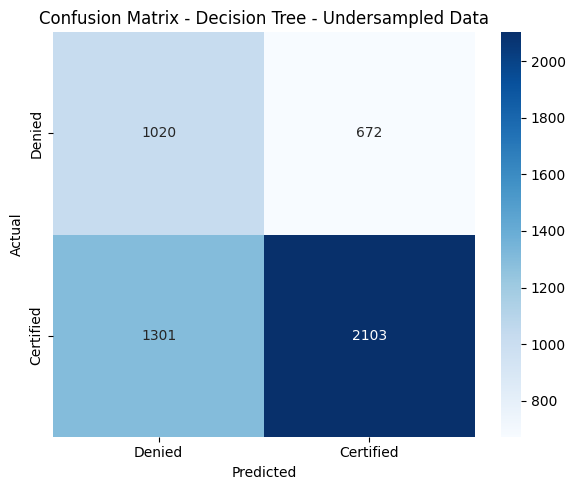

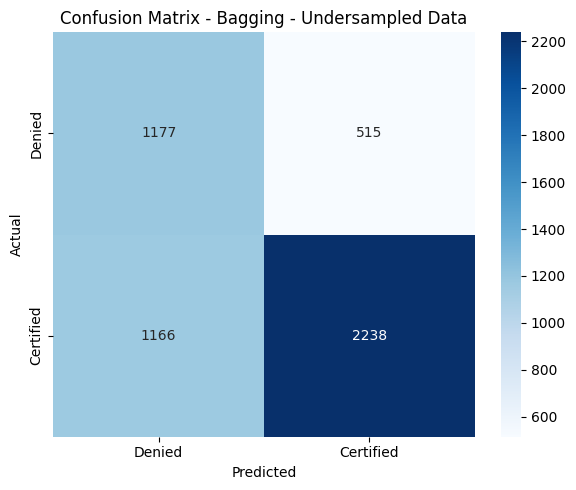

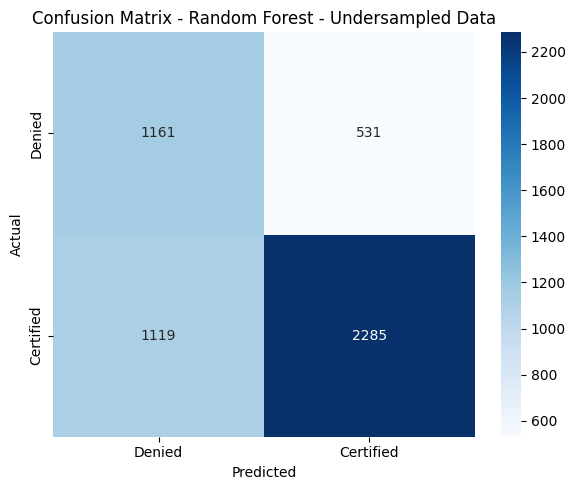

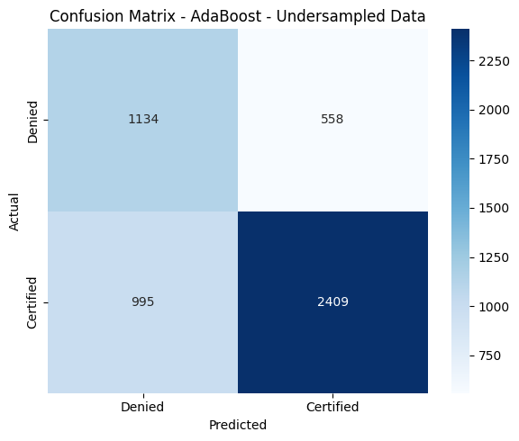

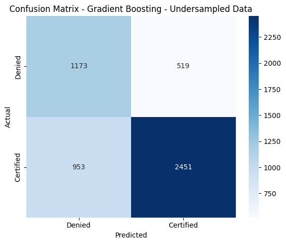

```python
for result in undersampled_results:

    model_name = result['Model']
    y_pred = result['Predictions']

    cm = confusion_matrix(
        y_test_encoded,
        y_pred
    )

    plt.figure(figsize=(6, 5))

    sns.heatmap(
        cm,
        annot=True,
        fmt='d',
        cmap='Blues',
        xticklabels=['Denied', 'Certified'],
        yticklabels=['Denied', 'Certified']
    )

    plt.title(
        f'Confusion Matrix - {model_name} - Undersampled Data'
    )

    plt.xlabel('Predicted')
    plt.ylabel('Actual')

    plt.tight_layout()
    plt.show()
```

## 13.14 Classification Reports

```python
for result in undersampled_results:

    model_name = result['Model']

    print("=" * 70)
    print(
        f"Classification Report - "
        f"{model_name} - Undersampled Data"
    )
    print("=" * 70)

    print(
        classification_report(
            y_test_encoded,
            result['Predictions'],
            target_names=['Denied', 'Certified'],
            digits=4,
            zero_division=0
        )
    )
```

```
======================================================================
Classification Report - Decision Tree - Undersampled Data
======================================================================
              precision    recall  f1-score   support

      Denied     0.4395    0.6028    0.5083      1692
   Certified     0.7578    0.6178    0.6807      3404

    accuracy                         0.6128      5096
   macro avg     0.5987    0.6103    0.5945      5096
weighted avg     0.6521    0.6128    0.6235      5096

======================================================================
Classification Report - Bagging - Undersampled Data
======================================================================
              precision    recall  f1-score   support

      Denied     0.5023    0.6956    0.5834      1692
   Certified     0.8129    0.6575    0.7270      3404

    accuracy                         0.6701      5096
   macro avg     0.6576    0.6765    0.6552      5096
weighted avg     0.7098    0.6701    0.6793      5096

======================================================================
Classification Report - Random Forest - Undersampled Data
======================================================================
              precision    recall  f1-score   support

      Denied     0.5092    0.6862    0.5846      1692
   Certified     0.8114    0.6713    0.7347      3404

    accuracy                         0.6762      5096
   macro avg     0.6603    0.6787    0.6597      5096
weighted avg     0.7111    0.6762    0.6849      5096

======================================================================
Classification Report - AdaBoost - Undersampled Data
======================================================================
              precision    recall  f1-score   support

      Denied     0.5326    0.6702    0.5936      1692
   Certified     0.8119    0.7077    0.7562      3404

    accuracy                         0.6953      5096
   macro avg     0.6723    0.6890    0.6749      5096
weighted avg     0.7192    0.6953    0.7022      5096

======================================================================
Classification Report - Gradient Boosting - Undersampled Data
======================================================================
              precision    recall  f1-score   support

      Denied     0.5517    0.6933    0.6145      1692
   Certified     0.8253    0.7200    0.7691      3404

    accuracy                         0.7111      5096
   macro avg     0.6885    0.7066    0.6918      5096
weighted avg     0.7344    0.7111    0.7177      5096
```

## 13.15 Best Undersampled Model by Recall

```python
best_undersampled_recall = undersampled_comparison.loc[
    undersampled_comparison['Recall'].idxmax()
]

print("Best undersampled model based on Recall:")
display(best_undersampled_recall)
```

```
Best undersampled model based on Recall:
```

|  | 0 |
| --- | --- |
| Model | Gradient Boosting |
| Accuracy | 0.711146 |
| Precision | 0.825253 |
| Recall | 0.720035 |
| F1-Score | 0.769062 |
| ROC-AUC | 0.775228 |

**dtype:** object

## 13.16 Best Undersampled Model by F1-Score

```python
best_undersampled_f1 = undersampled_comparison.loc[
    undersampled_comparison['F1-Score'].idxmax()
]

print("Best undersampled model based on F1-Score:")
display(best_undersampled_f1)
```

```
Best undersampled model based on F1-Score:
```

|  | 0 |
| --- | --- |
| Model | Gradient Boosting |
| Accuracy | 0.711146 |
| Precision | 0.825253 |
| Recall | 0.720035 |
| F1-Score | 0.769062 |
| ROC-AUC | 0.775228 |

**dtype:** object

## 13.17 Best Undersampled Model by ROC-AUC

```python
best_undersampled_auc = undersampled_comparison.loc[
    undersampled_comparison['ROC-AUC'].idxmax()
]

print("Best undersampled model based on ROC-AUC:")
display(best_undersampled_auc)
```

```
Best undersampled model based on ROC-AUC:
```

|  | 0 |
| --- | --- |
| Model | Gradient Boosting |
| Accuracy | 0.711146 |
| Precision | 0.825253 |
| Recall | 0.720035 |
| F1-Score | 0.769062 |
| ROC-AUC | 0.775228 |

**dtype:** object

## 13.18 Compare Original vs Oversampled vs Undersampled

```python
original_for_master = original_comparison.copy()
original_for_master['Dataset'] = 'Original'

oversampled_for_master = oversampled_comparison.copy()
oversampled_for_master['Dataset'] = 'Oversampled'

undersampled_for_master = undersampled_comparison.copy()
undersampled_for_master['Dataset'] = 'Undersampled'

master_model_comparison = pd.concat(
    [
        original_for_master,
        oversampled_for_master,
        undersampled_for_master
    ],
    ignore_index=True
)

display(
    master_model_comparison.style.format({
        'Accuracy': '{:.4f}',
        'Precision': '{:.4f}',
        'Recall': '{:.4f}',
        'F1-Score': '{:.4f}',
        'ROC-AUC': '{:.4f}'
    })
)
```

|  | Model | Accuracy | Precision | Recall | F1-Score | ROC-AUC | Dataset |
| --- | --- | --- | --- | --- | --- | --- | --- |
| 0 | AdaBoost | 0.7329 | 0.7576 | 0.8825 | 0.8153 | 0.7672 | Original |
| 1 | Gradient Boosting | 0.7473 | 0.7774 | 0.8710 | 0.8216 | 0.7776 | Original |
| 2 | Random Forest | 0.7194 | 0.7681 | 0.8308 | 0.7982 | 0.7502 | Original |
| 3 | Bagging | 0.7137 | 0.7623 | 0.8302 | 0.7948 | 0.7445 | Original |
| 4 | Decision Tree | 0.6464 | 0.7388 | 0.7280 | 0.7334 | 0.6051 | Original |
| 5 | Bagging | 0.7041 | 0.7775 | 0.7803 | 0.7789 | 0.7421 | Oversampled |
| 6 | Random Forest | 0.7029 | 0.7781 | 0.7767 | 0.7774 | 0.7461 | Oversampled |
| 7 | Decision Tree | 0.6509 | 0.7416 | 0.7327 | 0.7371 | 0.6095 | Oversampled |
| 8 | Gradient Boosting | 0.7115 | 0.8228 | 0.7241 | 0.7703 | 0.7783 | Oversampled |
| 9 | AdaBoost | 0.6984 | 0.8115 | 0.7145 | 0.7599 | 0.7667 | Oversampled |
| 10 | Gradient Boosting | 0.7111 | 0.8253 | 0.7200 | 0.7691 | 0.7752 | Undersampled |
| 11 | AdaBoost | 0.6953 | 0.8119 | 0.7077 | 0.7562 | 0.7656 | Undersampled |
| 12 | Random Forest | 0.6762 | 0.8114 | 0.6713 | 0.7347 | 0.7464 | Undersampled |
| 13 | Bagging | 0.6701 | 0.8129 | 0.6575 | 0.7270 | 0.7440 | Undersampled |
| 14 | Decision Tree | 0.6128 | 0.7578 | 0.6178 | 0.6807 | 0.6103 | Undersampled |

## 13.19 Compare Sampling Strategies by Model

```python
for metric in [
    'Accuracy',
    'Precision',
    'Recall',
    'F1-Score',
    'ROC-AUC'
]:

    pivot_table = master_model_comparison.pivot(
        index='Model',
        columns='Dataset',
        values=metric
    )

    print(f"\n{'=' * 70}")
    print(f"{metric} Comparison")
    print(f"{'=' * 70}")

    display(
        pivot_table.style.format('{:.4f}')
    )
```

```
======================================================================
Accuracy Comparison
======================================================================
```

| Dataset Model | Original | Oversampled | Undersampled |
| --- | --- | --- | --- |
| AdaBoost | 0.7329 | 0.6984 | 0.6953 |
| Bagging | 0.7137 | 0.7041 | 0.6701 |
| Decision Tree | 0.6464 | 0.6509 | 0.6128 |
| Gradient Boosting | 0.7473 | 0.7115 | 0.7111 |
| Random Forest | 0.7194 | 0.7029 | 0.6762 |

```
======================================================================
Precision Comparison
======================================================================
```

| Dataset Model | Original | Oversampled | Undersampled |
| --- | --- | --- | --- |
| AdaBoost | 0.7576 | 0.8115 | 0.8119 |
| Bagging | 0.7623 | 0.7775 | 0.8129 |
| Decision Tree | 0.7388 | 0.7416 | 0.7578 |
| Gradient Boosting | 0.7774 | 0.8228 | 0.8253 |
| Random Forest | 0.7681 | 0.7781 | 0.8114 |

```
======================================================================
Recall Comparison
======================================================================
```

| Dataset Model | Original | Oversampled | Undersampled |
| --- | --- | --- | --- |
| AdaBoost | 0.8825 | 0.7145 | 0.7077 |
| Bagging | 0.8302 | 0.7803 | 0.6575 |
| Decision Tree | 0.7280 | 0.7327 | 0.6178 |
| Gradient Boosting | 0.8710 | 0.7241 | 0.7200 |
| Random Forest | 0.8308 | 0.7767 | 0.6713 |

```
======================================================================
F1-Score Comparison
======================================================================
```

| Dataset Model | Original | Oversampled | Undersampled |
| --- | --- | --- | --- |
| AdaBoost | 0.8153 | 0.7599 | 0.7562 |
| Bagging | 0.7948 | 0.7789 | 0.7270 |
| Decision Tree | 0.7334 | 0.7371 | 0.6807 |
| Gradient Boosting | 0.8216 | 0.7703 | 0.7691 |
| Random Forest | 0.7982 | 0.7774 | 0.7347 |

```
======================================================================
ROC-AUC Comparison
======================================================================
```

| Dataset Model | Original | Oversampled | Undersampled |
| --- | --- | --- | --- |
| AdaBoost | 0.7672 | 0.7667 | 0.7656 |
| Bagging | 0.7445 | 0.7421 | 0.7440 |
| Decision Tree | 0.6051 | 0.6095 | 0.6103 |
| Gradient Boosting | 0.7776 | 0.7783 | 0.7752 |
| Random Forest | 0.7502 | 0.7461 | 0.7464 |

## 13.20 Undersampling — Model Performance Analysis

### Decision Tree

The Decision Tree model trained on the undersampled dataset achieved an accuracy of **0.6128**, precision of **0.7578**, recall of **0.6178**, F1-score of **0.6807**, and ROC-AUC of **0.6103**.

Compared with the original Decision Tree, undersampling increased precision from **0.7388 to 0.7578** and ROC-AUC from **0.6051 to 0.6103**. However, accuracy decreased from **0.6464 to 0.6128**, recall decreased from **0.7280 to 0.6178**, and F1-score decreased from **0.7334 to 0.6807**.

Therefore, undersampling improved precision slightly but reduced the model's overall classification performance.

### Bagging

The Bagging model trained on the undersampled dataset achieved an accuracy of **0.6701**, precision of **0.8129**, recall of **0.6575**, F1-score of **0.7270**, and ROC-AUC of **0.7440**.

Compared with the original Bagging model, undersampling increased precision from **0.7623 to 0.8129**. However, accuracy decreased from **0.7137 to 0.6701**, recall decreased from **0.8302 to 0.6575**, and F1-score decreased from **0.7948 to 0.7270**. ROC-AUC decreased slightly from **0.7445 to 0.7440**.

This indicates that undersampling made Bagging more precise when predicting the Certified class, but substantially reduced its ability to identify Certified applications.

### Random Forest

The Random Forest model trained on the undersampled dataset achieved an accuracy of **0.6762**, precision of **0.8114**, recall of **0.6713**, F1-score of **0.7347**, and ROC-AUC of **0.7464**.

### AdaBoost

The AdaBoost model trained on the undersampled dataset achieved an accuracy of **0.6953**, precision of **0.8119**, recall of **0.7077**, F1-score of **0.7562**, and ROC-AUC of **0.7656**.

Compared with the original AdaBoost model, undersampling increased precision from **0.7576 to 0.8119**. However, accuracy decreased from **0.7329 to 0.6953**, recall decreased from **0.8825 to 0.7077**, and F1-score decreased from **0.8153 to 0.7562**. ROC-AUC also decreased slightly from **0.7672 to 0.7656**.

Thus, undersampling resulted in a strong precision improvement but a substantial reduction in the model's ability to identify Certified applications.

### Gradient Boosting

The Gradient Boosting model trained on the undersampled dataset achieved an accuracy of **0.7111**, precision of **0.8253**, recall of **0.7200**, F1-score of **0.7691**, and ROC-AUC of **0.7752**.

Compared with the original Gradient Boosting model, undersampling increased precision from **0.7774 to 0.8253**, making it the highest-precision model in the undersampled experiment. However, accuracy decreased from **0.7473 to 0.7111**, recall decreased from **0.8710 to 0.7200**, and F1-score decreased from **0.8216 to 0.7691**. ROC-AUC also decreased slightly from **0.7776 to 0.7752**.

Therefore, although undersampling produced the highest precision, it substantially reduced recall and F1-score compared with the original Gradient Boosting model.

## 13.21 Undersampling — Key Findings

Random undersampling was applied exclusively to the training dataset to address class imbalance. The test dataset was kept unchanged and was used only for evaluating the resulting models.

The five classification models were retrained using the undersampled training data and evaluated using the same metrics as the original and oversampled experiments.

The undersampling experiment shows that:

Compared with the original-data experiment, undersampling increased Precision for all five models but reduced Recall, F1-score, and Accuracy for every model. ROC-AUC also decreased slightly for AdaBoost, Bagging, Gradient Boosting, and Random Forest, while the Decision Tree showed a small improvement.

Compared with oversampling, undersampling generally resulted in lower Recall, F1-score, and Accuracy. However, undersampling produced higher Precision for all five models than both the original and oversampled approaches.

The results demonstrate a clear precision-recall trade-off. By reducing the majority class, undersampling increases the proportion of correct Certified predictions among predicted Certified cases, but it also causes the models to miss a larger proportion of actual Certified applications.

Since Recall for the Certified class is an important business metric, the substantial reduction in Recall makes undersampling less attractive than the original-data approach for the current business objective.

The three sampling strategies will now be considered together to identify the strongest candidate models for hyperparameter tuning.

No final model is selected at this stage.

## 13.22 Save Undersampling Results

```python
undersampled_comparison_export = (
    undersampled_comparison.copy()
)

undersampled_comparison_export['Dataset'] = (
    'Undersampled'
)

display(undersampled_comparison_export)
```

|  | Model | Accuracy | Precision | Recall | F1-Score | ROC-AUC | Dataset |
| --- | --- | --- | --- | --- | --- | --- | --- |
| 0 | Gradient Boosting | 0.711146 | 0.825253 | 0.720035 | 0.769062 | 0.775228 | Undersampled |
| 1 | AdaBoost | 0.695251 | 0.811931 | 0.707697 | 0.756239 | 0.765613 | Undersampled |
| 2 | Random Forest | 0.676217 | 0.811435 | 0.671269 | 0.734727 | 0.746407 | Undersampled |
| 3 | Bagging | 0.670133 | 0.812931 | 0.657462 | 0.726977 | 0.744015 | Undersampled |
| 4 | Decision Tree | 0.612834 | 0.757838 | 0.617803 | 0.680693 | 0.610320 | Undersampled |

```python
master_model_comparison.to_csv(
    'easyvisa_15_model_comparison.csv',
    index=False
)

print(
    "15-model comparison saved successfully."
)
```

```
15-model comparison saved successfully.
```

## 13.23 Leakage Check

```python
print("=" * 65)
print("UNDERSAMPLING LEAKAGE CHECK")
print("=" * 65)

print("Undersampling applied to training data only: YES")

print(
    "\nOriginal training distribution:",
    Counter(y_train_original)
)

print(
    "Undersampled training distribution:",
    Counter(y_train_undersampled)
)

print(
    "\nTest distribution:",
    Counter(y_test_encoded)
)

print("\n✓ Test data was not undersampled.")
print("✓ Test data remains untouched for final evaluation.")
```

```
=================================================================
UNDERSAMPLING LEAKAGE CHECK
=================================================================
Undersampling applied to training data only: YES

Original training distribution: Counter({np.int64(1): 13614, np.int64(0): 6770})
Undersampled training distribution: Counter({np.int64(0): 6770, np.int64(1): 6770})

Test distribution: Counter({np.int64(1): 3404, np.int64(0): 1692})

✓ Test data was not undersampled.
✓ Test data remains untouched for final evaluation.
```

## 13.24 Undersampling — Conclusion

Random undersampling was applied to the training dataset to create a balanced training set while preserving the original test dataset.

Five classification models — Decision Tree, Bagging, Random Forest, AdaBoost, and Gradient Boosting — were trained using the undersampled training data and evaluated on the untouched test dataset.

The performance of these models will be compared with the corresponding models trained on the original and oversampled datasets.

At the completion of the three experiments, a total of 15 model configurations will have been evaluated. These results will provide the evidence required to identify promising candidate models for hyperparameter tuning.

The final model will not be selected based on the undersampling experiment alone.

# 14. Undersampling

## 14.1 Objective

The objective of this experiment is to evaluate the performance of classification models after applying random undersampling to the training dataset.

The following five models are evaluated:

1. Decision Tree
2. Bagging
3. Random Forest
4. AdaBoost
5. Gradient Boosting

The models are evaluated using Accuracy, Precision, Recall, F1-score, and ROC-AUC.

Random undersampling is applied only to the training data. The test dataset remains completely untouched and is used only for model evaluation.

## 14.2 Why Undersampling?

The EasyVisa dataset contains an imbalanced target variable. To address this imbalance, Random Undersampling is used as an alternative to the oversampling approach evaluated earlier.

Random undersampling reduces the number of observations belonging to the majority class so that the training dataset contains a more balanced representation of the target classes.

This approach can reduce the dominance of the majority class during model training. However, it also removes some available training observations, which may result in information loss.

Therefore, the performance of the undersampled models is compared with the corresponding models trained on the original and oversampled datasets.

The test dataset is not undersampled to ensure that model evaluation is performed on an untouched dataset representing the original data distribution.

## 14.3 Check Original Training Class Distribution

```python
from collections import Counter

print("Original training class distribution:")
print(Counter(y_train_original))

original_counts = pd.Series(
    y_train_original
).value_counts().sort_index()

original_percentages = (
    original_counts /
    len(y_train_original) * 100
).round(2)

original_distribution = pd.DataFrame({
    'Class': ['Denied', 'Certified'],
    'Count': original_counts.values,
    'Percentage': original_percentages.values
})

display(original_distribution)
```

```
Original training class distribution:
Counter({np.int64(1): 13614, np.int64(0): 6770})
```

|  | Class | Count | Percentage |
| --- | --- | --- | --- |
| 0 | Denied | 6770 | 33.21 |
| 1 | Certified | 13614 | 66.79 |

## 14.4 Apply Random Undersampling

```python
from imblearn.under_sampling import RandomUnderSampler

undersampler = RandomUnderSampler(
    random_state=42
)

X_train_undersampled, y_train_undersampled = (
    undersampler.fit_resample(
        X_train_original,
        y_train_original
    )
)

print("Original training shape:")
print("X:", X_train_original.shape)
print("y:", y_train_original.shape)

print("\nUndersampled training shape:")
print("X:", X_train_undersampled.shape)
print("y:", y_train_undersampled.shape)
```

```
Original training shape:
X: (20384, 29)
y: (20384,)

Undersampled training shape:
X: (13540, 29)
y: (13540,)
```

## 14.5 Verify Undersampling

```python
undersampled_counts = pd.Series(
    y_train_undersampled
).value_counts().sort_index()

undersampled_percentages = (
    undersampled_counts /
    len(y_train_undersampled) * 100
).round(2)

undersampled_distribution = pd.DataFrame({
    'Class': ['Denied', 'Certified'],
    'Count': undersampled_counts.values,
    'Percentage': undersampled_percentages.values
})

display(undersampled_distribution)
```

|  | Class | Count | Percentage |
| --- | --- | --- | --- |
| 0 | Denied | 6770 | 50.0 |
| 1 | Certified | 6770 | 50.0 |

## 14.6 Visualize Class Distribution

|  | Original Training | Undersampled Training |
| --- | --- | --- |
| Denied | 6770 | 6770 |
| Certified | 13614 | 6770 |

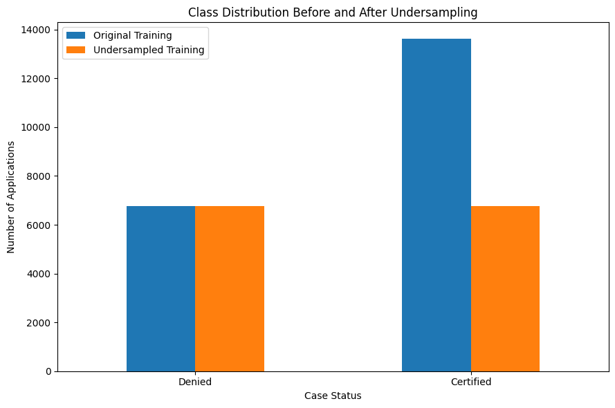

```python
undersampling_distribution = pd.DataFrame({
    'Original Training':
        pd.Series(y_train_original).value_counts(),
    'Undersampled Training':
        pd.Series(y_train_undersampled).value_counts()
})

undersampling_distribution.index = [
    'Denied',
    'Certified'
]

display(undersampling_distribution)


undersampling_distribution.plot(
    kind='bar',
    figsize=(9, 6)
)

plt.title(
    'Class Distribution Before and After Undersampling'
)
plt.xlabel('Case Status')
plt.ylabel('Number of Applications')
plt.xticks(rotation=0)

plt.tight_layout()
plt.show()
```

## 14.7 Verify Test Data Remains Untouched

```python
print("Test data shape:")
print("X_test:", X_test_processed.shape)
print("y_test:", y_test_encoded.shape)

print("\nTest class distribution:")
print(Counter(y_test_encoded))
```

```
Test data shape:
X_test: (5096, 29)
y_test: (5096,)

Test class distribution:
Counter({np.int64(1): 3404, np.int64(0): 1692})
```

## 14.8 Build the Five Models

```python
models_undersampled = {

    'Decision Tree': DecisionTreeClassifier(
        random_state=42
    ),

    'Bagging': BaggingClassifier(
        random_state=42,
        n_estimators=100
    ),

    'Random Forest': RandomForestClassifier(
        random_state=42,
        n_estimators=100,
        n_jobs=-1
    ),

    'AdaBoost': AdaBoostClassifier(
        random_state=42,
        n_estimators=100
    ),

    'Gradient Boosting': GradientBoostingClassifier(
        random_state=42,
        n_estimators=100
    )
}

print("Five models selected:")

for model_name in models_undersampled:
    print("-", model_name)
```

```
Five models selected:
- Decision Tree
- Bagging
- Random Forest
- AdaBoost
- Gradient Boosting
```

## 14.9 Train and Evaluate the Five Models

```python
undersampled_results = []

for model_name, model in models_undersampled.items():

    print(f"Training {model_name}...")

    result = evaluate_model(
        model,
        X_train_undersampled,
        y_train_undersampled,
        X_test_processed,
        y_test_encoded
    )

    result['Model'] = model_name

    undersampled_results.append(result)

print("\nAll five undersampled models have been trained and evaluated.")
```

```
Training Decision Tree...
Training Bagging...
Training Random Forest...
Training AdaBoost...
Training Gradient Boosting...

All five undersampled models have been trained and evaluated.
```

## 14.10 Undersampled Model Comparison

```python
undersampled_results_df = pd.DataFrame(
    undersampled_results
)

undersampled_comparison = (
    undersampled_results_df[
        [
            'Model',
            'Accuracy',
            'Precision',
            'Recall',
            'F1-Score',
            'ROC-AUC'
        ]
    ]
    .sort_values(
        by='Recall',
        ascending=False
    )
    .reset_index(drop=True)
)

display(
    undersampled_comparison.style.format({
        'Accuracy': '{:.4f}',
        'Precision': '{:.4f}',
        'Recall': '{:.4f}',
        'F1-Score': '{:.4f}',
        'ROC-AUC': '{:.4f}'
    })
)
```

|  | Model | Accuracy | Precision | Recall | F1-Score | ROC-AUC |
| --- | --- | --- | --- | --- | --- | --- |
| 0 | Gradient Boosting | 0.7111 | 0.8253 | 0.7200 | 0.7691 | 0.7752 |
| 1 | AdaBoost | 0.6953 | 0.8119 | 0.7077 | 0.7562 | 0.7656 |
| 2 | Random Forest | 0.6762 | 0.8114 | 0.6713 | 0.7347 | 0.7464 |
| 3 | Bagging | 0.6701 | 0.8129 | 0.6575 | 0.7270 | 0.7440 |
| 4 | Decision Tree | 0.6128 | 0.7578 | 0.6178 | 0.6807 | 0.6103 |

## 14.11 Accuracy Comparison

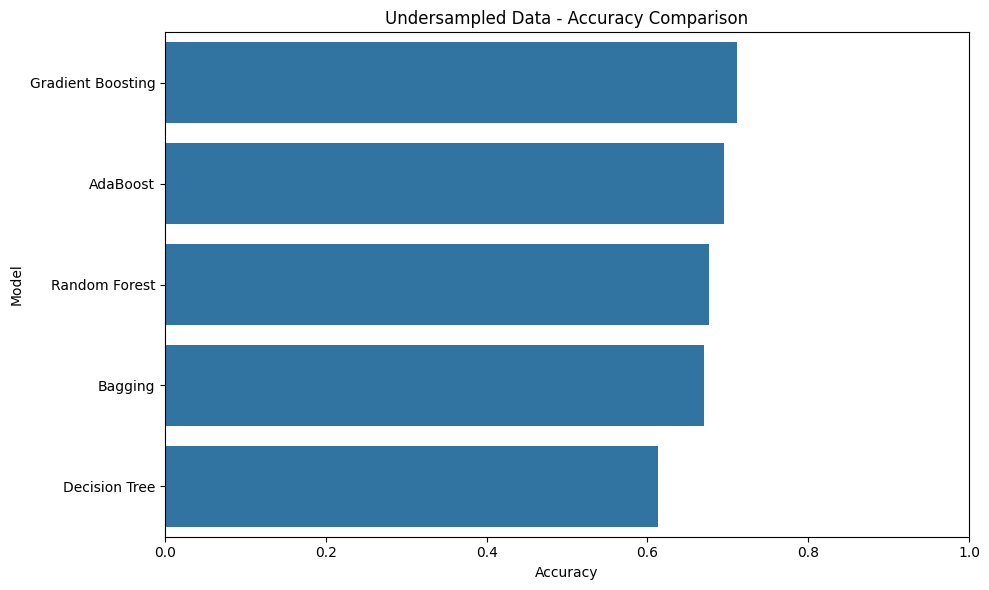

```python
plt.figure(figsize=(10, 6))

sns.barplot(
    data=undersampled_comparison,
    x='Accuracy',
    y='Model'
)

plt.title(
    'Undersampled Data - Accuracy Comparison'
)
plt.xlabel('Accuracy')
plt.ylabel('Model')
plt.xlim(0, 1)

plt.tight_layout()
plt.show()
```

## 14.12 Precision Comparison

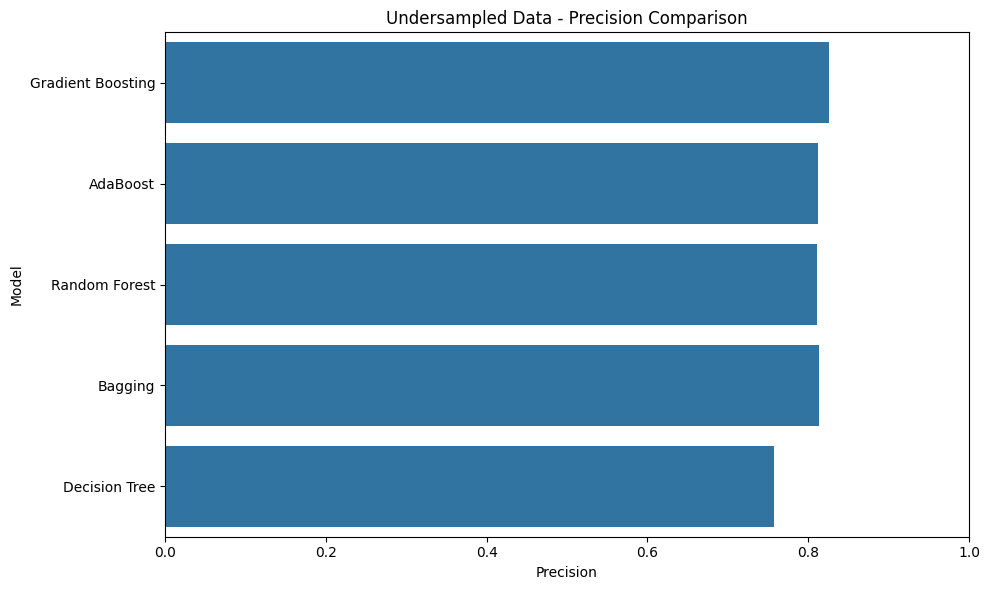

```python
plt.figure(figsize=(10, 6))

sns.barplot(
    data=undersampled_comparison,
    x='Precision',
    y='Model'
)

plt.title(
    'Undersampled Data - Precision Comparison'
)
plt.xlabel('Precision')
plt.ylabel('Model')
plt.xlim(0, 1)

plt.tight_layout()
plt.show()
```

## 14.13 Recall Comparison

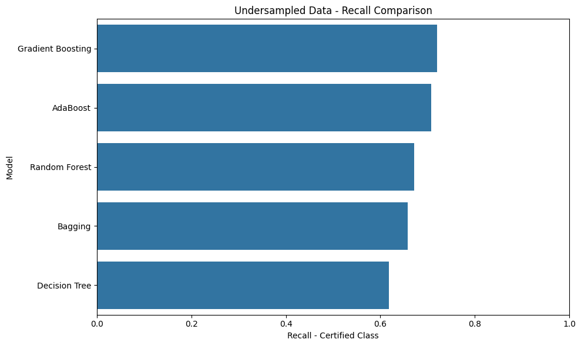

```python
plt.figure(figsize=(10, 6))

sns.barplot(
    data=undersampled_comparison,
    x='Recall',
    y='Model'
)

plt.title(
    'Undersampled Data - Recall Comparison'
)
plt.xlabel('Recall - Certified Class')
plt.ylabel('Model')
plt.xlim(0, 1)

plt.tight_layout()
plt.show()
```

## 14.14 F1-Score Comparison

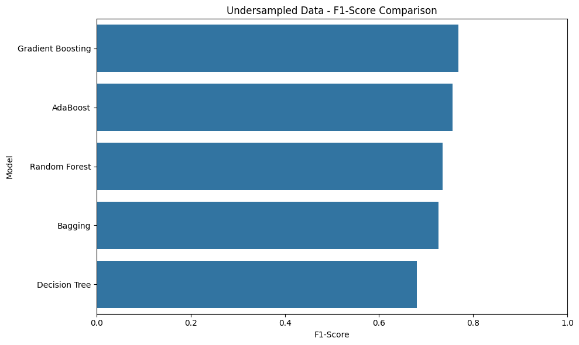

```python
plt.figure(figsize=(10, 6))

sns.barplot(
    data=undersampled_comparison,
    x='F1-Score',
    y='Model'
)

plt.title(
    'Undersampled Data - F1-Score Comparison'
)
plt.xlabel('F1-Score')
plt.ylabel('Model')
plt.xlim(0, 1)

plt.tight_layout()
plt.show()
```

## 14.15 ROC-AUC Comparison

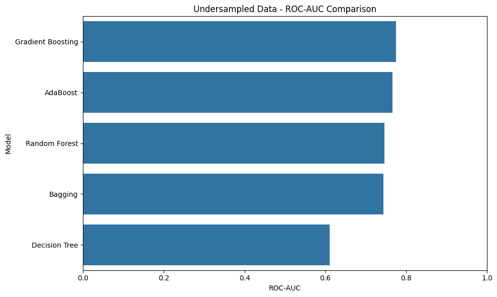

```python
plt.figure(figsize=(10, 6))

sns.barplot(
    data=undersampled_comparison,
    x='ROC-AUC',
    y='Model'
)

plt.title(
    'Undersampled Data - ROC-AUC Comparison'
)
plt.xlabel('ROC-AUC')
plt.ylabel('Model')
plt.xlim(0, 1)

plt.tight_layout()
plt.show()
```

## 14.16 Confusion Matrix

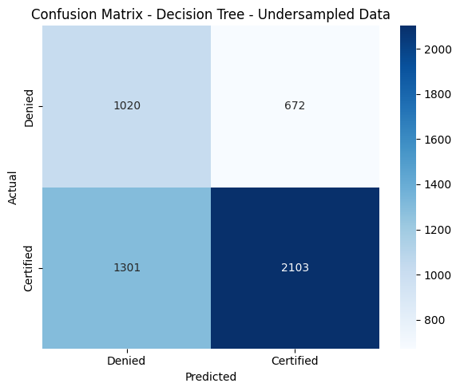

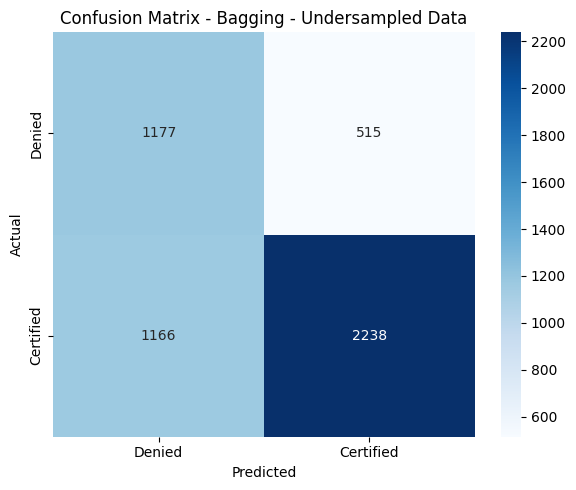

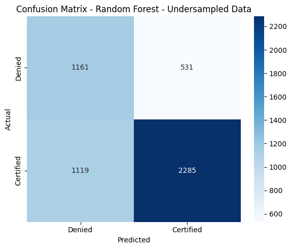

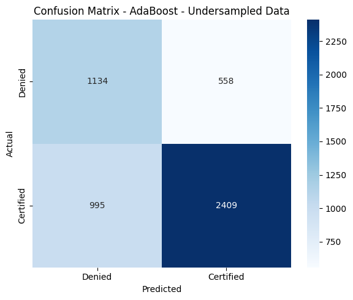

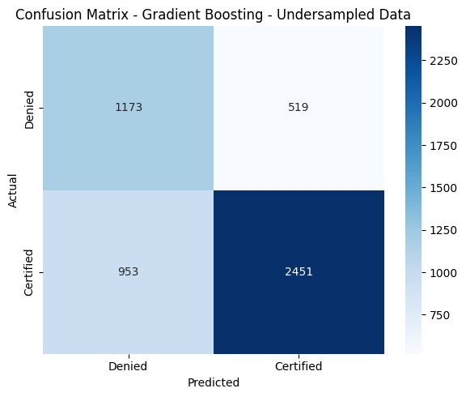

```python
for result in undersampled_results:

    model_name = result['Model']
    y_pred = result['Predictions']

    cm = confusion_matrix(
        y_test_encoded,
        y_pred
    )

    plt.figure(figsize=(6, 5))

    sns.heatmap(
        cm,
        annot=True,
        fmt='d',
        cmap='Blues',
        xticklabels=['Denied', 'Certified'],
        yticklabels=['Denied', 'Certified']
    )

    plt.title(
        f'Confusion Matrix - {model_name} - Undersampled Data'
    )

    plt.xlabel('Predicted')
    plt.ylabel('Actual')

    plt.tight_layout()
    plt.show()
```

## 14.17 Classification Reports

```python
for result in undersampled_results:

    model_name = result['Model']

    print("=" * 70)
    print(
        f"Classification Report - "
        f"{model_name} - Undersampled Data"
    )
    print("=" * 70)

    print(
        classification_report(
            y_test_encoded,
            result['Predictions'],
            target_names=['Denied', 'Certified'],
            digits=4,
            zero_division=0
        )
    )
```

```
======================================================================
Classification Report - Decision Tree - Undersampled Data
======================================================================
              precision    recall  f1-score   support

      Denied     0.4395    0.6028    0.5083      1692
   Certified     0.7578    0.6178    0.6807      3404

    accuracy                         0.6128      5096
   macro avg     0.5987    0.6103    0.5945      5096
weighted avg     0.6521    0.6128    0.6235      5096

======================================================================
Classification Report - Bagging - Undersampled Data
======================================================================
              precision    recall  f1-score   support

      Denied     0.5023    0.6956    0.5834      1692
   Certified     0.8129    0.6575    0.7270      3404

    accuracy                         0.6701      5096
   macro avg     0.6576    0.6765    0.6552      5096
weighted avg     0.7098    0.6701    0.6793      5096

======================================================================
Classification Report - Random Forest - Undersampled Data
======================================================================
              precision    recall  f1-score   support

      Denied     0.5092    0.6862    0.5846      1692
   Certified     0.8114    0.6713    0.7347      3404

    accuracy                         0.6762      5096
   macro avg     0.6603    0.6787    0.6597      5096
weighted avg     0.7111    0.6762    0.6849      5096

======================================================================
Classification Report - AdaBoost - Undersampled Data
======================================================================
              precision    recall  f1-score   support

      Denied     0.5326    0.6702    0.5936      1692
   Certified     0.8119    0.7077    0.7562      3404

    accuracy                         0.6953      5096
   macro avg     0.6723    0.6890    0.6749      5096
weighted avg     0.7192    0.6953    0.7022      5096

======================================================================
Classification Report - Gradient Boosting - Undersampled Data
======================================================================
              precision    recall  f1-score   support

      Denied     0.5517    0.6933    0.6145      1692
   Certified     0.8253    0.7200    0.7691      3404

    accuracy                         0.7111      5096
   macro avg     0.6885    0.7066    0.6918      5096
weighted avg     0.7344    0.7111    0.7177      5096
```

## 14.18 Undersampled Data — Model Performance Analysis

### Decision Tree

The Decision Tree model trained on the undersampled dataset achieved an accuracy of **0.6128**, precision of **0.7578**, recall of **0.6178**, F1-score of **0.6807**, and ROC-AUC of **0.6103**.

Compared with the original Decision Tree, undersampling increased precision from **0.7388 to 0.7578** and ROC-AUC from **0.6051 to 0.6103**. However, accuracy decreased from **0.6464 to 0.6128**, recall decreased from **0.7280 to 0.6178**, and F1-score decreased from **0.7334 to 0.6807**.

Therefore, undersampling improved precision slightly but reduced the model's overall predictive performance.

### Bagging

The Bagging model trained on the undersampled dataset achieved an accuracy of **0.6701**, precision of **0.8129**, recall of **0.6575**, F1-score of **0.7270**, and ROC-AUC of **0.7440**.

Compared with the original Bagging model, undersampling increased precision from **0.7623 to 0.8129**. However, accuracy decreased from **0.7137 to 0.6701**, recall decreased from **0.8302 to 0.6575**, and F1-score decreased from **0.7948 to 0.7270**. ROC-AUC decreased slightly from **0.7445 to 0.7440**.

This indicates that undersampling increased precision but substantially reduced the model's ability to identify Certified applications.

### Random Forest

The Random Forest model trained on the undersampled dataset achieved an accuracy of **0.6762**, precision of **0.8114**, recall of **0.6713**, F1-score of **0.7347**, and ROC-AUC of **0.7464**.

Compared with the original Random Forest, undersampling increased precision from **0.7681 to 0.8114**. However, accuracy decreased from **0.7194 to 0.6762**, recall decreased from **0.8308 to 0.6713**, F1-score decreased from **0.7982 to 0.7347**, and ROC-AUC decreased from **0.7502 to 0.7464**.

The increase in precision was therefore accompanied by a substantial reduction in recall and F1-score.

### AdaBoost

The AdaBoost model trained on the undersampled dataset achieved an accuracy of **0.6953**, precision of **0.8119**, recall of **0.7077**, F1-score of **0.7562**, and ROC-AUC of **0.7656**.

Compared with the original AdaBoost model, undersampling increased precision from **0.7576 to 0.8119**. However, accuracy decreased from **0.7329 to 0.6953**, recall decreased from **0.8825 to 0.7077**, and F1-score decreased from **0.8153 to 0.7562**. ROC-AUC also decreased slightly from **0.7672 to 0.7656**.

Thus, undersampling resulted in a strong precision improvement but a substantial reduction in recall.

### Gradient Boosting

The Gradient Boosting model trained on the undersampled dataset achieved an accuracy of **0.7111**, precision of **0.8253**, recall of **0.7200**, F1-score of **0.7691**, and ROC-AUC of **0.7752**.

Compared with the original Gradient Boosting model, undersampling increased precision from **0.7774 to 0.8253**. However, accuracy decreased from **0.7473 to 0.7111**, recall decreased from **0.8710 to 0.7200**, F1-score decreased from **0.8216 to 0.7691**, and ROC-AUC decreased from **0.7776 to 0.7752**.

Gradient Boosting was nevertheless the strongest model within the undersampled experiment, achieving the highest value for all five evaluation metrics.

## 14.19 Undersampled Data — Key Findings

The five classification models were trained using the undersampled training dataset and evaluated on the untouched test dataset.

The undersampling experiment shows that:

- The model with the highest **Recall** is **Gradient Boosting**, with a Recall of **0.7200**.
- The model with the highest **F1-score** is **Gradient Boosting**, with an F1-score of **0.7691**.
- The model with the highest **ROC-AUC** is **Gradient Boosting**, with a ROC-AUC of **0.7752**.
- The model with the highest **Precision** is **Gradient Boosting**, with a Precision of **0.8253**.
- The model with the highest **Accuracy** is **Gradient Boosting**, with an Accuracy of **0.7111**.

Gradient Boosting therefore performed best across all five evaluation metrics within the undersampled experiment.

Compared with the original-data experiment, undersampling increased Precision for all five models but reduced Accuracy, Recall, and F1-score for every model. ROC-AUC also decreased slightly for most models.

The results demonstrate a clear precision-recall trade-off. Although undersampling improved the precision of predictions for the Certified class, it resulted in more Certified applications being incorrectly classified as Denied.

Since identifying potentially certifiable applications is an important business objective, the reduction in Recall is an important consideration.

Therefore, although Gradient Boosting is the strongest model within the undersampled experiment, undersampling does not provide an overall performance improvement compared with the original-data approach.

The results from the Original, Oversampled, and Undersampled experiments will be considered together before selecting candidate models for hyperparameter tuning.

No final model is selected at this stage.

## 14.20 Save Undersampled Results

```python
undersampled_comparison_export = (
    undersampled_comparison.copy()
)

undersampled_comparison_export['Dataset'] = 'Undersampled'

display(undersampled_comparison_export)
```

|  | Model | Accuracy | Precision | Recall | F1-Score | ROC-AUC | Dataset |
| --- | --- | --- | --- | --- | --- | --- | --- |
| 0 | Gradient Boosting | 0.711146 | 0.825253 | 0.720035 | 0.769062 | 0.775228 | Undersampled |
| 1 | AdaBoost | 0.695251 | 0.811931 | 0.707697 | 0.756239 | 0.765613 | Undersampled |
| 2 | Random Forest | 0.676217 | 0.811435 | 0.671269 | 0.734727 | 0.746407 | Undersampled |
| 3 | Bagging | 0.670133 | 0.812931 | 0.657462 | 0.726977 | 0.744015 | Undersampled |
| 4 | Decision Tree | 0.612834 | 0.757838 | 0.617803 | 0.680693 | 0.610320 | Undersampled |

```python
master_model_comparison = pd.concat(
    [
        original_comparison.assign(
            Dataset='Original'
        ),
        oversampled_comparison.assign(
            Dataset='Oversampled'
        ),
        undersampled_comparison.assign(
            Dataset='Undersampled'
        )
    ],
    ignore_index=True
)

display(
    master_model_comparison.style.format({
        'Accuracy': '{:.4f}',
        'Precision': '{:.4f}',
        'Recall': '{:.4f}',
        'F1-Score': '{:.4f}',
        'ROC-AUC': '{:.4f}'
    })
)
```

|  | Model | Accuracy | Precision | Recall | F1-Score | ROC-AUC | Dataset |
| --- | --- | --- | --- | --- | --- | --- | --- |
| 0 | AdaBoost | 0.7329 | 0.7576 | 0.8825 | 0.8153 | 0.7672 | Original |
| 1 | Gradient Boosting | 0.7473 | 0.7774 | 0.8710 | 0.8216 | 0.7776 | Original |
| 2 | Random Forest | 0.7194 | 0.7681 | 0.8308 | 0.7982 | 0.7502 | Original |
| 3 | Bagging | 0.7137 | 0.7623 | 0.8302 | 0.7948 | 0.7445 | Original |
| 4 | Decision Tree | 0.6464 | 0.7388 | 0.7280 | 0.7334 | 0.6051 | Original |
| 5 | Bagging | 0.7041 | 0.7775 | 0.7803 | 0.7789 | 0.7421 | Oversampled |
| 6 | Random Forest | 0.7029 | 0.7781 | 0.7767 | 0.7774 | 0.7461 | Oversampled |
| 7 | Decision Tree | 0.6509 | 0.7416 | 0.7327 | 0.7371 | 0.6095 | Oversampled |
| 8 | Gradient Boosting | 0.7115 | 0.8228 | 0.7241 | 0.7703 | 0.7783 | Oversampled |
| 9 | AdaBoost | 0.6984 | 0.8115 | 0.7145 | 0.7599 | 0.7667 | Oversampled |
| 10 | Gradient Boosting | 0.7111 | 0.8253 | 0.7200 | 0.7691 | 0.7752 | Undersampled |
| 11 | AdaBoost | 0.6953 | 0.8119 | 0.7077 | 0.7562 | 0.7656 | Undersampled |
| 12 | Random Forest | 0.6762 | 0.8114 | 0.6713 | 0.7347 | 0.7464 | Undersampled |
| 13 | Bagging | 0.6701 | 0.8129 | 0.6575 | 0.7270 | 0.7440 | Undersampled |
| 14 | Decision Tree | 0.6128 | 0.7578 | 0.6178 | 0.6807 | 0.6103 | Undersampled |

## 14.21 Leakage Check

```python
print("=" * 65)
print("UNDERSAMPLING LEAKAGE CHECK")
print("=" * 65)

print("Undersampling applied only to training data: YES")
print("Test data undersampled: NO")
print("Test data used for training: NO")

print("\nOriginal training distribution:")
print(Counter(y_train_original))

print("\nUndersampled training distribution:")
print(Counter(y_train_undersampled))

print("\nTest distribution:")
print(Counter(y_test_encoded))

print("\n✓ Test data remains untouched.")
print("✓ Undersampling was applied only to training data.")
```

```
=================================================================
UNDERSAMPLING LEAKAGE CHECK
=================================================================
Undersampling applied only to training data: YES
Test data undersampled: NO
Test data used for training: NO

Original training distribution:
Counter({np.int64(1): 13614, np.int64(0): 6770})

Undersampled training distribution:
Counter({np.int64(0): 6770, np.int64(1): 6770})

Test distribution:
Counter({np.int64(1): 3404, np.int64(0): 1692})

✓ Test data remains untouched.
✓ Undersampling was applied only to training data.
```

# 15. Undersampled Data — Model Comparison / Analysis

## 15.1 Undersampled Model Performance

The five classification models were trained using the undersampled training dataset and evaluated on the untouched test dataset.

The performance of the models is summarized below.

## 15.2 Model-wise Analysis

Decision Tree

The Decision Tree achieved an accuracy of 0.6128, precision of 0.7578, recall of 0.6178, F1-score of 0.6807, and ROC-AUC of 0.6103.

It recorded the weakest overall performance among the five models. Although its precision remained reasonably high, its low recall indicates that a considerable proportion of Certified applications were incorrectly classified as Denied.

Bagging

The Bagging model achieved an accuracy of 0.6701, precision of 0.8129, recall of 0.6575, F1-score of 0.7270, and ROC-AUC of 0.7440.

Bagging achieved substantially higher precision than Decision Tree, but its recall was relatively low. This indicates that the model was more conservative when identifying Certified applications.

Random Forest

The Random Forest model achieved an accuracy of 0.6762, precision of 0.8114, recall of 0.6713, F1-score of 0.7347, and ROC-AUC of 0.7464.

Random Forest performed better than Bagging in accuracy, recall, F1-score, and ROC-AUC, while maintaining a similar precision. It therefore provided a stronger overall performance than Bagging under undersampling.

AdaBoost

The AdaBoost model achieved an accuracy of 0.6953, precision of 0.8119, recall of 0.7077, F1-score of 0.7562, and ROC-AUC of 0.7656.

AdaBoost performed better than Decision Tree, Bagging, and Random Forest across the major performance metrics. Its recall of 0.7077 was relatively high within the undersampled experiment, although it remained below its original-data recall of 0.8825.

Gradient Boosting

The Gradient Boosting model achieved an accuracy of 0.7111, precision of 0.8253, recall of 0.7200, F1-score of 0.7691, and ROC-AUC of 0.7752.

Gradient Boosting was the best-performing model across all five metrics within the undersampled experiment. It achieved the highest accuracy, precision, recall, F1-score, and ROC-AUC.

However, its performance was still lower than its original-data performance in terms of accuracy, recall, and F1-score. Therefore, although Gradient Boosting is the strongest undersampled model, undersampling did not improve its overall performance.

## 15.3 Undersampled Model Ranking

```python
undersampled_ranking = undersampled_comparison.copy()

for metric in [
    'Accuracy',
    'Precision',
    'Recall',
    'F1-Score',
    'ROC-AUC'
]:
    undersampled_ranking[
        f'{metric} Rank'
    ] = (
        undersampled_ranking[metric]
        .rank(
            ascending=False,
            method='min'
        )
        .astype(int)
    )

display(undersampled_ranking)
```

|  | Model | Accuracy | Precision | Recall | F1-Score | ROC-AUC | Accuracy Rank | Precision Rank | Recall Rank | F1-Score Rank | ROC-AUC Rank |
| --- | --- | --- | --- | --- | --- | --- | --- | --- | --- | --- | --- |
| 0 | Gradient Boosting | 0.711146 | 0.825253 | 0.720035 | 0.769062 | 0.775228 | 1 | 1 | 1 | 1 | 1 |
| 1 | AdaBoost | 0.695251 | 0.811931 | 0.707697 | 0.756239 | 0.765613 | 2 | 3 | 2 | 2 | 2 |
| 2 | Random Forest | 0.676217 | 0.811435 | 0.671269 | 0.734727 | 0.746407 | 3 | 4 | 3 | 3 | 3 |
| 3 | Bagging | 0.670133 | 0.812931 | 0.657462 | 0.726977 | 0.744015 | 4 | 2 | 4 | 4 | 4 |
| 4 | Decision Tree | 0.612834 | 0.757838 | 0.617803 | 0.680693 | 0.610320 | 5 | 5 | 5 | 5 | 5 |

## 15.4 Best Model in the Undersampled Experiment

```python
best_undersampled_model = undersampled_comparison.loc[
    undersampled_comparison['F1-Score'].idxmax()
]

print("Best undersampled model based on F1-score:")
display(best_undersampled_model)
```

```
Best undersampled model based on F1-score:
```

|  | 0 |
| --- | --- |
| Model | Gradient Boosting |
| Accuracy | 0.711146 |
| Precision | 0.825253 |
| Recall | 0.720035 |
| F1-Score | 0.769062 |
| ROC-AUC | 0.775228 |

**dtype:** object

## 15.5 Original vs Oversampled vs Undersampled

```python
comparison_all_strategies = pd.concat(
    [
        original_comparison.assign(
            Dataset='Original'
        ),
        oversampled_comparison.assign(
            Dataset='Oversampled'
        ),
        undersampled_comparison.assign(
            Dataset='Undersampled'
        )
    ],
    ignore_index=True
)

display(
    comparison_all_strategies.style.format({
        'Accuracy': '{:.4f}',
        'Precision': '{:.4f}',
        'Recall': '{:.4f}',
        'F1-Score': '{:.4f}',
        'ROC-AUC': '{:.4f}'
    })
)
```

|  | Model | Accuracy | Precision | Recall | F1-Score | ROC-AUC | Dataset |
| --- | --- | --- | --- | --- | --- | --- | --- |
| 0 | AdaBoost | 0.7329 | 0.7576 | 0.8825 | 0.8153 | 0.7672 | Original |
| 1 | Gradient Boosting | 0.7473 | 0.7774 | 0.8710 | 0.8216 | 0.7776 | Original |
| 2 | Random Forest | 0.7194 | 0.7681 | 0.8308 | 0.7982 | 0.7502 | Original |
| 3 | Bagging | 0.7137 | 0.7623 | 0.8302 | 0.7948 | 0.7445 | Original |
| 4 | Decision Tree | 0.6464 | 0.7388 | 0.7280 | 0.7334 | 0.6051 | Original |
| 5 | Bagging | 0.7041 | 0.7775 | 0.7803 | 0.7789 | 0.7421 | Oversampled |
| 6 | Random Forest | 0.7029 | 0.7781 | 0.7767 | 0.7774 | 0.7461 | Oversampled |
| 7 | Decision Tree | 0.6509 | 0.7416 | 0.7327 | 0.7371 | 0.6095 | Oversampled |
| 8 | Gradient Boosting | 0.7115 | 0.8228 | 0.7241 | 0.7703 | 0.7783 | Oversampled |
| 9 | AdaBoost | 0.6984 | 0.8115 | 0.7145 | 0.7599 | 0.7667 | Oversampled |
| 10 | Gradient Boosting | 0.7111 | 0.8253 | 0.7200 | 0.7691 | 0.7752 | Undersampled |
| 11 | AdaBoost | 0.6953 | 0.8119 | 0.7077 | 0.7562 | 0.7656 | Undersampled |
| 12 | Random Forest | 0.6762 | 0.8114 | 0.6713 | 0.7347 | 0.7464 | Undersampled |
| 13 | Bagging | 0.6701 | 0.8129 | 0.6575 | 0.7270 | 0.7440 | Undersampled |
| 14 | Decision Tree | 0.6128 | 0.7578 | 0.6178 | 0.6807 | 0.6103 | Undersampled |

## 15.6 Sampling Strategy Comparison

```python
strategy_comparison = comparison_all_strategies.pivot_table(
    index='Model',
    columns='Dataset',
    values=[
        'Accuracy',
        'Precision',
        'Recall',
        'F1-Score',
        'ROC-AUC'
    ]
)

display(
    strategy_comparison.style.format('{:.4f}')
)
```

| Dataset Model | Accuracy Original | Accuracy Oversampled | Accuracy Undersampled | F1-Score Original | F1-Score Oversampled | F1-Score Undersampled | Precision Original | Precision Oversampled | Precision Undersampled | ROC-AUC Original | ROC-AUC Oversampled | ROC-AUC Undersampled | Recall Original | Recall Oversampled | Recall Undersampled |
| --- | --- | --- | --- | --- | --- | --- | --- | --- | --- | --- | --- | --- | --- | --- | --- |
| AdaBoost | 0.7329 | 0.6984 | 0.6953 | 0.8153 | 0.7599 | 0.7562 | 0.7576 | 0.8115 | 0.8119 | 0.7672 | 0.7667 | 0.7656 | 0.8825 | 0.7145 | 0.7077 |
| Bagging | 0.7137 | 0.7041 | 0.6701 | 0.7948 | 0.7789 | 0.7270 | 0.7623 | 0.7775 | 0.8129 | 0.7445 | 0.7421 | 0.7440 | 0.8302 | 0.7803 | 0.6575 |
| Decision Tree | 0.6464 | 0.6509 | 0.6128 | 0.7334 | 0.7371 | 0.6807 | 0.7388 | 0.7416 | 0.7578 | 0.6051 | 0.6095 | 0.6103 | 0.7280 | 0.7327 | 0.6178 |
| Gradient Boosting | 0.7473 | 0.7115 | 0.7111 | 0.8216 | 0.7703 | 0.7691 | 0.7774 | 0.8228 | 0.8253 | 0.7776 | 0.7783 | 0.7752 | 0.8710 | 0.7241 | 0.7200 |
| Random Forest | 0.7194 | 0.7029 | 0.6762 | 0.7982 | 0.7774 | 0.7347 | 0.7681 | 0.7781 | 0.8114 | 0.7502 | 0.7461 | 0.7464 | 0.8308 | 0.7767 | 0.6713 |

## 15.7 Key Comparison

The comparison of the three training strategies reveals an important trade-off.

The **Original Data** approach produced the strongest overall performance for the major ensemble models when considering Recall, F1-score, and Accuracy.

**Oversampling** generally increased Precision but reduced Recall and F1-score for the ensemble models.

**Undersampling** produced a similar pattern, with Precision increasing across all five models while Recall, Accuracy, and F1-score generally decreased.

For the current business objective, this trade-off is important because a reduction in Recall means that more Certified applications may be incorrectly classified as Denied.

Among the undersampled models, Gradient Boosting performed best, achieving an Accuracy of **0.7111**, Precision of **0.8253**, Recall of **0.7200**, F1-score of **0.7691**, and ROC-AUC of **0.7752**.

However, its original-data version performed better overall, with an Accuracy of **0.7473**, Recall of **0.8710**, F1-score of **0.8216**, and ROC-AUC of **0.7776**.

Therefore, based on the current experiments, the original-data models provide stronger candidates for further optimization than the undersampled models.

## 15.8 Overall Finding Before Hyperparameter Tuning

The three class-distribution strategies have now been evaluated using the same five classification algorithms and the same evaluation metrics.

The strongest results observed so far are:

- **Highest Accuracy:** Gradient Boosting — Original Data — **0.7473**
- **Highest Precision:** Gradient Boosting — Undersampled Data — **0.8253**
- **Highest Recall:** AdaBoost — Original Data — **0.8825**
- **Highest F1-score:** Gradient Boosting — Original Data — **0.8216**
- **Highest ROC-AUC:** Gradient Boosting — Oversampled Data — **0.7783**

The results indicate that Gradient Boosting and AdaBoost are particularly strong candidates for further optimization. The original-data versions provide a strong balance between Recall, F1-score, Accuracy, and ROC-AUC, while the resampling experiments demonstrate the effect of improving Precision at the cost of Recall.

These results will be used to select the models for the hyperparameter-tuning stage.

No final model is selected at this stage.

## 16. Hyperparameter Tuning

## 16.1 Hyperparameter Tuning — Objective

The previous experiments evaluated five classification algorithms using the Original, Oversampled, and Undersampled training datasets.

Based on the results, Gradient Boosting and AdaBoost demonstrated the strongest overall performance, particularly in terms of Recall, F1-score, Accuracy, and ROC-AUC.

Hyperparameter tuning is performed to determine whether the performance of the strongest candidate models can be improved by systematically searching for better combinations of model parameters.

RandomizedSearchCV is used instead of manually selecting parameter values. The primary evaluation metric is Recall for the Certified class, while F1-score and ROC-AUC are also monitored to assess the overall quality of the tuned models.

The test dataset remains completely untouched during hyperparameter tuning.

## 16.2 Candidate Model Selection Rationale

Three candidate configurations were selected for hyperparameter tuning based on their performance in the original, oversampled, and undersampled experiments.

### 1. Gradient Boosting — Original Data

Gradient Boosting on the original dataset achieved the highest Accuracy (**0.7473**) and highest F1-score (**0.8216**) among all 15 model configurations. It also achieved a high Recall of **0.8710** and ROC-AUC of **0.7776**.

Therefore, it provides the strongest overall baseline and is selected as the primary tuning candidate.

### 2. AdaBoost — Original Data

AdaBoost on the original dataset achieved the highest Recall across all 15 model configurations at **0.8825**. Its F1-score of **0.8153** was also among the highest observed.

Since Recall for the Certified class is an important business metric, AdaBoost is selected to determine whether hyperparameter tuning can retain its strong recall while improving its other performance measures.

### 3. Gradient Boosting — Oversampled Data

Gradient Boosting trained on the oversampled dataset achieved the highest ROC-AUC across all evaluated configurations at **0.7783** and the highest Precision among the original and oversampled Gradient Boosting experiments at **0.8228**.

Although its Recall decreased after oversampling, its strong ROC-AUC and Precision make it a useful alternative configuration to tune and evaluate.

These three candidates provide diversity in both algorithm behavior and training strategy and allow us to determine whether hyperparameter optimization can improve the baseline results.

## 16.4 Import Required Libraries

```python
from sklearn.model_selection import RandomizedSearchCV

from scipy.stats import randint, uniform

from sklearn.ensemble import (
    GradientBoostingClassifier,
    AdaBoostClassifier
)

import numpy as np
import pandas as pd
```

## 16.5 Define the Metric

```python
tuning_scoring = 'recall'

print(
    f"Primary tuning metric: {tuning_scoring}"
)
```

```
Primary tuning metric: recall
```

## 16.6 Cross-Validation Strategy

```python
from sklearn.model_selection import StratifiedKFold

cv_strategy = StratifiedKFold(
    n_splits=5,
    shuffle=True,
    random_state=42
)
```

## 16.6 Cross-Validation Strategy

Stratification ensures that each validation fold maintains a representative distribution of the Certified and Denied classes.

The test dataset is not included in cross-validation and remains completely untouched until final model evaluation.

## 16.7 Candidate 1 — Gradient Boosting on Original Data

```python
gb_original = GradientBoostingClassifier(
    random_state=42
)

gb_param_distributions = {
    'n_estimators': randint(50, 301),
    'learning_rate': uniform(0.01, 0.29),
    'max_depth': randint(2, 6),
    'min_samples_split': randint(2, 21),
    'min_samples_leaf': randint(1, 11),
    'subsample': uniform(0.7, 0.3),
    'max_features': ['sqrt', 'log2', None]
}
```

## 16.8 Run RandomizedSearchCV — Gradient Boosting

```python
gb_random_search = RandomizedSearchCV(
    estimator=GradientBoostingClassifier(
        random_state=42
    ),
    param_distributions=gb_param_distributions,
    n_iter=15,
    scoring='recall',
    cv=3,
    random_state=42,
    n_jobs=-1,
    verbose=1,
    return_train_score=True
)

gb_random_search.fit(
    X_train_original,
    y_train_original
)
```

```
Fitting 3 folds for each of 15 candidates, totalling 45 fits
```

```
RandomizedSearchCV(cv=3, estimator=GradientBoostingClassifier(random_state=42),
                   n_iter=15, n_jobs=-1,
                   param_distributions={'learning_rate': <scipy.stats._distn_infrastructure.rv_continuous_frozen object at 0x7cc5c1c51d30>,
                                        'max_depth': <scipy.stats._distn_infrastructure.rv_discrete_frozen object at 0x7cc5d45d24b0>,
                                        'max_features': ['sqrt', 'log2', None],
                                        'min_sample...>,
                                        'min_samples_split': <scipy.stats._distn_infrastructure.rv_discrete_frozen object at 0x7cc5bae312b0>,
                                        'n_estimators': <scipy.stats._distn_infrastructure.rv_discrete_frozen object at 0x7cc5bb09a450>,
                                        'subsample': <scipy.stats._distn_infrastructure.rv_continuous_frozen object at 0x7cc5bab07e30>},
                   random_state=42, return_train_score=True, scoring='recall',
                   verbose=1)
```

## 16.9 Best Gradient Boosting Parameters

```python
print("Best Gradient Boosting Parameters:")
print()

for parameter, value in gb_random_search.best_params_.items():
    print(f"{parameter}: {value}")

print(
    f"\nBest Cross-Validated Recall: "
    f"{gb_random_search.best_score_:.4f}"
)
```

```
Best Gradient Boosting Parameters:

learning_rate: 0.014083148587374493
max_depth: 4
max_features: sqrt
min_samples_leaf: 8
min_samples_split: 4
n_estimators: 212
subsample: 0.9313811040057837

Best Cross-Validated Recall: 0.9079
```

## 16.10 Candidate 2 — AdaBoost on Original Data

```python
ada_original = AdaBoostClassifier(
    random_state=42
)

ada_param_distributions = {
    'n_estimators': randint(50, 301),
    'learning_rate': uniform(0.01, 1.49)
}
```

## 16.11 Run RandomizedSearchCV — AdaBoost

```python
ada_random_search = RandomizedSearchCV(
    estimator=ada_original,
    param_distributions=ada_param_distributions,
    n_iter=15,
    scoring='recall',
    cv=3,
    random_state=42,
    n_jobs=-1,
    verbose=1,
    return_train_score=True
)

ada_random_search.fit(
    X_train_original,
    y_train_original
)
```

```
Fitting 3 folds for each of 15 candidates, totalling 45 fits
```

```
RandomizedSearchCV(cv=3, estimator=AdaBoostClassifier(random_state=42),
                   n_iter=15, n_jobs=-1,
                   param_distributions={'learning_rate': <scipy.stats._distn_infrastructure.rv_continuous_frozen object at 0x7cc5baee2c30>,
                                        'n_estimators': <scipy.stats._distn_infrastructure.rv_discrete_frozen object at 0x7cc5c9579820>},
                   random_state=42, return_train_score=True, scoring='recall',
                   verbose=1)
```

## 16.12 Best AdaBoost Parameters

```python
print("Best AdaBoost Parameters:")
print()

for parameter, value in ada_random_search.best_params_.items():
    print(f"{parameter}: {value}")

print(
    f"\nBest Cross-Validated Recall: "
    f"{ada_random_search.best_score_:.4f}"
)
```

```
Best AdaBoost Parameters:

learning_rate: 0.01116036110311135
n_estimators: 237

Best Cross-Validated Recall: 0.9715
```

## 16.13 Candidate 3 — Gradient Boosting on Oversampled Data

```python
gb_oversampled = GradientBoostingClassifier(
    random_state=42
)
```

```python
gb_oversampled_random_search = RandomizedSearchCV(
    estimator=gb_oversampled,
    param_distributions=gb_param_distributions,
    n_iter=15,
    scoring='recall',
    cv=3,
    random_state=42,
    n_jobs=-1,
    verbose=1,
    return_train_score=True
)

gb_oversampled_random_search.fit(
    X_train_oversampled,
    y_train_oversampled
)
```

```
Fitting 3 folds for each of 15 candidates, totalling 45 fits
```

```
RandomizedSearchCV(cv=3, estimator=GradientBoostingClassifier(random_state=42),
                   n_iter=15, n_jobs=-1,
                   param_distributions={'learning_rate': <scipy.stats._distn_infrastructure.rv_continuous_frozen object at 0x7cc5c1c51d30>,
                                        'max_depth': <scipy.stats._distn_infrastructure.rv_discrete_frozen object at 0x7cc5d45d24b0>,
                                        'max_features': ['sqrt', 'log2', None],
                                        'min_sample...>,
                                        'min_samples_split': <scipy.stats._distn_infrastructure.rv_discrete_frozen object at 0x7cc5bae312b0>,
                                        'n_estimators': <scipy.stats._distn_infrastructure.rv_discrete_frozen object at 0x7cc5bb09a450>,
                                        'subsample': <scipy.stats._distn_infrastructure.rv_continuous_frozen object at 0x7cc5bab07e30>},
                   random_state=42, return_train_score=True, scoring='recall',
                   verbose=1)
```

## 16.14 Best Oversampled Gradient Boosting Parameters

```python
print("Best Oversampled Gradient Boosting Parameters:")
print()

for parameter, value in (
    gb_oversampled_random_search
    .best_params_
    .items()
):
    print(f"{parameter}: {value}")

print(
    f"\nBest Cross-Validated Recall: "
    f"{gb_oversampled_random_search.best_score_:.4f}"
)
```

```
Best Oversampled Gradient Boosting Parameters:

learning_rate: 0.08869121921442981
max_depth: 2
max_features: log2
min_samples_leaf: 9
min_samples_split: 14
n_estimators: 90
subsample: 0.7888820517112247

Best Cross-Validated Recall: 0.7481
```

## 16.15 Extract Best Tuned Models

```python
best_gb_original = (
    gb_random_search.best_estimator_
)

best_ada_original = (
    ada_random_search.best_estimator_
)

best_gb_oversampled = (
    gb_oversampled_random_search.best_estimator_
)
```

## 16.16 Evaluate Tuned Models on the Test Set

```python
tuned_model_results = []

tuned_models = {
    'Tuned Gradient Boosting - Original':
        (
            best_gb_original,
            X_train_original,
            y_train_original
        ),

    'Tuned AdaBoost - Original':
        (
            best_ada_original,
            X_train_original,
            y_train_original
        ),

    'Tuned Gradient Boosting - Oversampled':
        (
            best_gb_oversampled,
            X_train_oversampled,
            y_train_oversampled
        )
}
```

```python
for model_name, (
    model,
    X_train_data,
    y_train_data
) in tuned_models.items():

    # Model is already fitted by RandomizedSearchCV,
    # so directly generate predictions on test data.

    y_pred = model.predict(
        X_test_processed
    )

    y_prob = model.predict_proba(
        X_test_processed
    )[:, 1]

    tuned_model_results.append({
        'Model': model_name,
        'Accuracy': accuracy_score(
            y_test_encoded,
            y_pred
        ),
        'Precision': precision_score(
            y_test_encoded,
            y_pred,
            pos_label=1,
            zero_division=0
        ),
        'Recall': recall_score(
            y_test_encoded,
            y_pred,
            pos_label=1,
            zero_division=0
        ),
        'F1-Score': f1_score(
            y_test_encoded,
            y_pred,
            pos_label=1,
            zero_division=0
        ),
        'ROC-AUC': roc_auc_score(
            y_test_encoded,
            y_prob
        ),
        'Predictions': y_pred,
        'Model Object': model
    })
```

## 16.17 Tuned Model Comparison

```python
tuned_results_df = pd.DataFrame(
    tuned_model_results
)

tuned_comparison = (
    tuned_results_df[
        [
            'Model',
            'Accuracy',
            'Precision',
            'Recall',
            'F1-Score',
            'ROC-AUC'
        ]
    ]
    .sort_values(
        by='Recall',
        ascending=False
    )
    .reset_index(drop=True)
)

display(
    tuned_comparison.style.format({
        'Accuracy': '{:.4f}',
        'Precision': '{:.4f}',
        'Recall': '{:.4f}',
        'F1-Score': '{:.4f}',
        'ROC-AUC': '{:.4f}'
    })
)
```

|  | Model | Accuracy | Precision | Recall | F1-Score | ROC-AUC |
| --- | --- | --- | --- | --- | --- | --- |
| 0 | Tuned AdaBoost - Original | 0.6894 | 0.6896 | 0.9727 | 0.8071 | 0.7317 |
| 1 | Tuned Gradient Boosting - Original | 0.7367 | 0.7507 | 0.9069 | 0.8214 | 0.7765 |
| 2 | Tuned Gradient Boosting - Oversampled | 0.7070 | 0.8269 | 0.7100 | 0.7640 | 0.7708 |

## 16.18 Compare Before vs After Tuning

```python
gb_original_before = original_comparison[
    original_comparison['Model'] ==
    'Gradient Boosting'
].iloc[0]

gb_original_after = tuned_comparison[
    tuned_comparison['Model'] ==
    'Tuned Gradient Boosting - Original'
].iloc[0]

gb_original_comparison = pd.DataFrame({
    'Metric': [
        'Accuracy',
        'Precision',
        'Recall',
        'F1-Score',
        'ROC-AUC'
    ],
    'Before Tuning': [
        gb_original_before['Accuracy'],
        gb_original_before['Precision'],
        gb_original_before['Recall'],
        gb_original_before['F1-Score'],
        gb_original_before['ROC-AUC']
    ],
    'After Tuning': [
        gb_original_after['Accuracy'],
        gb_original_after['Precision'],
        gb_original_after['Recall'],
        gb_original_after['F1-Score'],
        gb_original_after['ROC-AUC']
    ]
})

gb_original_comparison['Change'] = (
    gb_original_comparison['After Tuning'] -
    gb_original_comparison['Before Tuning']
)

display(
    gb_original_comparison.style.format({
        'Before Tuning': '{:.4f}',
        'After Tuning': '{:.4f}',
        'Change': '{:+.4f}'
    })
)
```

|  | Metric | Before Tuning | After Tuning | Change |
| --- | --- | --- | --- | --- |
| 0 | Accuracy | 0.7473 | 0.7367 | -0.0106 |
| 1 | Precision | 0.7774 | 0.7507 | -0.0267 |
| 2 | Recall | 0.8710 | 0.9069 | +0.0358 |
| 3 | F1-Score | 0.8216 | 0.8214 | -0.0001 |
| 4 | ROC-AUC | 0.7776 | 0.7765 | -0.0011 |

#### AdaBoost — Original

```python
ada_before = original_comparison[
    original_comparison['Model'] ==
    'AdaBoost'
].iloc[0]

ada_after = tuned_comparison[
    tuned_comparison['Model'] ==
    'Tuned AdaBoost - Original'
].iloc[0]

ada_comparison = pd.DataFrame({
    'Metric': [
        'Accuracy',
        'Precision',
        'Recall',
        'F1-Score',
        'ROC-AUC'
    ],
    'Before Tuning': [
        ada_before['Accuracy'],
        ada_before['Precision'],
        ada_before['Recall'],
        ada_before['F1-Score'],
        ada_before['ROC-AUC']
    ],
    'After Tuning': [
        ada_after['Accuracy'],
        ada_after['Precision'],
        ada_after['Recall'],
        ada_after['F1-Score'],
        ada_after['ROC-AUC']
    ]
})

ada_comparison['Change'] = (
    ada_comparison['After Tuning'] -
    ada_comparison['Before Tuning']
)

display(
    ada_comparison.style.format({
        'Before Tuning': '{:.4f}',
        'After Tuning': '{:.4f}',
        'Change': '{:+.4f}'
    })
)
```

|  | Metric | Before Tuning | After Tuning | Change |
| --- | --- | --- | --- | --- |
| 0 | Accuracy | 0.7329 | 0.6894 | -0.0436 |
| 1 | Precision | 0.7576 | 0.6896 | -0.0680 |
| 2 | Recall | 0.8825 | 0.9727 | +0.0902 |
| 3 | F1-Score | 0.8153 | 0.8071 | -0.0082 |
| 4 | ROC-AUC | 0.7672 | 0.7317 | -0.0356 |

#### Gradient Boosting — Oversampled

```python
gb_over_before = oversampled_comparison[
    oversampled_comparison['Model'] ==
    'Gradient Boosting'
].iloc[0]

gb_over_after = tuned_comparison[
    tuned_comparison['Model'] ==
    'Tuned Gradient Boosting - Oversampled'
].iloc[0]

gb_over_comparison = pd.DataFrame({
    'Metric': [
        'Accuracy',
        'Precision',
        'Recall',
        'F1-Score',
        'ROC-AUC'
    ],
    'Before Tuning': [
        gb_over_before['Accuracy'],
        gb_over_before['Precision'],
        gb_over_before['Recall'],
        gb_over_before['F1-Score'],
        gb_over_before['ROC-AUC']
    ],
    'After Tuning': [
        gb_over_after['Accuracy'],
        gb_over_after['Precision'],
        gb_over_after['Recall'],
        gb_over_after['F1-Score'],
        gb_over_after['ROC-AUC']
    ]
})

gb_over_comparison['Change'] = (
    gb_over_comparison['After Tuning'] -
    gb_over_comparison['Before Tuning']
)

display(
    gb_over_comparison.style.format({
        'Before Tuning': '{:.4f}',
        'After Tuning': '{:.4f}',
        'Change': '{:+.4f}'
    })
)
```

|  | Metric | Before Tuning | After Tuning | Change |
| --- | --- | --- | --- | --- |
| 0 | Accuracy | 0.7115 | 0.7070 | -0.0045 |
| 1 | Precision | 0.8228 | 0.8269 | +0.0041 |
| 2 | Recall | 0.7241 | 0.7100 | -0.0141 |
| 3 | F1-Score | 0.7703 | 0.7640 | -0.0063 |
| 4 | ROC-AUC | 0.7783 | 0.7708 | -0.0074 |